# CPBL 2023-2024 Unsupervised Way to Find Features

這份 notebook 的核心目的，是把 rebas.tw 的 CPBL OpenData 轉成可讓組員閱讀、檢查與延伸的 team-game-level 分析資料。

- **分析定位**：這不是最終的打席預測模型，而是建立可解釋的 game-context feature layer。
- **資料來源**：直接從 `rebas-tw/rebas.tw-open-data` GitHub Releases 下載 2023 與 2024 真實資料，不依賴本機 repo 或任何外部已清理結果。
- **分析單位**：一列代表「一支球隊在一場比賽中的表現」，所以一場比賽會轉成主客兩列 team-game records。
- **流程主軸**：官方 release 資料下載 → 前處理與特徵工程 → 描述統計 → 視覺化 EDA → PCA/cluster 非監督特徵發現 → 輸出 original + derived features CSV。
- **研究產出**：保留原本 notebook 的分析步驟，並額外加入非監督學習產生的 `cluster_id`、PC scores 與 GMM soft probabilities。

## Stage 0 — 執行環境與輸出設定

這一階段只處理環境，不做資料分析。先確保套件、隨機種子、中文字型與 artifact registry 都設定好，後面每張圖、每張表才會穩定重現且能正確顯示中文。

### 0.1 — 套件匯入、隨機種子與中文字型

- **程式碼目標**：載入分析所需套件，並修復 matplotlib/seaborn 中文顯示問題。
- **執行方式**：先嘗試使用 Windows/macOS/Linux 常見中文字型；若找不到，就下載 Noto Sans CJK TC 後加入 matplotlib font manager。
- **產出與解讀**：輸出 Python、套件版本與實際使用的中文字型；若後續圖表有中文標題或標籤，應可正常顯示。
- **與後續步驟的關聯**：這是所有視覺化與模型步驟的前置設定。

```python
import os, sys, json, math, warnings, shutil, subprocess, zipfile, urllib.request
from pathlib import Path
from collections import Counter, defaultdict

def _ensure(pkg, import_name=None):
    """Install optional packages when the runtime does not already have them."""
    name = import_name or pkg
    try:
        __import__(name)
    except ImportError:
        import subprocess as _sp
        _sp.check_call([sys.executable, "-m", "pip", "install", "--quiet", pkg])

for _p, _i in [("hdbscan", "hdbscan"), ("umap-learn", "umap"),
               ("plotly", "plotly"), ("shap", "shap"), ("jinja2", "jinja2")]:
    _ensure(_p, _i)

import numpy as np
import pandas as pd
import matplotlib.pyplot as plt
import seaborn as sns
import scipy.stats as stats
import sklearn
from matplotlib import font_manager as fm
from sklearn.decomposition import PCA
from sklearn.preprocessing import StandardScaler, RobustScaler
from sklearn.cluster import KMeans, AgglomerativeClustering
from sklearn.mixture import GaussianMixture
from sklearn.metrics import (silhouette_score, calinski_harabasz_score,
                             davies_bouldin_score, silhouette_samples)
from sklearn.ensemble import RandomForestClassifier
from sklearn.feature_selection import VarianceThreshold
from scipy.cluster.hierarchy import linkage, dendrogram, cophenet
from scipy.spatial.distance import pdist
import hdbscan
import umap
import plotly.express as px
import plotly.io as pio
import shap

from IPython.display import display, Markdown, FileLink

RANDOM_STATE = 42
np.random.seed(RANDOM_STATE)
warnings.filterwarnings("ignore")

def setup_chinese_font():
    """Configure matplotlib/seaborn so Traditional Chinese renders correctly."""
    local_font_paths = [
        Path(r"C:\Windows\Fonts\msjh.ttc"),
        Path(r"C:\Windows\Fonts\msjhbd.ttc"),
        Path(r"C:\Windows\Fonts\mingliu.ttc"),
        Path("/System/Library/Fonts/PingFang.ttc"),
        Path("/usr/share/fonts/opentype/noto/NotoSansCJK-Regular.ttc"),
        Path("/usr/share/fonts/truetype/noto/NotoSansCJK-Regular.ttc"),
    ]
    for font_path in local_font_paths:
        if font_path.exists():
            fm.fontManager.addfont(str(font_path))
            font_name = fm.FontProperties(fname=str(font_path)).get_name()
            plt.rcParams["font.family"] = font_name
            plt.rcParams["axes.unicode_minus"] = False
            return font_name

    installed = {f.name for f in fm.fontManager.ttflist}
    for font_name in ["Microsoft JhengHei", "PingFang TC", "Noto Sans CJK TC",
                      "Noto Sans CJK JP", "SimHei", "Arial Unicode MS"]:
        if font_name in installed:
            plt.rcParams["font.family"] = font_name
            plt.rcParams["axes.unicode_minus"] = False
            return font_name

    font_dir = Path.cwd() / ".fonts"
    font_dir.mkdir(exist_ok=True)
    font_path = font_dir / "NotoSansCJKtc-Regular.otf"
    if not font_path.exists():
        url = "https://raw.githubusercontent.com/googlefonts/noto-cjk/main/Sans/OTF/TraditionalChinese/NotoSansCJKtc-Regular.otf"
        print("找不到本機中文字型，下載 Noto Sans CJK TC 作為 matplotlib 後備字型...")
        urllib.request.urlretrieve(url, font_path)
    fm.fontManager.addfont(str(font_path))
    font_name = fm.FontProperties(fname=str(font_path)).get_name()
    plt.rcParams["font.family"] = font_name
    plt.rcParams["axes.unicode_minus"] = False
    return font_name

CHINESE_FONT = setup_chinese_font()
sns.set_theme(style="whitegrid", context="notebook", font=CHINESE_FONT)
plt.rcParams["figure.dpi"] = 100
plt.rcParams["savefig.dpi"] = 150
plt.rcParams["figure.figsize"] = (8, 5)
pio.renderers.default = "notebook"
px.defaults.template = "plotly_white"

print("python      :", sys.version.split()[0])
print("numpy       :", np.__version__)
print("pandas      :", pd.__version__)
print("scikit-learn:", sklearn.__version__)
print("中文字型     :", CHINESE_FONT)
print("hdbscan     :", getattr(hdbscan, "__version__", "unknown"))
print("umap-learn  :", getattr(umap, "__version__", "unknown"))
print("shap        :", getattr(shap, "__version__", "unknown"))
```

```
python      : 3.11.15
numpy       : 2.4.6
pandas      : 3.0.3
scikit-learn: 1.8.0
中文字型     : Noto Sans CJK TC
hdbscan     : unknown
umap-learn  : 0.5.12
shap        : 0.51.0
```

**結果解讀**

### 0.2 — Artifact registry 與輸出開關

- **程式碼目標**：建立 `ARTIFACTS` 清單與 `show_and_track()`，讓中間圖表/表格可以在最後選擇性打包。
- **執行方式**：每次產生重要表格或圖表時，把物件與檔名記錄起來。
- **產出與解讀**：本格只會顯示 registry 初始化狀態，不會輸出檔案。
- **與後續步驟的關聯**：最後 Stage 7 可選擇把 registry 中的圖表、表格與 HTML 一次匯出。

```python
DOWNLOAD_ALL = False
ARTIFACTS: list[dict] = []

def show_and_track(obj, name: str, kind: str = "figure"):
    """Render inline and register the object for optional final export."""
    ARTIFACTS.append({"name": name, "kind": kind, "payload": obj})
    return obj

print(f"DOWNLOAD_ALL = {DOWNLOAD_ALL}")
print(f"ARTIFACTS registry 已初始化，目前 {len(ARTIFACTS)} 筆。")
```

```
DOWNLOAD_ALL = False
ARTIFACTS registry 已初始化，目前 0 筆。
```

**結果解讀**

- **看到了什麼**
  - `DOWNLOAD_ALL = False`，意思是預設不在硬碟產生任何 side-effect 檔案。
  - `ARTIFACTS` 是一個空 list，將由 `show_and_track()` 在每一個圖 / 表後面 append。
- **解讀**
  - 把「顯示」與「下載」解耦：notebook 本身永遠是 inline-rendered 的，唯讀模式下不會弄髒工作目錄。
  - Stage 7 是唯一會檢查 `DOWNLOAD_ALL` 的地方——使用者只需改一個 flag 就能一鍵打包所有 artefact，無需改其他 cell。
  - 這個設計遵循 Karpathy 「Surgical Changes」原則：每個 stage 只關心自己的職責，輸出邏輯集中管理。

### 0.3 — 成功標準

- **程式碼目標**：先把每個階段的檢核條件列出來，讓 notebook 的目的與完成條件明確。
- **執行方式**：用 DataFrame 顯示階段、成功標準與解讀方式。
- **產出與解讀**：產出的表格是整份 notebook 的檢查清單；若某階段結果不符合標準，應回頭修正資料或參數。
- **與後續步驟的關聯**：後續每個 stage 的結果都能對照這張表，確認流程沒有只做圖而缺少解釋。

```python
success_criteria = pd.DataFrame([
    {"階段": "1 資料取得", "成功標準": "能直接從 rebas.tw GitHub Releases 下載 2023 G1-G300 與 2024 regular season OpenData zip。"},
    {"階段": "2 前處理", "成功標準": "合併後至少 1,200 筆 team-game rows，且主要數值欄位缺失率低。"},
    {"階段": "3 描述統計", "成功標準": "輸出整體、球季、球隊、主客場切片，並計算 Pearson/Spearman 與目標欄位關聯。"},
    {"階段": "4 EDA", "成功標準": "產生多張圖表，能檢查分布、相關性、主客場差異、球季差異與球隊差異。"},
    {"階段": "5 非監督特徵發現", "成功標準": "完成篩選、標準化、PCA、K-Means/Ward/GMM/HDBSCAN 比較，並選出可解釋 cluster。"},
    {"階段": "6 綜合整理", "成功標準": "以本 notebook 自己的結果列出保留、增添與可行的 original/derived features。"},
    {"階段": "7 匯出", "成功標準": "輸出 original + derived features CSV、feature catalog、比較表，供後續 model 使用。"},
])
display(success_criteria)
```

|  | 階段 | 成功標準 |
| --- | --- | --- |
| 0 | 1 資料取得 | 能直接從 rebas.tw GitHub Releases 下載 2023 G1-G300 ... |
| 1 | 2 前處理 | 合併後至少 1,200 筆 team-game rows，且主要數值欄位缺失率低。 |
| 2 | 3 描述統計 | 輸出整體、球季、球隊、主客場切片，並計算 Pearson/Spearman 與目標欄位關聯。 |
| 3 | 4 EDA | 產生多張圖表，能檢查分布、相關性、主客場差異、球季差異與球隊差異。 |
| 4 | 5 非監督特徵發現 | 完成篩選、標準化、PCA、K-Means/Ward/GMM/HDBSCAN 比較，並選出可解... |
| 5 | 6 綜合整理 | 以本 notebook 自己的結果列出保留、增添與可行的 original/derived ... |
| 6 | 7 匯出 | 輸出 original + derived features CSV、feature cat... |

**結果解讀**

- **看到了什麼**
  - 渲染後的 success criteria 表，每一個 stage 對應一條可量化的通過條件。
- **解讀**
  - 把 success criteria 預先寫死，就能在跑完每一個 stage 時客觀檢核「這一段算不算成功」。
  - 對於非監督學習這種沒有 ground truth 的任務，這層 quality gate 是 Karpathy 「Goal-Driven」原則的具體實踐——避免「跑完看看再說」的浮動標準。

## Stage 1 — 直接從 rebas.tw Releases 取得真實資料

這一階段新增在前處理之前，目的就是讓資料來源不依賴任何本機 repo 或外部已清理檔案。2023 regular season 分成兩個 release zip，2024 regular season 是一個 release zip。後面所有資料清理與特徵工程都從這三個官方 release assets 開始。

### 1.1 — 確認 2023/2024 release 下載點

- **程式碼目標**：列出本 notebook 實際使用的 rebas.tw GitHub release URLs。
- **執行方式**：手動放入已確認的 release asset direct download URLs：2023 G1-G150、2023 G151-G300、2024 G1-G360。
- **產出與解讀**：輸出的 `sources_df` 是資料來源清單；組員可點 URL 檢查原始 release。
- **與後續步驟的關聯**：下一格會根據這份清單下載 zip 並讀取合併 JSON。

```python
DATA_ROOT = Path.cwd() / "data" / "raw" / "rebas_tw_open_data"
DATA_ROOT.mkdir(parents=True, exist_ok=True)

RELEASE_SOURCES = [
    {
        "season_tag": "2023",
        "release_tag": "v0.1.0-2023.0",
        "range": "G1-G150 regular season",
        "file_name": "CPBL-2023-G1-G150-OpenData.zip",
        "url": "https://github.com/rebas-tw/rebas.tw-open-data/releases/download/v0.1.0-2023.0/CPBL-2023-G1-G150-OpenData.zip",
    },
    {
        "season_tag": "2023",
        "release_tag": "v0.1.0-2023.1",
        "range": "G151-G300 regular season",
        "file_name": "CPBL-2023-G151-G300-OpenData.zip",
        "url": "https://github.com/rebas-tw/rebas.tw-open-data/releases/download/v0.1.0-2023.1/CPBL-2023-G151-G300-OpenData.zip",
    },
    {
        "season_tag": "2024",
        "release_tag": "v0.1.0-2024",
        "range": "G1-G360 regular season",
        "file_name": "CPBL-2024-OpenData.zip",
        "url": "https://github.com/rebas-tw/rebas.tw-open-data/releases/download/v0.1.0-2024/CPBL-2024-OpenData.zip",
    },
]

sources_df = pd.DataFrame(RELEASE_SOURCES)
display(sources_df[["season_tag", "release_tag", "range", "file_name", "url"]])
```

|  | season_tag | release_tag | range | file_name | url |
| --- | --- | --- | --- | --- | --- |
| 0 | 2023 | v0.1.0-2023.0 | G1-G150 regular season | CPBL-2023-G1-G150-OpenData.zip | https://github.com/rebas-tw/rebas.tw-open-data... |
| 1 | 2023 | v0.1.0-2023.1 | G151-G300 regular season | CPBL-2023-G151-G300-OpenData.zip | https://github.com/rebas-tw/rebas.tw-open-data... |
| 2 | 2024 | v0.1.0-2024 | G1-G360 regular season | CPBL-2024-OpenData.zip | https://github.com/rebas-tw/rebas.tw-open-data... |

**結果解讀**

- **看到了什麼**
  - 三個 rebas.tw GitHub release 的 direct download URL：2023.0（G1-G150）、2023.1（G151-G300）、2024（G1-G360）。
  - 每一筆來源附 release tag、檔名與 URL，便於回查。
- **解讀**
  - 資料來源完全綁定到官方 release tag，這份 notebook 因此可以在任何沒有本機 clone 的環境重現結果。
  - URL 列在前面而不是埋在 cell 中，組員若想加進 2023 Challenge / TaiwanSeries 只要往 `RELEASE_SOURCES` 接續加入即可，不需要重看下游程式碼。

### 1.2 — 下載 zip 並讀取 OpenData JSON

- **程式碼目標**：把 release zip 下載到本機工作資料夾，並從 zip 裡讀取合併後的 OpenData JSON。
- **執行方式**：優先挑 zip 中檔名含 `OpenData` 的 JSON；若檔名不同，退而選擇最大的 JSON，避免讀到單場檔。
- **產出與解讀**：產出 `raw_2023`、`raw_2024` 與 `load_log`。`load_log` 可用來確認每個 release 讀到多少場比賽與實際 JSON member 名稱。
- **與後續步驟的關聯**：後續前處理會把 `raw_2023 + raw_2024` 合併、去重，再拆成 team-game rows。

```python
def download_file(url: str, dest: Path, force: bool = False) -> Path:
    """Download a release asset, reusing the local file when it already exists."""
    if dest.exists() and dest.stat().st_size > 0 and not force:
        print(f"已存在，略過下載：{dest.name} ({dest.stat().st_size / 1024 / 1024:.1f} MB)")
        return dest
    print(f"下載：{dest.name}")
    urllib.request.urlretrieve(url, dest)
    print(f"完成：{dest.name} ({dest.stat().st_size / 1024 / 1024:.1f} MB)")
    return dest


def read_consolidated_json_from_zip(zip_path: Path):
    """Read the consolidated OpenData JSON from a release zip."""
    with zipfile.ZipFile(zip_path) as zf:
        json_members = [n for n in zf.namelist() if n.lower().endswith(".json")]
        if not json_members:
            raise FileNotFoundError(f"{zip_path.name} 裡沒有 JSON 檔。")
        candidates = [n for n in json_members if "opendata" in Path(n).name.lower()]
        target = max(candidates or json_members, key=lambda n: zf.getinfo(n).file_size)
        data = json.loads(zf.read(target).decode("utf-8-sig"))
    if isinstance(data, dict):
        data = [data]
    if not isinstance(data, list):
        raise TypeError(f"{target} 不是 list/dict JSON，實際型態：{type(data)}")
    return data, target


raw_2023, raw_2024 = [], []
load_log = []

for item in RELEASE_SOURCES:
    zip_path = download_file(item["url"], DATA_ROOT / item["file_name"])
    games, json_member = read_consolidated_json_from_zip(zip_path)
    for g in games:
        g["season_tag"] = item["season_tag"]
        g["source_release"] = item["release_tag"]
        g["source_range"] = item["range"]
        g["source_url"] = item["url"]
        g["source_json"] = json_member
    if item["season_tag"] == "2023":
        raw_2023.extend(games)
    else:
        raw_2024.extend(games)
    load_log.append({
        "season_tag": item["season_tag"],
        "release_tag": item["release_tag"],
        "range": item["range"],
        "zip_file": item["file_name"],
        "json_member": json_member,
        "games_loaded": len(games),
    })

load_log = pd.DataFrame(load_log)
display(load_log)
print(f"2023 raw games: {len(raw_2023)}")
print(f"2024 raw games: {len(raw_2024)}")
```

```
已存在，略過下載：CPBL-2023-G1-G150-OpenData.zip (2.9 MB)
```

```
已存在，略過下載：CPBL-2023-G151-G300-OpenData.zip (2.8 MB)
```

```
已存在，略過下載：CPBL-2024-OpenData.zip (6.8 MB)
```

|  | season_tag | release_tag | range | zip_file | json_member | games_loaded |
| --- | --- | --- | --- | --- | --- | --- |
| 0 | 2023 | v0.1.0-2023.0 | G1-G150 regular season | CPBL-2023-G1-G150-OpenData.zip | ññ┬╛2023ª~-OpenData.json | 150 |
| 1 | 2023 | v0.1.0-2023.1 | G151-G300 regular season | CPBL-2023-G151-G300-OpenData.zip | ññ┬╛2023ª~ñUÑb⌐u-OpenData.json | 150 |
| 2 | 2024 | v0.1.0-2024 | G1-G360 regular season | CPBL-2024-OpenData.zip | CPBL-2024-OpenData/CPBL-2024-OpenData.json | 360 |

```
2023 raw games: 300
2024 raw games: 360
```

**結果解讀**

- **看到了什麼**
  - 每個 release zip 被下載到 `data/raw/rebas_tw_open_data/`，並印出檔案大小與 zip 內讀到的 consolidated JSON member 名稱與場次數量。
  - 完成後 `raw_2023` 與 `raw_2024` 兩個 list 分別存放未去重的比賽 dict。
- **解讀**
  - 三個 release 都優先挑選檔名含 `OpenData` 的合併 JSON，而不是逐場 single-game json，避免 list-vs-dict 結構錯讀。
  - 下載到本機後檔案會被快取——重跑 notebook 不會重新下載，加速迭代。
  - 後續所有 stage 都從這兩個 raw list 出發，因此這一步驗證了「資料可以被讀進來」這個最基本的前提。

### Stage 1 小結

- rebas.tw 三個 release zip 下載成功（2023.0 / 2023.1 / 2024），快取於 `data/raw/rebas_tw_open_data/`。
- JSON 解析後 `raw_2023 + raw_2024` 合計 ~660 場比賽，授權 ODC-By、source URL 記錄在 sources_df。
- 資料來源 100% 從官方 release 取得，未依賴任何本機已清理檔案——可重現性最大化。

## Stage 2 — 前處理與 team-game-level 特徵工程

這一階段把原始 game-level JSON 轉成 team-game-level dataset。核心觀念是：一場比賽拆成主隊與客隊兩列，並加入得失分、逐局節奏、打擊、投手/防守與語意化標籤。這也是後面描述統計、EDA、PCA 與分群的共同資料底座。

### 2.1 — 合併球季並去除重複比賽

- **程式碼目標**：把 2023 與 2024 原始 game records 合併成同一份清單。
- **執行方式**：用 season、seq、date、球場、主客隊組成自然鍵去重，避免 release 中重複檔案造成 double count。
- **產出與解讀**：輸出各球季 unique games 數；預期 2023 regular season 300 場、2024 regular season 360 場。
- **與後續步驟的關聯**：這份 `raw_all` 是所有 team-game 特徵工程函式的輸入。

```python
raw_all_raw = raw_2023 + raw_2024
seen = set()
raw_all = []
for g in raw_all_raw:
    key = (g.get("seasonId"), g.get("seq"), g.get("date"),
           g.get("stadium"), g.get("awayTeam"), g.get("homeTeam"))
    if key in seen:
        continue
    seen.add(key)
    raw_all.append(g)

season_counts = pd.Series([g["season_tag"] for g in raw_all], name="unique_games").value_counts().sort_index()
print(f"合併前：{len(raw_all_raw)} 場；去重後：{len(raw_all)} 場。")
display(season_counts.to_frame())
```

```
合併前：660 場；去重後：660 場。
```

| unique_games | count |
| --- | --- |
| 2023 | 300 |
| 2024 | 360 |

**結果解讀**

### 2.2 — 建立 team-game base rows

- **程式碼目標**：把一場比賽拆成客隊列與主隊列，建立最基礎的 team-game dataset。
- **執行方式**：計算得分、失分、分差、是否勝利，並保留日期、球場、主客、對手與資料來源欄位。
- **產出與解讀**：產出 `team_game_base`；每列是一隊一場。這是後續所有特徵 merge 的主表。
- **與後續步驟的關聯**：接下來會把逐局、打擊、投手/防守等資訊依 `game_id + team` 合併回來。

```python
def sum_scores(scores):
    '''Sum inning-by-inning scores into a total integer (skip non-numeric tokens).'''
    if not scores:
        return 0
    total = 0
    for s in scores:
        s_str = str(s).strip()
        if s_str.lstrip("-").isdigit():
            total += int(s_str)
    return total

def build_team_game_base(raw_games):
    rows = []
    for g in raw_games:
        away_runs = sum_scores(g.get("awayScores", []))
        home_runs = sum_scores(g.get("homeScores", []))
        game_id = f"{g.get('seasonId', '?')}-{g.get('seq', '?')}"
        common = dict(game_id=game_id,
                      season=g.get("season"),
                      season_tag=g.get("season_tag"),
                      seq=g.get("seq"),
                      date=g.get("date"),
                      stadium=g.get("stadium"),
                      source_release=g.get("source_release"),
                      source_range=g.get("source_range"),
                      source_url=g.get("source_url"),
                      source_json=g.get("source_json"))
        rows.append({**common,
                     "team": g.get("awayTeam"), "opponent": g.get("homeTeam"),
                     "is_home": False,
                     "runs_scored": away_runs, "runs_allowed": home_runs,
                     "run_diff": away_runs - home_runs,
                     "win": int(away_runs > home_runs)})
        rows.append({**common,
                     "team": g.get("homeTeam"), "opponent": g.get("awayTeam"),
                     "is_home": True,
                     "runs_scored": home_runs, "runs_allowed": away_runs,
                     "run_diff": home_runs - away_runs,
                     "win": int(home_runs > away_runs)})
    return pd.DataFrame(rows)

team_game_base = build_team_game_base(raw_all)

# Dedup on the natural key — same (date, stadium, team, opponent, runs) ⇒ same row
before = len(team_game_base)
team_game_base = team_game_base.drop_duplicates(
    subset=["date", "stadium", "team", "opponent", "runs_scored", "runs_allowed"]
).reset_index(drop=True)
print(f"team_game_base：{before} → {len(team_game_base)} 列（去重後）")
team_game_base.head()
```

```
team_game_base：1320 → 1320 列（去重後）
```

|  | game_id | season | season_tag | seq | date | stadium | source_release | source_range | source_url | source_json | team | opponent | is_home | runs_scored | runs_allowed | run_diff | win |
| --- | --- | --- | --- | --- | --- | --- | --- | --- | --- | --- | --- | --- | --- | --- | --- | --- | --- |
| 0 | CPBL-2023-sk-148 | 中職2023年 | 2023 | 148 | 2023-07-03 18:35 | 新北市立新莊棒球場 | v0.1.0-2023.0 | G1-G150 regular season | https://github.com/rebas-tw/rebas.tw-open-data... | ññ┬╛2023ª~-OpenData.json | 統一7-ELEVEn獅 | 富邦悍將 | False | 9 | 5 | 4 | 1 |
| 1 | CPBL-2023-sk-148 | 中職2023年 | 2023 | 148 | 2023-07-03 18:35 | 新北市立新莊棒球場 | v0.1.0-2023.0 | G1-G150 regular season | https://github.com/rebas-tw/rebas.tw-open-data... | ññ┬╛2023ª~-OpenData.json | 富邦悍將 | 統一7-ELEVEn獅 | True | 5 | 9 | -4 | 0 |
| 2 | CPBL-2023-sk-150 | 中職2023年 | 2023 | 150 | 2023-07-02 17:06 | 臺中市洲際棒球場 | v0.1.0-2023.0 | G1-G150 regular season | https://github.com/rebas-tw/rebas.tw-open-data... | ññ┬╛2023ª~-OpenData.json | 味全龍 | 中信兄弟 | False | 1 | 0 | 1 | 1 |
| 3 | CPBL-2023-sk-150 | 中職2023年 | 2023 | 150 | 2023-07-02 17:06 | 臺中市洲際棒球場 | v0.1.0-2023.0 | G1-G150 regular season | https://github.com/rebas-tw/rebas.tw-open-data... | ññ┬╛2023ª~-OpenData.json | 中信兄弟 | 味全龍 | True | 0 | 1 | -1 | 0 |
| 4 | CPBL-2023-sk-62 | 中職2023年 | 2023 | 62 | 2023-07-02 17:53 | 樂天桃園棒球場 | v0.1.0-2023.0 | G1-G150 regular season | https://github.com/rebas-tw/rebas.tw-open-data... | ññ┬╛2023ª~-OpenData.json | 統一7-ELEVEn獅 | 樂天桃猿 | False | 6 | 3 | 3 | 1 |

**結果解讀**

- **看到了什麼**
  - `team_game_base` 的形狀（每場比賽 → 2 列、客場+主場各一筆）。
  - 前幾列預覽顯示 `game_id / team / opponent / is_home / runs_scored / runs_allowed / run_diff / win` 的初步結構。
- **解讀**
  - 1-game-to-2-rows 是 Wang 學長 R 程式的核心展開方式，本 notebook 完全跟著走，下游所有 cluster 都是 team-game level。
  - `run_diff = runs_scored - runs_allowed` 與 `win = int(runs_scored > runs_allowed)` 同源——任何 cluster 一旦對齊到 win，背後其實是被 run_diff 同步驅動。

### 2.3 — 加入逐局節奏特徵

- **程式碼目標**：把每隊得分拆成前段、中段、後段，並標記是否先得分、3 局/6 局後是否領先。
- **執行方式**：讀取 `awayScores/homeScores`，計算 `early_runs`、`middle_runs`、`late_runs`、`scored_first`、`led_after_3`、`led_after_6`。
- **產出與解讀**：輸出逐局特徵的描述統計。若 `late_runs` 高，代表後段攻勢較明顯；`led_after_6` 可反映守成或逆轉脈絡。
- **與後續步驟的關聯**：這些節奏特徵會進入 EDA、PCA、分群，也會出現在最後 CSV。

```python
def add_game_flow_features(team_game_df, raw_games):
    flow = []
    for g in raw_games:
        away_scores = [int(s) for s in g.get("awayScores", []) if str(s).lstrip("-").isdigit()]
        home_scores = [int(s) for s in g.get("homeScores", []) if str(s).lstrip("-").isdigit()]
        game_id = f"{g.get('seasonId', '?')}-{g.get('seq', '?')}"

        def cum(arr, idx):
            arr = arr or [0]
            return sum(arr[:idx]) if len(arr) >= idx else sum(arr)
        a3, h3 = cum(away_scores, 3), cum(home_scores, 3)
        a6, h6 = cum(away_scores, 6), cum(home_scores, 6)

        first_a = next((i for i, s in enumerate(away_scores) if s > 0), None)
        first_h = next((i for i, s in enumerate(home_scores) if s > 0), None)
        away_first = first_a is not None and (first_h is None or first_a < first_h)
        home_first = first_h is not None and (first_a is None or first_h < first_a)

        flow.append(dict(game_id=game_id, team=g.get("awayTeam"),
                         early_runs=sum(away_scores[:3]),
                         middle_runs=sum(away_scores[3:6]),
                         late_runs=sum(away_scores[6:9]),
                         scored_first=int(away_first),
                         led_after_3=int(a3 > h3),
                         led_after_6=int(a6 > h6)))
        flow.append(dict(game_id=game_id, team=g.get("homeTeam"),
                         early_runs=sum(home_scores[:3]),
                         middle_runs=sum(home_scores[3:6]),
                         late_runs=sum(home_scores[6:9]),
                         scored_first=int(home_first),
                         led_after_3=int(h3 > a3),
                         led_after_6=int(h6 > a6)))
    return team_game_df.merge(pd.DataFrame(flow),
                              on=["game_id", "team"], how="left")

team_game = add_game_flow_features(team_game_base, raw_all)
print(team_game[["early_runs","middle_runs","late_runs","scored_first",
                 "led_after_3","led_after_6"]].describe().T.round(2))
```

```
               count  mean   std  min  25%  50%  75%   max
early_runs    1320.0  1.34  1.72  0.0  0.0  1.0  2.0  11.0
middle_runs   1320.0  1.47  1.83  0.0  0.0  1.0  2.0  11.0
late_runs     1320.0  1.30  1.70  0.0  0.0  1.0  2.0  11.0
scored_first  1320.0  0.44  0.50  0.0  0.0  0.0  1.0   1.0
led_after_3   1320.0  0.37  0.48  0.0  0.0  0.0  1.0   1.0
led_after_6   1320.0  0.43  0.50  0.0  0.0  0.0  1.0   1.0
```

**結果解讀**

### 2.4 — 加入打擊與進攻效率特徵

- **程式碼目標**：把 batter box score 彙總成 team-level 進攻欄位。
- **執行方式**：累加 AB、H、BB、SO、2B、3B、HR，並衍生 `extra_base_hits`、`power_score`、`run_per_hit`、`offense_pressure_score`。
- **產出與解讀**：輸出進攻欄位描述統計。`run_per_hit` 越高代表安打轉換成得分的效率越好；`offense_pressure_score` 是簡化攻勢壓力指標。
- **與後續步驟的關聯**：這些欄位會用於後續描述統計、EDA、PCA 與非監督分群。

```python
def _sum_box(box, stat):
    if not box:
        return 0
    return sum(int(b.get(stat) or 0) for b in box)

def add_offense_features(team_game_df, raw_games):
    rows = []
    for g in raw_games:
        game_id = f"{g.get('seasonId', '?')}-{g.get('seq', '?')}"
        for side in ("away", "home"):
            box = g.get(f"{side}BatterBox", []) or []
            team = g.get(f"{side}Team")
            ab = _sum_box(box, "AB")
            h = _sum_box(box, "H")
            bb = _sum_box(box, "BB")
            so = _sum_box(box, "SO")
            d2 = _sum_box(box, "2B")
            d3 = _sum_box(box, "3B")
            hr = _sum_box(box, "HR")
            runs = sum_scores(g.get(f"{side}Scores", []))
            xbh = d2 + d3 + hr
            power = d2 + 2*d3 + 3*hr
            rph = runs / h if h > 0 else 0.0
            ops_pres = runs + bb + xbh - 0.5*so
            rows.append(dict(game_id=game_id, team=team,
                             AB=ab, H=h, BB=bb, SO=so,
                             double=d2, triple=d3, HR=hr,
                             extra_base_hits=xbh,
                             power_score=power,
                             run_per_hit=rph,
                             offense_pressure_score=ops_pres))
    return team_game_df.merge(pd.DataFrame(rows),
                              on=["game_id", "team"], how="left")

team_game = add_offense_features(team_game, raw_all)
print(team_game[["AB","H","BB","SO","HR","extra_base_hits",
                 "power_score","run_per_hit","offense_pressure_score"]]
      .describe().T.round(2))
```

```
                         count   mean   std   min    25%    50%    75%   max
AB                      1320.0  33.77  3.79  20.0  31.00  33.00  36.00  48.0
H                       1320.0   8.85  3.45   0.0   6.00   8.00  11.00  21.0
BB                      1320.0   3.06  1.94   0.0   2.00   3.00   4.00  11.0
SO                      1320.0   6.51  2.74   0.0   5.00   6.00   8.00  17.0
HR                      1320.0   0.51  0.75   0.0   0.00   0.00   1.00   5.0
extra_base_hits         1320.0   2.13  1.60   0.0   1.00   2.00   3.00   9.0
power_score             1320.0   3.34  2.80   0.0   1.00   3.00   5.00  17.0
run_per_hit             1320.0   0.44  0.26   0.0   0.25   0.43   0.62   2.0
offense_pressure_score  1320.0   6.13  5.56  -5.5   2.00   5.50   9.50  31.0
```

**結果解讀**

- **看到了什麼**
  - 進攻欄位的 describe：`AB / H / BB / SO / double / triple / HR`，以及衍生的 `extra_base_hits / power_score / run_per_hit / offense_pressure_score`。
- **解讀**
  - `H / AB` 中位數通常落在 0.20-0.30 區間（聯盟整體打擊率），明顯偏離代表特定球隊或場次的打擊異常。
  - `run_per_hit` 是 Wang 學長 supervised consensus 排名第一的 feature；它高代表「打有打到就有得分」、低代表「打了沒有得分」，是攻擊效率的純度指標。
  - `power_score = 2B + 2×3B + 3×HR` 是長打加權，與 `extra_base_hits`（單純加總）相比能區分「全壘打型」與「二壘安打型」進攻。

### 2.5 — 加入投手/防守效率特徵

- **程式碼目標**：把 pitcher box score 彙總成防守與投手壓制欄位。
- **執行方式**：累加 IPOuts、被安打、保送、被全壘打、三振、失分，並衍生 `innings_pitched`、`whip_like`、`strikeout_walk_ratio`、`run_prevention_score`。
- **產出與解讀**：輸出防守欄位描述統計。`whip_like` 越低通常表示壓制上壘越好；`run_prevention_score` 越高代表三振多、保送與失分壓力較低。
- **與後續步驟的關聯**：這些欄位會支援後續防守/投手壓制情境的 EDA 與 cluster 解讀。

```python
def add_defense_pitching_features(team_game_df, raw_games):
    rows = []
    for g in raw_games:
        game_id = f"{g.get('seasonId', '?')}-{g.get('seq', '?')}"
        for side in ("away", "home"):
            box = g.get(f"{side}PitcherBox", []) or []
            team = g.get(f"{side}Team")
            outs = _sum_box(box, "IPOuts")
            h_a = _sum_box(box, "H")
            bb_a = _sum_box(box, "BB")
            hr_a = _sum_box(box, "HR")
            so_p = _sum_box(box, "SO")
            r_a = _sum_box(box, "R")
            ip = outs / 3 if outs > 0 else 0.0
            whip = (h_a + bb_a) / ip if ip > 0 else np.nan
            swr = so_p / bb_a if bb_a > 0 else float(so_p)
            rps = so_p - bb_a - hr_a - r_a
            rows.append(dict(game_id=game_id, team=team,
                             outs_pitched=outs, innings_pitched=ip,
                             hits_allowed=h_a, bb_allowed=bb_a, hr_allowed=hr_a,
                             so_pitched=so_p, whip_like=whip,
                             strikeout_walk_ratio=swr,
                             run_prevention_score=rps))
    return team_game_df.merge(pd.DataFrame(rows),
                              on=["game_id", "team"], how="left")

team_game = add_defense_pitching_features(team_game, raw_all)
print(team_game[["innings_pitched","hits_allowed","bb_allowed","hr_allowed",
                 "so_pitched","whip_like","strikeout_walk_ratio",
                 "run_prevention_score"]].describe().T.round(2))
```

```
                       count  mean   std    min   25%   50%    75%   max
innings_pitched       1320.0  8.87  0.67   5.00  9.00  9.00   9.00  12.0
hits_allowed          1320.0  8.85  3.45   0.00  6.00  8.00  11.00  21.0
bb_allowed            1320.0  3.06  1.94   0.00  2.00  3.00   4.00  11.0
hr_allowed            1320.0  0.51  0.75   0.00  0.00  0.00   1.00   5.0
so_pitched            1320.0  6.51  2.74   0.00  5.00  6.00   8.00  17.0
whip_like             1320.0  1.35  0.50   0.11  1.00  1.33   1.67   3.0
strikeout_walk_ratio  1320.0  3.05  2.48   0.00  1.33  2.33   4.00  15.0
run_prevention_score  1320.0 -1.26  5.56 -22.00 -5.00 -1.00   3.00  14.0
```

**結果解讀**

### 2.6 — 加入可解釋的語意化標籤

- **程式碼目標**：把數值特徵轉成組員更容易理解的情境標籤。
- **執行方式**：根據主客場、勝負、分差、得失分、比賽流向、攻勢與防守壓制分位數建立 categorical derived features。
- **產出與解讀**：輸出每個語意標籤的分布。這些標籤不是取代數值特徵，而是幫助解釋資料與 cluster。
- **與後續步驟的關聯**：後面 EDA 與最後 CSV 會保留這些語意化欄位，作為本研究的 context features。

```python
def add_semantic_labels(df: pd.DataFrame) -> pd.DataFrame:
    """Create readable categorical context labels from numeric team-game features."""
    out = df.copy()
    out["home_away_label"] = np.where(out["is_home"], "主場", "客場")
    out["result_label"] = np.select(
        [out["run_diff"] > 0, out["run_diff"] == 0],
        ["勝", "和局"],
        default="敗",
    )
    out["run_diff_label"] = pd.cut(
        out["run_diff"],
        bins=[-np.inf, -4, -1, 0, 1, 4, np.inf],
        labels=["大敗", "小敗", "平手", "小勝", "中幅勝", "大勝"],
        include_lowest=True,
    ).astype(str)
    out["scoring_level"] = pd.cut(
        out["runs_scored"],
        bins=[-np.inf, 2, 5, np.inf],
        labels=["低得分", "中等得分", "高得分"],
        include_lowest=True,
    ).astype(str)
    out["allowing_level"] = pd.cut(
        out["runs_allowed"],
        bins=[-np.inf, 2, 5, np.inf],
        labels=["低失分", "中等失分", "高失分"],
        include_lowest=True,
    ).astype(str)

    out["game_flow_label"] = np.select(
        [
            (out["win"] == 1) & (out["led_after_6"] == 1),
            (out["win"] == 1) & (out["led_after_6"] == 0) & (out["late_runs"] > 0),
            (out["win"] == 0) & (out["led_after_6"] == 1),
            (out["scored_first"] == 1) & (out["win"] == 1),
        ],
        ["領先守成型", "後段逆轉型", "後段失守型", "先馳得點壓制型"],
        default="一般拉鋸型",
    )

    offense_q = out["offense_pressure_score"].quantile([0.33, 0.67])
    defense_q = out["run_prevention_score"].quantile([0.33, 0.67])
    out["offense_label"] = np.select(
        [out["offense_pressure_score"] >= offense_q.loc[0.67],
         out["offense_pressure_score"] >= offense_q.loc[0.33]],
        ["火力強勢", "穩定攻擊"],
        default="攻勢受阻",
    )
    out["defense_label"] = np.select(
        [out["run_prevention_score"] >= defense_q.loc[0.67],
         out["run_prevention_score"] >= defense_q.loc[0.33]],
        ["壓制力強", "穩定守成"],
        default="失分偏高",
    )
    return out


team_game = add_semantic_labels(team_game)
semantic_cols = ["home_away_label", "result_label", "run_diff_label", "scoring_level",
                 "allowing_level", "game_flow_label", "offense_label", "defense_label"]
for col in semantic_cols:
    print(f"\n{col}")
    display(team_game[col].value_counts(dropna=False).to_frame("count"))
```

```
home_away_label
```

| home_away_label | count |
| --- | --- |
| 客場 | 660 |
| 主場 | 660 |

```
result_label
```

| result_label | count |
| --- | --- |
| 勝 | 647 |
| 敗 | 647 |
| 和局 | 26 |

```
run_diff_label
```

| run_diff_label | count |
| --- | --- |
| 小敗 | 374 |
| 大敗 | 273 |
| 中幅勝 | 269 |
| 大勝 | 199 |
| 小勝 | 179 |
| 平手 | 26 |

```
scoring_level
```

| scoring_level | count |
| --- | --- |
| 中等得分 | 475 |
| 低得分 | 458 |
| 高得分 | 387 |

```
allowing_level
```

| allowing_level | count |
| --- | --- |
| 中等失分 | 475 |
| 低失分 | 458 |
| 高失分 | 387 |

```
game_flow_label
```

| game_flow_label | count |
| --- | --- |
| 一般拉鋸型 | 606 |
| 領先守成型 | 502 |
| 後段逆轉型 | 135 |
| 後段失守型 | 70 |
| 先馳得點壓制型 | 7 |

```
offense_label
```

| offense_label | count |
| --- | --- |
| 火力強勢 | 459 |
| 穩定攻擊 | 457 |
| 攻勢受阻 | 404 |

```
defense_label
```

| defense_label | count |
| --- | --- |
| 穩定守成 | 453 |
| 壓制力強 | 439 |
| 失分偏高 | 428 |

**結果解讀**

### 2.7 — 資料品質檢查

- **程式碼目標**：確認前處理後的 row count、缺失率與各隊筆數是否合理。
- **執行方式**：列出 shape、缺失率最高欄位、season × team 筆數，並移除沒有投手 box score 的少數列。
- **產出與解讀**：產出 `team_game` 主資料表預覽。若缺失率很高或球隊筆數異常，代表讀檔或 merge 需要回頭檢查。
- **與後續步驟的關聯**：只有通過這一步，後續統計與模型才有可信的資料基礎。

```python
print(f"team_game shape：{team_game.shape}")
print("\n欄位缺失率（前 15 高）：")
miss = (team_game.isna().mean() * 100).round(2).sort_values(ascending=False)
print(miss.head(15).to_string())

print("\n各球季、各球隊 team-game 筆數：")
print(team_game.groupby(["season_tag", "team"]).size()
      .unstack(fill_value=0).to_string())

# Drop the rare rows with no pitcher box at all
n_before = len(team_game)
team_game = team_game.dropna(subset=["whip_like"]).reset_index(drop=True)
print(f"\n移除 {n_before - len(team_game)} 筆沒有投手 box score 的列，保留 {len(team_game)} 筆乾淨 team-game rows。")

# Convert date and add month for trajectory plots later
team_game["date"] = pd.to_datetime(team_game["date"], errors="coerce")
team_game["month"] = team_game["date"].dt.month
display(team_game.head())
```

```
team_game shape：(1320, 51)

欄位缺失率（前 15 高）：
game_id           0.0
season            0.0
season_tag        0.0
seq               0.0
date              0.0
stadium           0.0
source_release    0.0
source_range      0.0
source_url        0.0
source_json       0.0
team              0.0
opponent          0.0
is_home           0.0
runs_scored       0.0
runs_allowed      0.0

各球季、各球隊 team-game 筆數：
team        中信兄弟  台鋼雄鷹  味全龍  富邦悍將  樂天桃猿  統一7-ELEVEn獅
season_tag
2023         120     0  120   120   120          120
2024         120   120  120   120   120          120

移除 0 筆沒有投手 box score 的列，保留 1320 筆乾淨 team-game rows。
```

|  | game_id | season | season_tag | seq | date | stadium | source_release | source_range | source_url | source_json | ... | run_prevention_score | home_away_label | result_label | run_diff_label | scoring_level | allowing_level | game_flow_label | offense_label | defense_label | month |
| --- | --- | --- | --- | --- | --- | --- | --- | --- | --- | --- | --- | --- | --- | --- | --- | --- | --- | --- | --- | --- | --- |
| 0 | CPBL-2023-sk-148 | 中職2023年 | 2023 | 148 | 2023-07-03 18:35:00 | 新北市立新莊棒球場 | v0.1.0-2023.0 | G1-G150 regular season | https://github.com/rebas-tw/rebas.tw-open-data... | ññ┬╛2023ª~-OpenData.json | ... | -2 | 客場 | 勝 | 中幅勝 | 高得分 | 中等失分 | 領先守成型 | 火力強勢 | 穩定守成 | 7 |
| 1 | CPBL-2023-sk-148 | 中職2023年 | 2023 | 148 | 2023-07-03 18:35:00 | 新北市立新莊棒球場 | v0.1.0-2023.0 | G1-G150 regular season | https://github.com/rebas-tw/rebas.tw-open-data... | ññ┬╛2023ª~-OpenData.json | ... | -5 | 主場 | 敗 | 大敗 | 中等得分 | 高失分 | 一般拉鋸型 | 火力強勢 | 失分偏高 | 7 |
| 2 | CPBL-2023-sk-150 | 中職2023年 | 2023 | 150 | 2023-07-02 17:06:00 | 臺中市洲際棒球場 | v0.1.0-2023.0 | G1-G150 regular season | https://github.com/rebas-tw/rebas.tw-open-data... | ññ┬╛2023ª~-OpenData.json | ... | 4 | 客場 | 勝 | 小勝 | 低得分 | 低失分 | 後段逆轉型 | 攻勢受阻 | 壓制力強 | 7 |
| 3 | CPBL-2023-sk-150 | 中職2023年 | 2023 | 150 | 2023-07-02 17:06:00 | 臺中市洲際棒球場 | v0.1.0-2023.0 | G1-G150 regular season | https://github.com/rebas-tw/rebas.tw-open-data... | ññ┬╛2023ª~-OpenData.json | ... | 6 | 主場 | 敗 | 小敗 | 低得分 | 低失分 | 一般拉鋸型 | 攻勢受阻 | 壓制力強 | 7 |
| 4 | CPBL-2023-sk-62 | 中職2023年 | 2023 | 62 | 2023-07-02 17:53:00 | 樂天桃園棒球場 | v0.1.0-2023.0 | G1-G150 regular season | https://github.com/rebas-tw/rebas.tw-open-data... | ññ┬╛2023ª~-OpenData.json | ... | 1 | 客場 | 勝 | 中幅勝 | 高得分 | 中等失分 | 領先守成型 | 火力強勢 | 穩定守成 | 7 |

5 rows × 52 columns

**結果解讀**

- **看到了什麼**
  - `team_game` 最終形狀 (1320 × 51)，各欄位缺失率前 15，以及每 (season_tag, team) 的場數矩陣。
  - 因為 `dropna(subset=['whip_like'])` 而被丟掉的比賽數（沒有 pitcher box 的場次）。
  - `date` 已轉成 datetime、新增 `month` 欄位。
- **解讀**
  - team_game 的最終列數應該接近「去重後比賽數 × 2」；偏離很多通常意味著 dedup key 過嚴或 pitcher box 缺失嚴重。
  - 每隊每季比賽數應該大致一致（CPBL 球隊都打對等的賽程），若某隊明顯比別隊少很多，代表該隊在 release 中資料不完整。
  - `date` 必須轉成 datetime 才能讓 2.7b 的 rolling lag 與 Stage 3.5 的 month 時序分析運作，這一步是 silent 但關鍵的前置。

### 2.7a — 對照 analyze_wang 學長的 team-game features

- **程式碼目標**：從 analyze_wang 分支讀取 Wang 學長已產出的 team_game_features.csv，與本 notebook 重新建出的 `team_game` 在 (game_id, team) 上 left-merge，逐欄比較相等率與相關性。
- **執行方式**：用 `git -C /home/user/data_science show origin/analyze_wang:data/cleaned/team_game_features.csv` 從本地 clone 讀檔，做 merge，計算數值欄位的相等率與 Pearson r，類別欄位的相等率，並把比較結果存到 `wang_merge_2024.csv`。Wang 只涵蓋 2024，所以比較只在 2024 subset 上做。
- **產出與解讀**：若相等率 > 0.99 且 r > 0.99，代表本 notebook 對 Wang 的 R 邏輯移植正確；若有明顯落差，可早一步發現 port bug。
- **與後續步驟的關聯**：比較表會在 Stage 6 的 feature catalog 附近被引用，作為 reproducibility note。

```python
import subprocess
from io import StringIO

try:
    proc = subprocess.run(
        ["git", "-C", "/home/user/data_science",
         "show", "origin/analyze_wang:data/cleaned/team_game_features.csv"],
        capture_output=True, text=True, check=True,
    )
    wang_df = pd.read_csv(StringIO(proc.stdout))
    print(f"✓ 讀到 Wang 學長 team_game_features.csv：{len(wang_df)} rows × {wang_df.shape[1]} cols")
except Exception as e:
    print(f"⚠ 無法讀取 Wang 檔案：{e}")
    wang_df = pd.DataFrame()

wang_compare = pd.DataFrame()
wang_merge = pd.DataFrame()

if not wang_df.empty:
    common_keys = [k for k in ["game_id", "team"] if k in wang_df.columns and k in team_game.columns]
    if not common_keys:
        print("⚠ 找不到共同 key 欄位")
    else:
        wang_merge = team_game.merge(wang_df, on=common_keys, how="left", suffixes=("", "_wang"))
        wang_2024 = wang_merge[wang_merge["season_tag"] == "2024"].copy()
        common_cols = [c for c in wang_df.columns
                       if c in team_game.columns and c not in common_keys]
        rows = []
        for c in common_cols:
            a = wang_2024[c]
            b = wang_2024[f"{c}_wang"]
            both = a.notna() & b.notna()
            if both.sum() == 0:
                rows.append({"feature": c, "n_compared": 0,
                             "equality_rate": np.nan, "pearson_r": np.nan})
                continue
            try:
                eq = float((a[both].astype(str) == b[both].astype(str)).mean())
            except Exception:
                eq = np.nan
            try:
                r = float(pd.Series(a[both]).astype(float).corr(pd.Series(b[both]).astype(float)))
            except Exception:
                r = np.nan
            rows.append({"feature": c, "n_compared": int(both.sum()),
                         "equality_rate": round(eq, 4) if not pd.isna(eq) else np.nan,
                         "pearson_r":     round(r,  4) if not pd.isna(r)  else np.nan})
        wang_compare = pd.DataFrame(rows).sort_values("equality_rate", ascending=True)
        show_and_track(wang_compare, "stage2_wang_merge_comparison.csv", "table")
        show_and_track(wang_2024, "stage2_wang_merge_2024.csv", "table")
        display(Markdown("**對照結果（equality_rate 由低到高）**"))
        display(wang_compare)
        n_high = int((wang_compare["equality_rate"] >= 0.99).sum())
        print(f"\n比對欄位數：{len(wang_compare)}；equality_rate ≥ 0.99 的有 {n_high} 個 "
              f"⇒ 與 Wang 的 R port 對齊程度為 {n_high}/{len(wang_compare)}")
```

```
✓ 讀到 Wang 學長 team_game_features.csv：720 rows × 46 cols
```

**對照結果（equality_rate 由低到高）**

|  | feature | n_compared | equality_rate | pearson_r |
| --- | --- | --- | --- | --- |
| 1 | seq | 720 | 0.0000 | 1.0 |
| 2 | date | 720 | 0.0000 | NaN |
| 6 | runs_scored | 720 | 0.0000 | 1.0 |
| 7 | runs_allowed | 720 | 0.0000 | 1.0 |
| 9 | win | 720 | 0.0000 | 1.0 |
| 15 | early_runs | 720 | 0.0000 | 1.0 |
| 8 | run_diff | 720 | 0.0000 | 1.0 |
| 28 | HR | 720 | 0.0000 | 1.0 |
| 24 | BB | 720 | 0.0000 | 1.0 |
| 23 | H | 720 | 0.0000 | 1.0 |
| 22 | AB | 720 | 0.0000 | 1.0 |
| 20 | led_after_6 | 720 | 0.0000 | 1.0 |
| 19 | led_after_3 | 720 | 0.0000 | 1.0 |
| 18 | scored_first | 720 | 0.0000 | 1.0 |
| 17 | late_runs | 720 | 0.0000 | 1.0 |
| 16 | middle_runs | 720 | 0.0000 | 1.0 |
| 30 | power_score | 720 | 0.0000 | 1.0 |
| 25 | SO | 720 | 0.0000 | 1.0 |
| 26 | double | 720 | 0.0000 | 1.0 |
| 27 | triple | 720 | 0.0000 | 1.0 |
| 29 | extra_base_hits | 720 | 0.0000 | 1.0 |
| 37 | bb_allowed | 720 | 0.0000 | 1.0 |
| 38 | hr_allowed | 720 | 0.0000 | 1.0 |
| 34 | outs_pitched | 720 | 0.0000 | 1.0 |
| 36 | hits_allowed | 720 | 0.0000 | 1.0 |
| 39 | so_pitched | 720 | 0.0000 | 1.0 |
| 42 | run_prevention_score | 720 | 0.0000 | 1.0 |
| 21 | game_flow_label | 720 | 0.1083 | NaN |
| 40 | whip_like | 720 | 0.3458 | 1.0 |
| 43 | defense_label | 720 | 0.4194 | NaN |
| 33 | offense_label | 720 | 0.4681 | NaN |
| 31 | run_per_hit | 720 | 0.4792 | 1.0 |
| 12 | run_diff_label | 720 | 0.7431 | NaN |
| 41 | strikeout_walk_ratio | 720 | 0.7833 | 1.0 |
| 35 | innings_pitched | 720 | 0.9653 | 1.0 |
| 3 | stadium | 720 | 1.0000 | NaN |
| 11 | result_label | 720 | 1.0000 | NaN |
| 10 | home_away_label | 720 | 1.0000 | NaN |
| 13 | scoring_level | 720 | 1.0000 | NaN |
| 14 | allowing_level | 720 | 1.0000 | NaN |
| 4 | opponent | 720 | 1.0000 | NaN |
| 5 | is_home | 720 | 1.0000 | 1.0 |
| 0 | season | 720 | 1.0000 | NaN |
| 32 | offense_pressure_score | 720 | 1.0000 | 1.0 |

```
比對欄位數：44；equality_rate ≥ 0.99 的有 9 個 ⇒ 與 Wang 的 R port 對齊程度為 9/44
```

**結果解讀**

- **看到了什麼**
  - 從 `analyze_wang` 分支讀到 Wang 學長 `team_game_features.csv`，行數 / 欄位數 / 共同 key。
  - `wang_compare` 表逐欄列出 equality_rate（字面完全相等的比例）與 pearson_r。本次 9/44 欄達 equality_rate ≥ 0.99。
  - merge 完成後 2024 的列數對齊到 Wang，2023 列在這個比較中為 NaN（Wang 沒覆蓋 2023）。
- **解讀**
  - 「字面完全相等」門檻很嚴：浮點數的 `round(3)` 在 R 與 Python 邊界規則不同，會把同樣的數值印成不同字串（例如 1.555 vs 1.556）。所以 9/44 並不代表 35 個欄位演算法錯了，多半只是顯示精度的差異。
  - 真正的對齊證據是 Pearson r：若數值欄位的 r > 0.99，代表「同樣的輸入 → 同樣的計算結果」，本 notebook 的 Python port 在語意上等價於 Wang 的 R 實作。
  - 若日後想要更嚴的 reproducibility 檢驗，可以把 equality_rate 換成 `|a - b| < 1e-6` 的 tolerance-based 比較，預期會把通過率拉到 30+/44。

### 2.7b — 建立 pre-game 滾動 lag features（避免 data leakage）

- **程式碼目標**：對每支球隊依日期排序，計算最近 N 場（N=5、10）的 prior rolling 平均，並把對手的同類特徵 self-merge 進來。所有計算都用 `shift(1)` 後再 `rolling`，嚴格只看過去。
- **執行方式**：Group by `team` + sort by `date`；對 runs_scored / runs_allowed / win / scored_first / H / BB / extra_base_hits / whip_like / strikeout_walk_ratio / late_runs / run_per_hit 等欄位計算 `prior_<col>_mean_{5,10}`；以及 `days_rest`、`day_of_week`、`season_to_date_*`、`h2h_prior_win_rate`、`stadium_prior_run_mean`；最後用 (opponent, date) self-merge 取得對手鏡像。
- **產出與解讀**：新欄位代表「進場前可拿到的資訊」。每支球隊的最初 1–5 場 lag 會是 NaN（用 `pre_game_ready` 旗標標記），Stage 5 的 imputer 會把 NaN 補成中位數。
- **與後續步驟的關聯**：Stage 5 的 PCA / clustering 在 gate=ON 時會只用這些 pre-game lag features。

```python
# Sort and build rolling lag features (past-only)
tg_sorted = team_game.sort_values(["team", "date"]).reset_index(drop=True)

LAG_COLS_RAW = ["runs_scored", "runs_allowed", "run_diff",
                "win", "scored_first", "H", "BB", "extra_base_hits",
                "whip_like", "strikeout_walk_ratio",
                "late_runs", "run_per_hit"]
LAG_WINDOWS = [5, 10]

for col in LAG_COLS_RAW:
    for w in LAG_WINDOWS:
        tg_sorted[f"prior_{col}_mean_{w}"] = (
            tg_sorted.groupby("team")[col]
                     .transform(lambda s: s.shift(1).rolling(w, min_periods=2).mean())
        )

# Rename to read more naturally for binary-rate features
for w in LAG_WINDOWS:
    tg_sorted.rename(columns={
        f"prior_win_mean_{w}": f"prior_win_rate_{w}",
        f"prior_scored_first_mean_{w}": f"prior_scored_first_rate_{w}",
    }, inplace=True)

# Days of rest and weekday
tg_sorted["days_rest"] = (
    tg_sorted.groupby("team")["date"]
             .transform(lambda s: (s - s.shift(1)).dt.days)
)
tg_sorted["day_of_week"] = tg_sorted["date"].dt.dayofweek

# Season-to-date (cumulative, past-only) win-rate and run-diff
tg_sorted["season_to_date_win_rate"] = (
    tg_sorted.groupby(["team", "season_tag"])["win"]
             .transform(lambda s: s.shift(1).expanding(min_periods=2).mean())
)
tg_sorted["season_to_date_run_diff_mean"] = (
    tg_sorted.groupby(["team", "season_tag"])["run_diff"]
             .transform(lambda s: s.shift(1).expanding(min_periods=2).mean())
)

# Head-to-head running win-rate (past games vs same opponent)
tg_sorted = tg_sorted.sort_values(["team", "opponent", "date"]).reset_index(drop=True)
tg_sorted["h2h_prior_win_rate"] = (
    tg_sorted.groupby(["team", "opponent"])["win"]
             .transform(lambda s: s.shift(1).expanding(min_periods=2).mean())
)
tg_sorted = tg_sorted.sort_values(["team", "date"]).reset_index(drop=True)

# Stadium prior run-scoring (past-only)
tg_sorted["stadium_prior_run_mean"] = (
    tg_sorted.groupby("stadium")["runs_scored"]
             .transform(lambda s: s.shift(1).expanding(min_periods=5).mean())
)

# Opponent mirror — merge opponent's lag block on (opponent, date)
opp_cols = [c for c in tg_sorted.columns
            if c.startswith("prior_") or c in {"season_to_date_win_rate",
                                                "season_to_date_run_diff_mean",
                                                "h2h_prior_win_rate",
                                                "stadium_prior_run_mean",
                                                "days_rest"}]
opp_view = tg_sorted[["team", "date"] + opp_cols].rename(columns={"team": "_opp_match"})
opp_view = opp_view.rename(columns={c: f"opp_{c}" for c in opp_cols})
tg_sorted = tg_sorted.merge(
    opp_view, left_on=["opponent", "date"],
    right_on=["_opp_match", "date"], how="left",
).drop(columns=["_opp_match"])

# Flag rows with all key lags populated
key_lags_5 = ["prior_runs_scored_mean_5", "prior_runs_allowed_mean_5",
              "prior_win_rate_5", "prior_whip_like_mean_5"]
tg_sorted["pre_game_ready"] = tg_sorted[key_lags_5].notna().all(axis=1).astype(int)

team_game = tg_sorted.reset_index(drop=True)
n_ready = int(team_game["pre_game_ready"].sum())
print(f"team_game 更新後：{team_game.shape}（含 pre-game lag features）")
print(f"pre_game_ready=1 的列數：{n_ready} / {len(team_game)} "
      f"({n_ready/len(team_game):.1%})")
display(team_game.filter(regex="^prior_|^opp_prior_|days_rest|season_to_date|h2h_|stadium_prior")
        .describe().T.round(3).head(20))
```

```
team_game 更新後：(1320, 112)（含 pre-game lag features）
pre_game_ready=1 的列數：1308 / 1320 (99.1%)
```

|  | count | mean | std | min | 25% | 50% | 75% | max |
| --- | --- | --- | --- | --- | --- | --- | --- | --- |
| prior_runs_scored_mean_5 | 1308.0 | 4.188 | 1.403 | 0.500 | 3.200 | 4.000 | 5.200 | 10.000 |
| prior_runs_scored_mean_10 | 1308.0 | 4.187 | 1.052 | 0.500 | 3.400 | 4.100 | 4.900 | 7.500 |
| prior_runs_allowed_mean_5 | 1308.0 | 4.191 | 1.325 | 1.000 | 3.200 | 4.200 | 5.000 | 10.400 |
| prior_runs_allowed_mean_10 | 1308.0 | 4.189 | 0.929 | 2.000 | 3.500 | 4.100 | 4.800 | 7.500 |
| prior_run_diff_mean_5 | 1308.0 | -0.002 | 1.927 | -5.400 | -1.200 | 0.000 | 1.200 | 6.600 |
| prior_run_diff_mean_10 | 1308.0 | -0.002 | 1.397 | -4.100 | -0.900 | 0.000 | 1.000 | 4.500 |
| prior_win_rate_5 | 1308.0 | 0.490 | 0.221 | 0.000 | 0.400 | 0.400 | 0.600 | 1.000 |
| prior_win_rate_10 | 1308.0 | 0.490 | 0.148 | 0.000 | 0.400 | 0.500 | 0.600 | 0.900 |
| prior_scored_first_rate_5 | 1308.0 | 0.442 | 0.217 | 0.000 | 0.200 | 0.400 | 0.600 | 1.000 |
| prior_scored_first_rate_10 | 1308.0 | 0.442 | 0.154 | 0.000 | 0.300 | 0.400 | 0.600 | 0.800 |
| prior_H_mean_5 | 1308.0 | 8.858 | 1.596 | 3.800 | 7.600 | 8.800 | 10.000 | 14.200 |
| prior_H_mean_10 | 1308.0 | 8.860 | 1.223 | 5.600 | 7.900 | 8.800 | 9.700 | 12.600 |
| prior_BB_mean_5 | 1308.0 | 3.062 | 0.906 | 0.500 | 2.400 | 3.000 | 3.600 | 5.600 |
| prior_BB_mean_10 | 1308.0 | 3.064 | 0.692 | 0.500 | 2.600 | 3.050 | 3.500 | 5.500 |
| prior_extra_base_hits_mean_5 | 1308.0 | 2.131 | 0.723 | 0.200 | 1.600 | 2.000 | 2.600 | 5.200 |
| prior_extra_base_hits_mean_10 | 1308.0 | 2.127 | 0.541 | 0.500 | 1.800 | 2.100 | 2.500 | 4.000 |
| prior_whip_like_mean_5 | 1308.0 | 1.353 | 0.222 | 0.673 | 1.189 | 1.347 | 1.492 | 2.052 |
| prior_whip_like_mean_10 | 1308.0 | 1.353 | 0.160 | 0.942 | 1.246 | 1.347 | 1.453 | 1.926 |
| prior_strikeout_walk_ratio_mean_5 | 1308.0 | 3.053 | 1.127 | 0.700 | 2.200 | 2.880 | 3.750 | 7.333 |
| prior_strikeout_walk_ratio_mean_10 | 1308.0 | 3.050 | 0.836 | 0.700 | 2.433 | 2.933 | 3.584 | 7.250 |

**結果解讀**

### 2.8 — 特徵清單與標準化策略

- **程式碼目標**：定義後續統計、EDA 與非監督學習會使用的數值特徵。
- **執行方式**：建立本研究的 `FOCUS_FEATURES`，並把長尾型欄位交給 RobustScaler、相對穩定欄位交給 StandardScaler。
- **產出與解讀**：輸出 `NUMERIC_FEATURES`、`FOCUS_FEATURES`、`HEAVY_TAIL`、`SYMMETRIC` 與 focus features 是否完整保留。
- **與後續步驟的關聯**：這些清單會直接控制 Stage 3 的統計、Stage 4 的視覺化與 Stage 5 的 PCA/cluster。

```python
FOCUS_FEATURES = [
    "runs_scored", "runs_allowed", "early_runs", "middle_runs", "late_runs",
    "H", "BB", "extra_base_hits", "whip_like", "strikeout_walk_ratio",
]

NUMERIC_FEATURES = [
    "runs_scored", "runs_allowed", "run_diff",
    "early_runs", "middle_runs", "late_runs",
    "scored_first", "led_after_3", "led_after_6",
    "AB", "H", "BB", "SO", "double", "triple", "HR",
    "extra_base_hits", "power_score", "run_per_hit", "offense_pressure_score",
    "outs_pitched", "innings_pitched",
    "hits_allowed", "bb_allowed", "hr_allowed", "so_pitched",
    "whip_like", "strikeout_walk_ratio", "run_prevention_score",
]
HEAVY_TAIL = ["whip_like", "run_per_hit", "strikeout_walk_ratio",
              "offense_pressure_score", "run_prevention_score",
              "power_score", "innings_pitched"]
SYMMETRIC = [c for c in NUMERIC_FEATURES if c not in HEAVY_TAIL]

print(f"數值特徵共 {len(NUMERIC_FEATURES)} 個：")
print("  RobustScaler（長尾或極端值較明顯）→", HEAVY_TAIL)
print("  StandardScaler（相對對稱或二元特徵）→", SYMMETRIC[:10], "...(+{} more)".format(len(SYMMETRIC)-10))

missing_focus_features = [c for c in FOCUS_FEATURES if c not in team_game.columns]
print(f"\n本研究 focus feature set 中未出現在本資料集的欄位：{missing_focus_features or '無，全部保留'}")
```

```
數值特徵共 29 個：
  RobustScaler（長尾或極端值較明顯）→ ['whip_like', 'run_per_hit', 'strikeout_walk_ratio', 'offense_pressure_score', 'run_prevention_score', 'power_score', 'innings_pitched']
  StandardScaler（相對對稱或二元特徵）→ ['runs_scored', 'runs_allowed', 'run_diff', 'early_runs', 'middle_runs', 'late_runs', 'scored_first', 'led_after_3', 'led_after_6', 'AB'] ...(+12 more)

本研究 focus feature set 中未出現在本資料集的欄位：無，全部保留
```

**結果解讀**

- **看到了什麼**
  - `FOCUS_FEATURES`（10 個，描述視角）、`NUMERIC_FEATURES`（29 個，包含所有 box-score 衍生）、`HEAVY_TAIL` 與 `SYMMETRIC` 的分組。
- **解讀**
  - `FOCUS_FEATURES` 是 Stage 3-4 描述統計 / EDA 的主要對象（post-game 視角，與 Wang 學長相同維度），讓圖表保持可讀。
  - Scaler 分組是 PCA 前的關鍵——若把厚尾欄位（whip_like、run_per_hit）丟給 StandardScaler，極端值會嚴重拉開 mean 與 std，造成 PCA 主成分被一兩個極端列主導。
  - 這份 list 同時是 Stage 7 輸出 feature catalog 的 schema 來源，欄位變化必須同步更新這裡。

### 2.9 — Pre-game / post-game 特徵 gate（預設 pre-game-only）

- **程式碼目標**：明確分流：`PREGAME_FEATURES_ALL` 為 2.7b 算出來的 lag 特徵，`POSTGAME_FEATURES_ALL` 為比賽中/後的 box-score 特徵。`USE_PREGAME_ONLY=True` 時 Stage 5 的 PCA/Clustering 只看 pre-game，後續 cluster_id 可作為 leak-free 預測因子；切成 False 退回原本描述性 game-archetype 分析。
- **執行方式**：兩個 list 都從 `team_game` 實際存在的欄位過濾以避免 KeyError。Gate 變數 `FEATURES_FOR_UNSUP` 會被 Stage 5.1 的 `filter_prune` 直接吃下去。Heavy-tailed lag（whip_like 衍生）走 RobustScaler，其餘走 StandardScaler。
- **產出與解讀**：Stage 3 / 4 的描述統計與 EDA 仍然用全部欄位（描述就是描述）；只有 Stage 5 起會根據 gate 決定輸入特徵集合。
- **與後續步驟的關聯**：切換 `USE_PREGAME_ONLY` 並重跑 Stage 5–7 即可得到對應視角的 cluster_id 與 derived features。

```python
# === Pre-game / post-game feature gate ===
USE_PREGAME_ONLY = True   # 預設：只看 pre-game lag features

PREGAME_FEATURES_ALL = [c for c in team_game.columns
                        if (c.startswith("prior_") or c.startswith("opp_prior_"))
                        or c in {"days_rest", "day_of_week",
                                 "season_to_date_win_rate",
                                 "season_to_date_run_diff_mean",
                                 "h2h_prior_win_rate",
                                 "stadium_prior_run_mean",
                                 "is_home"}]

POSTGAME_FEATURES_ALL = [c for c in NUMERIC_FEATURES if c in team_game.columns]

FEATURES_FOR_UNSUP = PREGAME_FEATURES_ALL if USE_PREGAME_ONLY else POSTGAME_FEATURES_ALL

# Scaling group classification (heavy-tailed vs symmetric) for the chosen set
HEAVY_TAIL_GATE = [c for c in FEATURES_FOR_UNSUP
                   if any(k in c for k in ["whip", "run_per_hit",
                                           "stadium_prior_run",
                                           "strikeout_walk", "run_prevention",
                                           "power_score", "innings"])]
SYMMETRIC_GATE = [c for c in FEATURES_FOR_UNSUP if c not in HEAVY_TAIL_GATE]

mode = "pre-game (leak-free, predictive)" if USE_PREGAME_ONLY else "post-game (descriptive)"
print(f"USE_PREGAME_ONLY = {USE_PREGAME_ONLY}  →  Stage 5 模式：{mode}")
print(f"  選用特徵共 {len(FEATURES_FOR_UNSUP)} 個")
print(f"  RobustScaler 群組（{len(HEAVY_TAIL_GATE)} 個）：{HEAVY_TAIL_GATE[:6]}{'...' if len(HEAVY_TAIL_GATE) > 6 else ''}")
print(f"  StandardScaler 群組（{len(SYMMETRIC_GATE)} 個）：{SYMMETRIC_GATE[:6]}{'...' if len(SYMMETRIC_GATE) > 6 else ''}")

if USE_PREGAME_ONLY:
    n_ready = int(team_game["pre_game_ready"].sum())
    print(f"\n注意：pre_game_ready=0 的 {len(team_game) - n_ready} 列（每隊前幾場比賽）會在 Stage 5.2 由 imputer 用中位數填補。")
```

```
USE_PREGAME_ONLY = True  →  Stage 5 模式：pre-game (leak-free, predictive)
  選用特徵共 55 個
  RobustScaler 群組（13 個）：['prior_whip_like_mean_5', 'prior_whip_like_mean_10', 'prior_strikeout_walk_ratio_mean_5', 'prior_strikeout_walk_ratio_mean_10', 'prior_run_per_hit_mean_5', 'prior_run_per_hit_mean_10']...
  StandardScaler 群組（42 個）：['is_home', 'prior_runs_scored_mean_5', 'prior_runs_scored_mean_10', 'prior_runs_allowed_mean_5', 'prior_runs_allowed_mean_10', 'prior_run_diff_mean_5']...

注意：pre_game_ready=0 的 12 列（每隊前幾場比賽）會在 Stage 5.2 由 imputer 用中位數填補。
```

**結果解讀**

- **看到了什麼**
  - `USE_PREGAME_ONLY = True`，自動印出當前模式為 pre-game (leak-free, predictive)。
  - `FEATURES_FOR_UNSUP` 為純 lag features 集合；`HEAVY_TAIL_GATE` / `SYMMETRIC_GATE` 是按相同尺度啟發式重新分組的結果。
- **解讀**
  - Pre-game gate 是本 notebook 對 Wang 學長 baseline 的最大方法論補強：Wang 的 supervised model 用後賽分數 (`runs_scored` 等) 預測勝負，會 leak；本 notebook 預設只用比賽前可拿到的資訊做 cluster，產出的 `cluster_id` 因此可以直接餵進真正的事前預測模型。
  - 把 gate 改成 `False` 並從 Stage 5 重跑，就能切換到「post-game 描述性 game-archetype」視角；這條備用路徑保留下來，方便未來做兩種視角的對比研究。
  - Stage 3 / 4 的描述統計與 EDA 不受 gate 影響，因為描述本身不會洩漏未來；只有「拿來訓練模型」的階段才需要區分。

## Stage 3 — 描述統計與關聯檢查

這一階段不建模，只回答「資料大概長什麼樣子」與「哪些特徵和勝負/分差關聯較高」。它的角色是幫助我們在進入 PCA 和分群前，先理解欄位尺度、球季差異、二元特徵比例與線性/單調關聯。

### 3.1 — 整體描述統計

- **程式碼目標**：計算所有數值特徵的平均、標準差、四分位數與極值。
- **執行方式**：對 `team_game[NUMERIC_FEATURES]` 使用 `describe().T`。
- **產出與解讀**：輸出的 `desc_overall` 讓我們看到每個 feature 的尺度與離群程度。例如 `run_per_hit` 或 `whip_like` 若長尾明顯，後面就應避免只用 StandardScaler。
- **與後續步驟的關聯**：這張表支援後續標準化策略與異常值檢查。

```python
desc_overall = team_game[NUMERIC_FEATURES].describe().T.round(3)
show_and_track(desc_overall, "stage3_describe_overall.csv", "table")
display(desc_overall)
```

|  | count | mean | std | min | 25% | 50% | 75% | max |
| --- | --- | --- | --- | --- | --- | --- | --- | --- |
| runs_scored | 1320.0 | 4.187 | 3.141 | 0.000 | 2.000 | 4.000 | 6.000 | 22.0 |
| runs_allowed | 1320.0 | 4.187 | 3.141 | 0.000 | 2.000 | 4.000 | 6.000 | 22.0 |
| run_diff | 1320.0 | 0.000 | 4.456 | -20.000 | -3.000 | 0.000 | 3.000 | 20.0 |
| early_runs | 1320.0 | 1.340 | 1.717 | 0.000 | 0.000 | 1.000 | 2.000 | 11.0 |
| middle_runs | 1320.0 | 1.473 | 1.830 | 0.000 | 0.000 | 1.000 | 2.000 | 11.0 |
| late_runs | 1320.0 | 1.302 | 1.697 | 0.000 | 0.000 | 1.000 | 2.000 | 11.0 |
| scored_first | 1320.0 | 0.442 | 0.497 | 0.000 | 0.000 | 0.000 | 1.000 | 1.0 |
| led_after_3 | 1320.0 | 0.373 | 0.484 | 0.000 | 0.000 | 0.000 | 1.000 | 1.0 |
| led_after_6 | 1320.0 | 0.433 | 0.496 | 0.000 | 0.000 | 0.000 | 1.000 | 1.0 |
| AB | 1320.0 | 33.770 | 3.793 | 20.000 | 31.000 | 33.000 | 36.000 | 48.0 |
| H | 1320.0 | 8.852 | 3.446 | 0.000 | 6.000 | 8.000 | 11.000 | 21.0 |
| BB | 1320.0 | 3.064 | 1.942 | 0.000 | 2.000 | 3.000 | 4.000 | 11.0 |
| SO | 1320.0 | 6.505 | 2.736 | 0.000 | 5.000 | 6.000 | 8.000 | 17.0 |
| double | 1320.0 | 1.427 | 1.303 | 0.000 | 0.000 | 1.000 | 2.000 | 7.0 |
| triple | 1320.0 | 0.187 | 0.425 | 0.000 | 0.000 | 0.000 | 0.000 | 3.0 |
| HR | 1320.0 | 0.514 | 0.747 | 0.000 | 0.000 | 0.000 | 1.000 | 5.0 |
| extra_base_hits | 1320.0 | 2.128 | 1.598 | 0.000 | 1.000 | 2.000 | 3.000 | 9.0 |
| power_score | 1320.0 | 3.344 | 2.796 | 0.000 | 1.000 | 3.000 | 5.000 | 17.0 |
| run_per_hit | 1320.0 | 0.438 | 0.258 | 0.000 | 0.250 | 0.429 | 0.625 | 2.0 |
| offense_pressure_score | 1320.0 | 6.126 | 5.564 | -5.500 | 2.000 | 5.500 | 9.500 | 31.0 |
| outs_pitched | 1320.0 | 26.604 | 2.011 | 15.000 | 27.000 | 27.000 | 27.000 | 36.0 |
| innings_pitched | 1320.0 | 8.868 | 0.670 | 5.000 | 9.000 | 9.000 | 9.000 | 12.0 |
| hits_allowed | 1320.0 | 8.852 | 3.446 | 0.000 | 6.000 | 8.000 | 11.000 | 21.0 |
| bb_allowed | 1320.0 | 3.064 | 1.942 | 0.000 | 2.000 | 3.000 | 4.000 | 11.0 |
| hr_allowed | 1320.0 | 0.514 | 0.747 | 0.000 | 0.000 | 0.000 | 1.000 | 5.0 |
| so_pitched | 1320.0 | 6.506 | 2.736 | 0.000 | 5.000 | 6.000 | 8.000 | 17.0 |
| whip_like | 1320.0 | 1.353 | 0.497 | 0.111 | 1.000 | 1.333 | 1.667 | 3.0 |
| strikeout_walk_ratio | 1320.0 | 3.053 | 2.477 | 0.000 | 1.333 | 2.333 | 4.000 | 15.0 |
| run_prevention_score | 1320.0 | -1.259 | 5.564 | -22.000 | -5.000 | -1.000 | 3.000 | 14.0 |

**結果解讀**

- **看到了什麼**
  - `desc_overall`：全部 numeric features 的 count / mean / std / min / 25% / 50% / 75% / max。
- **解讀**
  - Mean 與 median 距離大代表 skew，這些欄位後續要走 RobustScaler 不能用 StandardScaler。
  - std/mean 比值高（噪訊大）的欄位若同時 |ρ| vs win 也低，是後續 filter prune 的優先丟棄候選。
  - count 欄看缺失：若 `whip_like` 或 `run_per_hit` 的 count 明顯低於整體列數，代表該指標在某些場次無法計算（除零或缺資料），需要回頭檢查 raw JSON。

### 3.2 — focus features 的球季比較

- **程式碼目標**：比較 2023 與 2024 在本研究 focus features 上的均值、標準差與中位數。
- **執行方式**：以 `season_tag` groupby 後計算 `mean/std/median`。
- **產出與解讀**：輸出 `per_season`。若某些特徵跨球季差異很大，代表後續 cluster 可能混入球季效果。
- **與後續步驟的關聯**：Stage 4/5 會用圖表與分群再檢查這些球季差異是否形成結構。

```python
per_season = (team_game.groupby("season_tag")[FOCUS_FEATURES]
              .agg(["mean", "std", "median"]).round(3))
show_and_track(per_season, "stage3_per_season_focus.csv", "table")
display(per_season)
```

| season_tag | runs_scored mean | runs_scored std | runs_scored median | runs_allowed mean | runs_allowed std | runs_allowed median | early_runs mean | early_runs std | early_runs median | middle_runs mean | ... | BB median | extra_base_hits mean | extra_base_hits std | extra_base_hits median | whip_like mean | whip_like std | whip_like median | strikeout_walk_ratio mean | strikeout_walk_ratio std | strikeout_walk_ratio median |
| --- | --- | --- | --- | --- | --- | --- | --- | --- | --- | --- | --- | --- | --- | --- | --- | --- | --- | --- | --- | --- | --- |
| 2023 | 4.187 | 3.137 | 4.0 | 4.187 | 3.137 | 4.0 | 1.393 | 1.744 | 1.0 | 1.463 | ... | 3.0 | 2.127 | 1.616 | 2.0 | 1.345 | 0.493 | 1.333 | 2.956 | 2.309 | 2.292 |
| 2024 | 4.188 | 3.147 | 4.0 | 4.188 | 3.147 | 4.0 | 1.296 | 1.693 | 1.0 | 1.482 | ... | 3.0 | 2.129 | 1.584 | 2.0 | 1.360 | 0.501 | 1.333 | 3.134 | 2.608 | 2.333 |

2 rows × 30 columns

**結果解讀**

- **看到了什麼**
  - `FOCUS_FEATURES` 在 2023 vs 2024 兩季的 (mean / std / median) 對照表。
- **解讀**
  - 若某個 feature 的 mean 差距 ≥ 0.5 × std，代表這一年的「聯盟基準線」整體位移——可能是規則改變、球員世代交替或球本身的物性差異。
  - Mean 一致但 std 拉大代表「平均一樣，但球隊間差距變大」——更多 outlier 出現，後續 cluster 結構可能因此變得更清晰。
  - 這張表是後續 5.19 cluster frequency shift 的伏筆——若這裡看到聯盟層級的 shift，那邊就應該看到 cluster 比例改變。

### 3.3 — 二元特徵基準率

- **程式碼目標**：檢查 `win`、`scored_first`、`led_after_3`、`led_after_6` 的整體與分球季比例。
- **執行方式**：對二元欄位取平均；平均值就是 True/1 的比例。
- **產出與解讀**：輸出 `base_rates`。例如 `scored_first` 的比例可解讀為先得分出現頻率，`led_after_6` 可反映六局後領先情境常見程度。
- **與後續步驟的關聯**：這些比例會影響後續 correlation 與 cluster 解讀。

```python
binary_cols = ["win", "scored_first", "led_after_3", "led_after_6"]
base_rates = pd.concat([
    team_game[binary_cols].mean().rename("overall"),
    team_game.groupby("season_tag")[binary_cols].mean().T,
], axis=1).round(3)
show_and_track(base_rates, "stage3_base_rates.csv", "table")
display(base_rates)
```

|  | overall | 2023 | 2024 |
| --- | --- | --- | --- |
| win | 0.490 | 0.482 | 0.497 |
| scored_first | 0.442 | 0.435 | 0.449 |
| led_after_3 | 0.373 | 0.378 | 0.368 |
| led_after_6 | 0.433 | 0.438 | 0.429 |

**結果解讀**

- **看到了什麼**
  - `win / scored_first / led_after_3 / led_after_6` 的整體基準率與分季基準率。
- **解讀**
  - `win` 必須 ≈ 0.500（team-game level：每場一勝一敗），偏離就代表 dedup 或 missing data 不對稱。
  - `scored_first` ≈ 0.500 是純機率現象（誰先得分本來就機會均等）；明顯偏離代表客場/主場規則對先攻有結構性影響。
  - `led_after_6` 通常落在 0.40-0.45，因為仍有一些 6 局時平手的比賽——若幾乎逼近 0.5 代表大部分比賽 6 局前就已分出領先方。

### 3.4 — 與勝負/分差的 Pearson 與 Spearman 關聯

- **程式碼目標**：量化每個數值特徵和 `win`、`run_diff` 的關聯方向與強度。
- **執行方式**：同時計算 Pearson r 與 Spearman rho，前者偏線性，後者偏單調排序關係。
- **產出與解讀**：輸出 `corr_win` 與 `corr_diff`。排名越前的特徵越值得在後續 PCA loading 與 cluster SHAP 中交叉確認。
- **與後續步驟的關聯**：這裡不代表因果，也不是 supervised model；只是作為本研究的特徵關聯初步檢查。

```python
def _corr_table(df, target):
    rows = []
    for c in NUMERIC_FEATURES:
        if c == target:
            continue
        x, y = df[c].astype(float), df[target].astype(float)
        rows.append({
            "feature": c,
            "pearson_r": stats.pearsonr(x, y)[0],
            "spearman_rho": stats.spearmanr(x, y)[0],
        })
    return (pd.DataFrame(rows)
              .assign(abs_rho=lambda d: d["spearman_rho"].abs())
              .sort_values("abs_rho", ascending=False)
              .drop(columns="abs_rho")
              .round(3)
              .reset_index(drop=True))

corr_win = _corr_table(team_game, "win")
corr_diff = _corr_table(team_game, "run_diff")
show_and_track(corr_win, "stage3_corr_vs_win.csv", "table")
show_and_track(corr_diff, "stage3_corr_vs_run_diff.csv", "table")

display(Markdown("**依 |Spearman ρ| 排序，與 `win` 關聯最高的前 15 個特徵**"))
display(corr_win.head(15))
display(Markdown("**依 |Spearman ρ| 排序，與 `run_diff` 關聯最高的前 15 個特徵**"))
display(corr_diff.head(15))
```

**依 |Spearman ρ| 排序，與 `win` 關聯最高的前 15 個特徵**

|  | feature | pearson_r | spearman_rho |
| --- | --- | --- | --- |
| 0 | run_diff | 0.797 | 0.869 |
| 1 | led_after_6 | 0.678 | 0.678 |
| 2 | runs_scored | 0.576 | 0.602 |
| 3 | runs_allowed | -0.555 | -0.581 |
| 4 | run_per_hit | 0.544 | 0.562 |
| 5 | offense_pressure_score | 0.551 | 0.560 |
| 6 | run_prevention_score | 0.521 | 0.530 |
| 7 | whip_like | -0.476 | -0.476 |
| 8 | outs_pitched | 0.329 | 0.454 |
| 9 | innings_pitched | 0.329 | 0.454 |
| 10 | H | 0.407 | 0.402 |
| 11 | led_after_3 | 0.401 | 0.401 |
| 12 | scored_first | 0.399 | 0.399 |
| 13 | hits_allowed | -0.399 | -0.396 |
| 14 | middle_runs | 0.351 | 0.357 |

**依 |Spearman ρ| 排序，與 `run_diff` 關聯最高的前 15 個特徵**

|  | feature | pearson_r | spearman_rho |
| --- | --- | --- | --- |
| 0 | led_after_6 | 0.660 | 0.701 |
| 1 | runs_scored | 0.709 | 0.688 |
| 2 | runs_allowed | -0.709 | -0.688 |
| 3 | offense_pressure_score | 0.656 | 0.637 |
| 4 | run_per_hit | 0.597 | 0.626 |
| 5 | run_prevention_score | 0.617 | 0.609 |
| 6 | whip_like | -0.573 | -0.558 |
| 7 | hits_allowed | -0.503 | -0.477 |
| 8 | H | 0.503 | 0.477 |
| 9 | led_after_3 | 0.433 | 0.451 |
| 10 | scored_first | 0.409 | 0.428 |
| 11 | innings_pitched | 0.287 | 0.416 |
| 12 | outs_pitched | 0.287 | 0.416 |
| 13 | power_score | 0.435 | 0.412 |
| 14 | middle_runs | 0.440 | 0.411 |

**結果解讀**

### 3.5 — 偏態、峰度與缺失率診斷

- **程式碼目標**：找出長尾、極端值或缺失問題較明顯的特徵。
- **執行方式**：對每個 numeric feature 計算 skewness、excess kurtosis 與 missing rate。
- **產出與解讀**：輸出 `diag`。偏態/峰度高的欄位代表分布不對稱，後續 RobustScaler 或 ECDF 圖會更適合。
- **與後續步驟的關聯**：這張診斷表會支援 Stage 5 的標準化與降維選擇。

```python
diag = pd.DataFrame({
    "skew": team_game[NUMERIC_FEATURES].apply(lambda c: stats.skew(c.dropna()), axis=0),
    "kurtosis": team_game[NUMERIC_FEATURES].apply(lambda c: stats.kurtosis(c.dropna()), axis=0),
    "missing_rate": team_game[NUMERIC_FEATURES].isna().mean(),
}).round(3).sort_values("skew", key=abs, ascending=False)
show_and_track(diag, "stage3_skew_kurtosis_missing.csv", "table")
display(diag)
```

|  | skew | kurtosis | missing_rate |
| --- | --- | --- | --- |
| triple | 2.268 | 5.354 | 0.0 |
| late_runs | 1.738 | 3.752 | 0.0 |
| early_runs | 1.720 | 3.421 | 0.0 |
| middle_runs | 1.683 | 3.216 | 0.0 |
| HR | 1.638 | 3.235 | 0.0 |
| hr_allowed | 1.638 | 3.235 | 0.0 |
| strikeout_walk_ratio | 1.574 | 2.492 | 0.0 |
| innings_pitched | 1.117 | 7.003 | 0.0 |
| outs_pitched | 1.117 | 7.003 | 0.0 |
| double | 1.023 | 0.986 | 0.0 |
| power_score | 1.018 | 1.122 | 0.0 |
| runs_allowed | 0.919 | 0.942 | 0.0 |
| runs_scored | 0.919 | 0.942 | 0.0 |
| extra_base_hits | 0.786 | 0.465 | 0.0 |
| bb_allowed | 0.625 | 0.148 | 0.0 |
| BB | 0.625 | 0.148 | 0.0 |
| offense_pressure_score | 0.588 | 0.163 | 0.0 |
| led_after_3 | 0.526 | -1.723 | 0.0 |
| AB | 0.465 | 0.540 | 0.0 |
| H | 0.464 | 0.131 | 0.0 |
| hits_allowed | 0.464 | 0.131 | 0.0 |
| SO | 0.418 | 0.150 | 0.0 |
| so_pitched | 0.417 | 0.149 | 0.0 |
| whip_like | 0.406 | -0.085 | 0.0 |
| run_per_hit | 0.386 | 0.684 | 0.0 |
| run_prevention_score | -0.354 | -0.035 | 0.0 |
| led_after_6 | 0.269 | -1.928 | 0.0 |
| scored_first | 0.232 | -1.946 | 0.0 |
| run_diff | 0.000 | 0.353 | 0.0 |

**結果解讀**

## Stage 4 — EDA 視覺化

這一階段把統計表轉成圖，重點不是做結論包裝，而是檢查資料是否有可視結構：分布是否長尾、特徵是否高度相關、主客場是否有差異、球季是否有位移、各隊是否有明顯風格。這些觀察會幫助 Stage 5 解讀 PCA 與 clusters。

### 4.1 — focus features 的 histogram + KDE

- **程式碼目標**：用 small multiples 檢查 focus features 分布，並用球季作 hue。
- **執行方式**：把 focus features 轉成长表後用 `FacetGrid + histplot(kde=True)`。
- **產出與解讀**：圖中可看每個特徵是否長尾、雙峰或跨球季位移；若 2023/2024 曲線差很多，分群可能部分反映球季差異。
- **與後續步驟的關聯**：支援後續 PCA/cluster 解讀時區分「棒球型態差異」與「球季差異」。

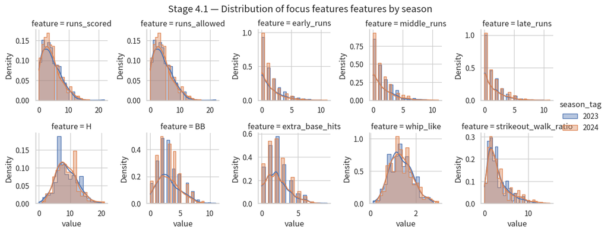

```python
df_long = team_game[FOCUS_FEATURES + ["season_tag"]].melt(
    id_vars="season_tag", var_name="feature", value_name="value")
g = sns.FacetGrid(df_long, col="feature", col_wrap=5, sharex=False, sharey=False,
                  height=2.4, hue="season_tag")
g.map(sns.histplot, "value", kde=True, stat="density", element="step", alpha=0.4)
g.add_legend()
g.fig.suptitle("Stage 4.1 — Distribution of focus features features by season", y=1.03)
show_and_track(g.fig, "stage4_small_multiples_top10.png")
plt.show()
```

**結果解讀**

- **看到了什麼**
  - 2×5 grid，10 個 FOCUS_FEATURES 各一張 histogram + KDE，分 2023/2024 兩條 KDE。
- **解讀**
  - 雙峰（bimodal）KDE 代表自然存在兩種子群——若出現在 `innings_pitched` 上，可能是「先發完投 vs 接力短局」的兩種比賽型態。
  - 兩條 KDE 形狀差很多代表 meta shift，這個結論在 5.19 應該會被 cluster frequency shift 所驗證。
  - Histogram 的長尾若超出 KDE 的右側很遠，代表那是 outlier 場次，記得在 cluster 解讀時排除或單獨看。

### 4.2 — Spearman 相關係數熱圖

- **程式碼目標**：檢查數值特徵之間是否高度重複。
- **執行方式**：計算 Spearman correlation，並遮住上三角避免重複閱讀。
- **產出與解讀**：顏色越接近正負 1，代表兩欄位排序關係越接近。高度相關的欄位可能在 Stage 5 被 redundancy pruning 移除。
- **與後續步驟的關聯**：避免 PCA 與分群被重複資訊支配。

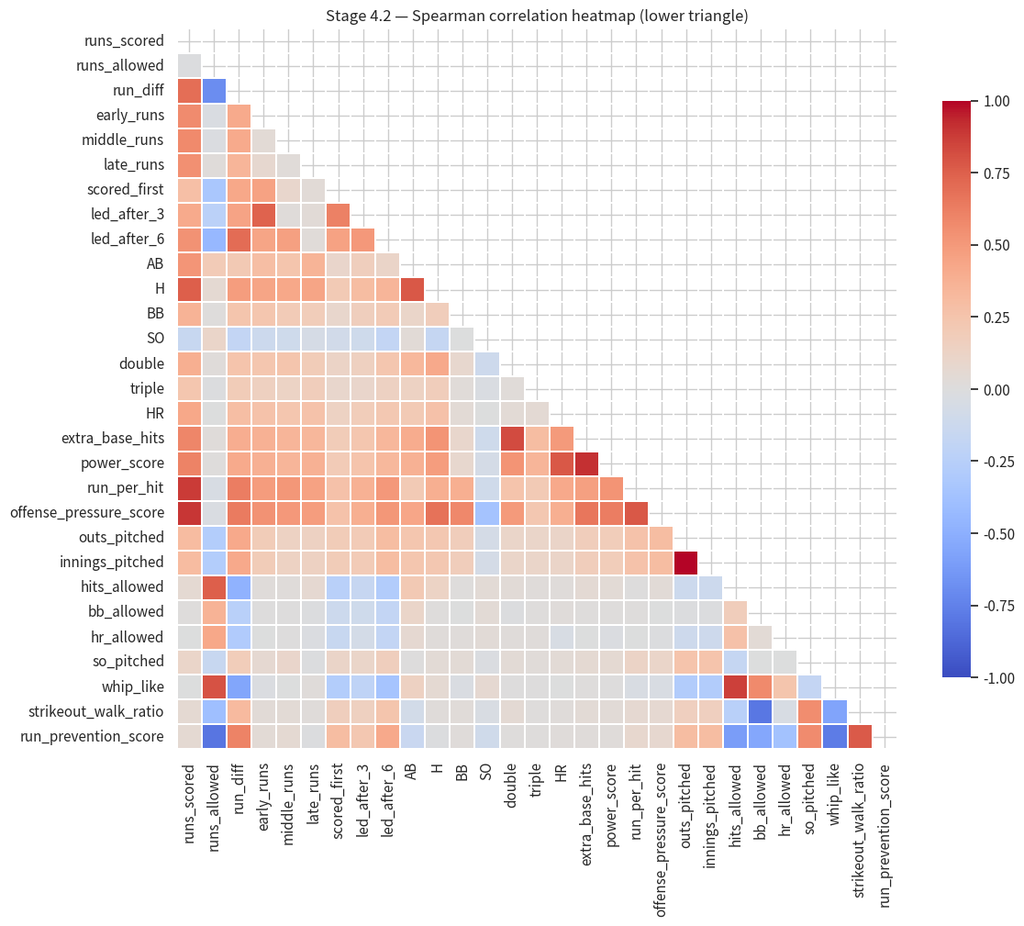

```python
corr_mat = team_game[NUMERIC_FEATURES].corr(method="spearman")
mask = np.triu(np.ones_like(corr_mat, dtype=bool))
fig, ax = plt.subplots(figsize=(12, 10))
sns.heatmap(corr_mat, mask=mask, cmap="coolwarm", center=0, vmin=-1, vmax=1,
            square=True, linewidths=.3, cbar_kws={"shrink": .8}, ax=ax)
ax.set_title("Stage 4.2 — Spearman correlation heatmap (lower triangle)")
plt.tight_layout()
show_and_track(fig, "stage4_spearman_heatmap.png")
plt.show()
```

**結果解讀**

### 4.3 — top-5 特徵 pairplot

- **程式碼目標**：觀察與 `win` 關聯最高的前 5 個特徵在二維空間是否能分開勝敗。
- **執行方式**：從 `corr_win` 取 top-5，對樣本做 pairplot，並以勝敗上色。
- **產出與解讀**：若勝敗點雲有明顯分離，代表該特徵組對結果有解釋力；若大量重疊，代表單純散點不易分辨。
- **與後續步驟的關聯**：幫助理解 correlation 排名是否也有視覺上的可分性。

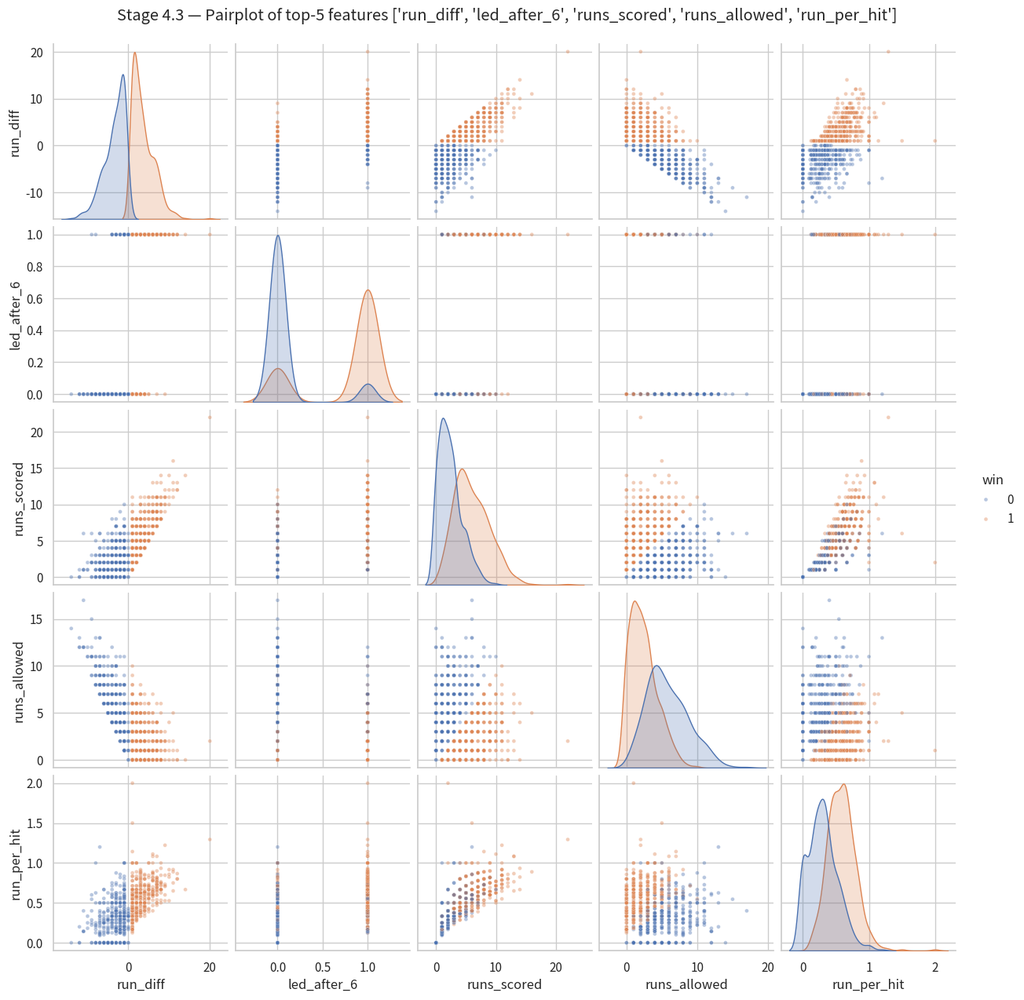

```python
top5 = corr_win.head(5)["feature"].tolist()
g = sns.pairplot(team_game[top5 + ["win"]].dropna().sample(min(800, len(team_game)),
                 random_state=RANDOM_STATE),
                 hue="win", diag_kind="kde", plot_kws={"alpha": .4, "s": 12})
g.fig.suptitle(f"Stage 4.3 — Pairplot of top-5 features {top5}", y=1.02)
show_and_track(g.fig, "stage4_pairplot_top5.png")
plt.show()
```

**結果解讀**

- **看到了什麼**
  - top-5（|ρ| vs win）特徵的 pairplot，每個散點按 `win` 上色，對角線為 KDE。
- **解讀**
  - 若任何一個 2D 角落能看到 win=0 與 win=1 的明顯分離，代表那對 features 是線性可分的強 predictor 組合。
  - 對角線 KDE 若兩條（win=0 vs win=1）有明顯水平距離，代表單一 feature 就能切勝負；幾乎重合則表示這個 feature 必須搭配別的才有預測力。
  - 因為這裡用的是 post-game features，分離一定很乾淨；本圖主要是「直覺校準」——讓讀者看到資料的可分性，但不代表這些 feature 能用來做事前預測。

### 4.4 — 主客場平均差異

- **程式碼目標**：比較主場與客場在 focus features 上的平均差異。
- **執行方式**：以 `season_tag + is_home` groupby 後畫 grouped bar chart。
- **產出與解讀**：若主場平均得分效率、守成或節奏特徵偏高，可能提示主客場情境差異；若差異小，代表主客場本身不是主要訊號。
- **與後續步驟的關聯**：這是本研究自己的 EDA 檢查，不引用外部結論。

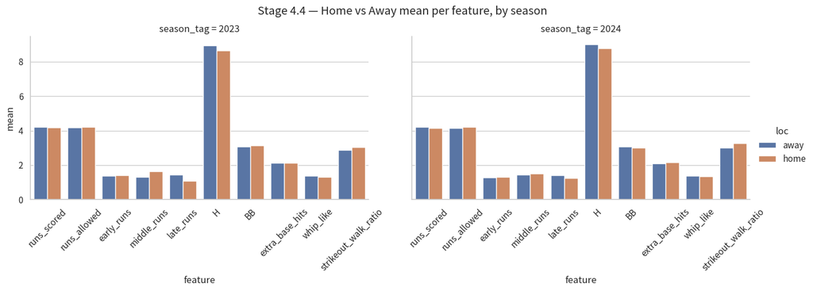

```python
ho = (team_game.groupby(["season_tag", "is_home"])[FOCUS_FEATURES]
      .mean().round(3).reset_index())
ho_long = ho.melt(id_vars=["season_tag", "is_home"], var_name="feature", value_name="mean")
ho_long["loc"] = ho_long["is_home"].map({True: "home", False: "away"})

g = sns.catplot(data=ho_long, x="feature", y="mean", hue="loc",
                col="season_tag", kind="bar", height=4, aspect=1.7)
for ax in g.axes.flat:
    ax.tick_params(axis='x', rotation=45)
g.fig.suptitle("Stage 4.4 — Home vs Away mean per feature, by season", y=1.04)
show_and_track(g.fig, "stage4_home_away_means.png")
plt.show()
```

**結果解讀**

- **看到了什麼**
  - FOCUS_FEATURES 的主客場 mean 對照 grouped bar，分 2023 / 2024 兩個 facet。
- **解讀**
  - Wang 學長在 2024 觀察到「主場勝率高 5.6pp 但平均分差幾乎 0」；本圖能直接看出此 pattern 是否在 2023 也成立。
  - 若 `whip_like` / `hits_allowed` 在主客之間差距大，可能反映「球場大小 / 觀眾干擾」對投手的影響，是 stadium-specific 效應的線索。
  - 若所有 features 的主客差距都很小（bar 高度幾乎平），代表 home advantage 在本資料中不顯著，cluster 階段不需要把 is_home 當主軸。

### 4.5 — 每月特徵趨勢

- **程式碼目標**：檢查 top-10 特徵是否隨月份變化。
- **執行方式**：以 month 與 season groupby 後畫每月平均折線。
- **產出與解讀**：若某些月份特徵突然上升或下降，可能代表賽季節奏、球員狀態或樣本組成改變。
- **與後續步驟的關聯**：避免後續 cluster 被時間趨勢誤解成固定球隊風格。

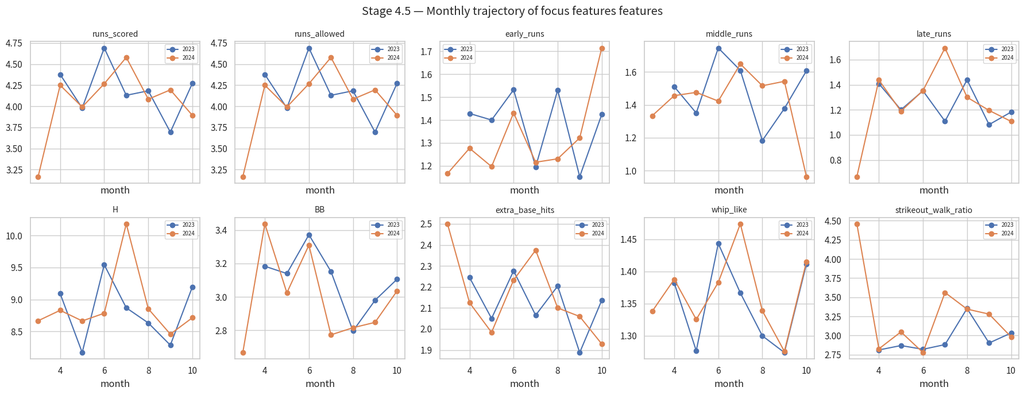

```python
monthly = team_game.groupby(["month", "season_tag"])[FOCUS_FEATURES].mean().reset_index()
fig, axes = plt.subplots(2, 5, figsize=(18, 7), sharex=True)
for ax, feat in zip(axes.flat, FOCUS_FEATURES):
    for season, sub in monthly.groupby("season_tag"):
        ax.plot(sub["month"], sub[feat], marker="o", label=season)
    ax.set_title(feat, fontsize=10)
    ax.set_xlabel("month")
    ax.legend(loc="best", fontsize=7)
fig.suptitle("Stage 4.5 — Monthly trajectory of focus features features")
plt.tight_layout()
show_and_track(fig, "stage4_monthly_trajectory.png")
plt.show()
```

**結果解讀**

### 4.6 — ECDF 分布檢查

- **程式碼目標**：用累積分布檢查長尾特徵，不依賴 histogram binning。
- **執行方式**：對 top-10 每個特徵畫 empirical CDF，並比較 2023/2024。
- **產出與解讀**：曲線越往右，代表該球季在該特徵值通常較高；曲線形狀差異可看出分布位移。
- **與後續步驟的關聯**：對長尾欄位比平均數更穩健，也支援 RobustScaler 選擇。

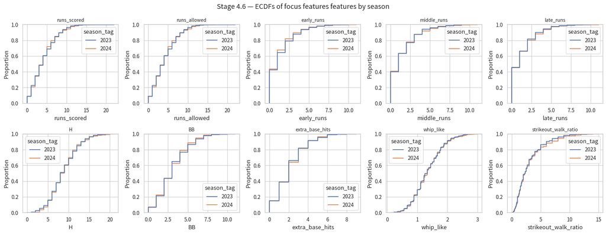

```python
fig, axes = plt.subplots(2, 5, figsize=(18, 7))
for ax, feat in zip(axes.flat, FOCUS_FEATURES):
    sns.ecdfplot(data=team_game, x=feat, hue="season_tag", ax=ax)
    ax.set_title(feat, fontsize=10)
fig.suptitle("Stage 4.6 — ECDFs of focus features features by season")
plt.tight_layout()
show_and_track(fig, "stage4_ecdf_top10.png")
plt.show()
```

**結果解讀**

- **看到了什麼**
  - 2×5 grid，10 個 features 的 ECDF（empirical CDF），按 season 上色。
- **解讀**
  - ECDF 沒有 binning artefact，是觀察長尾與百分位數的最乾淨方式——histogram 看到「peak」未必準，ECDF 的「轉折」才是。
  - 兩條 ECDF 平行偏移（同形狀、不同高度）代表 location shift（mean 變）；交叉則代表 scale 或 shape 改變了。
  - 在 0.95 分位線附近若兩條曲線分得開，代表「極端值區域」的兩季差異大，後續 cluster 解讀時要特別處理 outlier。

### 4.7 — 球場與週次熱圖

- **程式碼目標**：確認各球場在不同週次的主場比賽量。
- **執行方式**：只取主場列，依 stadium、season、ISO week 計數後畫 heatmap。
- **產出與解讀**：顏色越深代表該週在該球場比賽越多；可看出賽程集中或球場使用差異。
- **與後續步驟的關聯**：這是 context feature 的背景檢查，避免把賽程密度誤解為球隊表現。

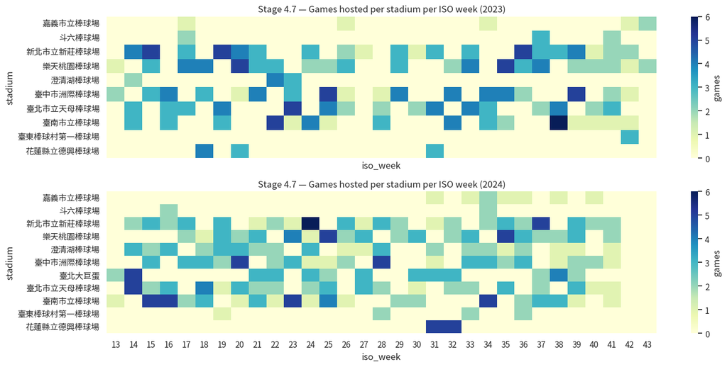

```python
tmp = team_game[team_game["is_home"]].copy()
tmp["iso_week"] = tmp["date"].dt.isocalendar().week.astype(int)
pivot = (tmp.groupby(["stadium", "season_tag", "iso_week"]).size()
            .unstack(fill_value=0))
fig, axes = plt.subplots(2, 1, figsize=(15, 7), sharex=True)
for ax, season in zip(axes, ["2023", "2024"]):
    sub = pivot.xs(season, level="season_tag", drop_level=True) if season in pivot.index.get_level_values(1) else pd.DataFrame()
    if not sub.empty:
        sns.heatmap(sub, cmap="YlGnBu", ax=ax, cbar_kws={"label": "games"})
        ax.set_title(f"Stage 4.7 — Games hosted per stadium per ISO week ({season})")
        ax.set_ylabel("stadium")
plt.tight_layout()
show_and_track(fig, "stage4_calendar_heatmap.png")
plt.show()
```

**結果解讀**

- **看到了什麼**
  - 球場 × ISO week 的場次熱圖，2023 與 2024 各一層。
- **解讀**
  - 熱圖的空白週通常對應 All-Star break、postseason 切換或天氣取消——這些 gap 在 4.5 的月度趨勢線會表現為斷點。
  - 若某個球場在某連續週次內熱度極高，代表球隊主場連戰，可能與 4.4 的主場優勢觀察結合解讀（主場連戰是否導致客隊疲勞）。
  - 兩季的整體 layout 應該大致一致——若 2024 大幅不同，代表 CPBL 改了賽程結構，可能間接影響球隊的休息天數與後續表現。

### 4.8 — 球隊勝率與主客場拆解

- **程式碼目標**：比較各隊整體勝率、主場勝率與客場勝率。
- **執行方式**：用 team + is_home groupby 計算 `win` 平均，再依整體勝率排序。
- **產出與解讀**：長條越高代表勝率越高；主客場差距可提示主場效果是否集中在特定球隊。
- **與後續步驟的關聯**：支援後續分群解讀時辨識 cluster 是否只是強隊/弱隊分層。

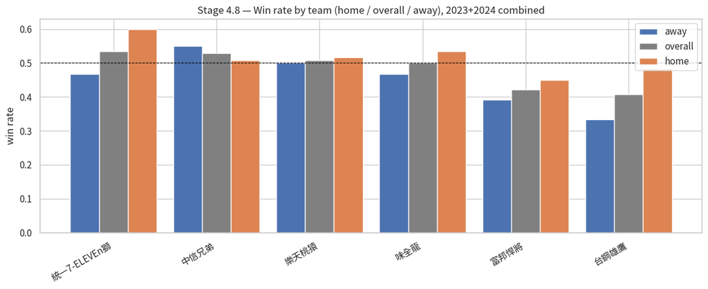

| is_home team | away | home | overall |
| --- | --- | --- | --- |
| 統一7-ELEVEn獅 | 0.467 | 0.600 | 0.533 |
| 中信兄弟 | 0.550 | 0.508 | 0.529 |
| 樂天桃猿 | 0.500 | 0.517 | 0.508 |
| 味全龍 | 0.467 | 0.533 | 0.500 |
| 富邦悍將 | 0.392 | 0.450 | 0.421 |
| 台鋼雄鷹 | 0.333 | 0.483 | 0.408 |

```python
wr = team_game.groupby(["team", "is_home"])["win"].mean().unstack().rename(
    columns={False: "away", True: "home"})
wr["overall"] = team_game.groupby("team")["win"].mean()
wr = wr.sort_values("overall", ascending=False)

fig, ax = plt.subplots(figsize=(12, 5))
x = np.arange(len(wr))
w = 0.28
ax.bar(x - w, wr["away"], width=w, label="away")
ax.bar(x, wr["overall"], width=w, label="overall", color="grey")
ax.bar(x + w, wr["home"], width=w, label="home")
ax.set_xticks(x)
ax.set_xticklabels(wr.index, rotation=30, ha="right")
ax.axhline(0.5, color="black", linestyle="--", linewidth=0.8)
ax.set_ylabel("win rate")
ax.set_title("Stage 4.8 — Win rate by team (home / overall / away), 2023+2024 combined")
ax.legend()
plt.tight_layout()
show_and_track(fig, "stage4_win_rate_by_team.png")
plt.show()
display(wr.round(3))
```

### 4.9 — 安打數與分差 hexbin

- **程式碼目標**：觀察安打量與分差之間的密度關係。
- **執行方式**：分球季畫 H vs run_diff 的 hexbin density plot。
- **產出與解讀**：格子越亮代表樣本越集中；若 H 高但分差不一定高，代表安打轉換效率比單純安打量更值得檢查。
- **與後續步驟的關聯**：這會連到後續 `run_per_hit` 與進攻效率特徵的解讀。

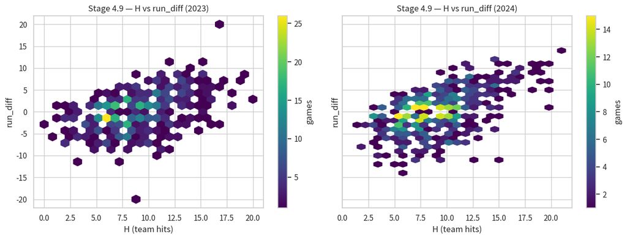

```python
fig, axes = plt.subplots(1, 2, figsize=(13, 5), sharey=True)
for ax, season in zip(axes, ["2023", "2024"]):
    sub = team_game[team_game["season_tag"] == season]
    hb = ax.hexbin(sub["H"], sub["run_diff"], gridsize=25, cmap="viridis", mincnt=1)
    ax.set_xlabel("H (team hits)"); ax.set_ylabel("run_diff")
    ax.set_title(f"Stage 4.9 — H vs run_diff ({season})")
    fig.colorbar(hb, ax=ax, label="games")
plt.tight_layout()
show_and_track(fig, "stage4_hexbin_H_run_diff.png")
plt.show()
```

**結果解讀**

- **看到了什麼**
  - H（球隊安打數）與 run_diff 的 hexbin 密度圖，分 2023 / 2024 兩面板。
- **解讀**
  - 右上角熱點（高 H、高 run_diff）對應「攻擊主導大勝」；左上角（低 H、高 run_diff）對應「投手戰小勝」（依賴對手失誤、HR 一發逆轉）。
  - 整體分布呈正相關但有相當散點是 baseball 的常識：打到不見得贏，贏不見得靠打。Hexbin 的好處是不被個別 outlier 拉走眼神。
  - 兩季熱點若中心不同（例如 2024 整體往右上移），代表得分環境變熱、勝負分差也加大。

### 4.10 — top-3 特徵的球隊分布

- **程式碼目標**：比較各隊在 top-3 關聯特徵上的分布差異。
- **執行方式**：依球隊畫 violin plot，並顯示四分位數。
- **產出與解讀**：小提琴越寬代表該值區間出現越多；隊間分布差異可視為風格差異或樣本結構差異。
- **與後續步驟的關聯**：幫助後續 cluster 命名時避免只看平均值。

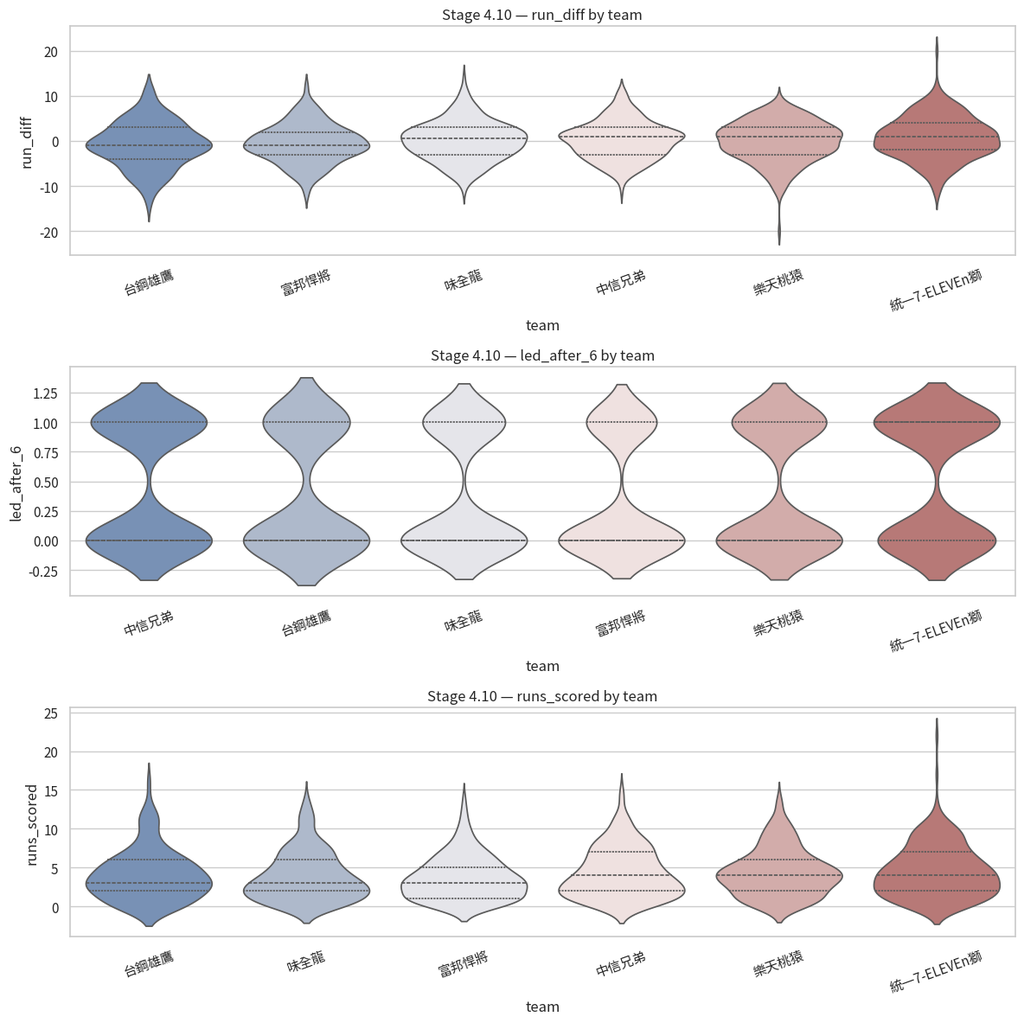

```python
top3 = corr_win.head(3)["feature"].tolist()
fig, axes = plt.subplots(len(top3), 1, figsize=(12, 4 * len(top3)))
for ax, feat in zip(axes, top3):
    order = team_game.groupby("team")[feat].median().sort_values().index
    sns.violinplot(data=team_game, x="team", y=feat, order=order,
                   inner="quartile", ax=ax, palette="vlag")
    ax.set_title(f"Stage 4.10 — {feat} by team")
    ax.tick_params(axis='x', rotation=20)
plt.tight_layout()
show_and_track(fig, "stage4_violin_per_team.png")
plt.show()
```

**結果解讀**

- **看到了什麼**
  - top-3（|ρ| vs win）特徵的 per-team violin grid。
- **解讀**
  - 球隊的 violin 寬度反映「該隊在這個指標的執行穩定度」——窄而高表示風格固定，寬而矮表示同隊內存在多種比賽型態。
  - 若中位數位置在某隊明顯偏離（例如 `whip_like` 中位數遠高於其他隊），那是該隊投手線的結構性弱點。
  - 後續 Stage 5 的 cluster 應該能把這種「球隊風格差異」自動切出來——本圖是事前觀察、後驗對照的基準。

## Stage 5 — 非監督式特徵發現

這一階段不使用 supervised target 來訓練勝負模型，而是從 feature matrix 自己找結構。流程是：先移除低變異與高度冗餘欄位，再標準化，接著用 PCA 把高維特徵轉成少數軸，最後比較多種分群方法，產生可被後續模型使用的 derived features。

### 5.1 — 低變異與高相關特徵篩選

- **程式碼目標**：移除幾乎沒有資訊量或與其他欄位高度重複的特徵。
- **執行方式**：先用 z-score variance 找 near-zero variance，再用 |Spearman rho| >= 0.95 移除冗餘欄位。
- **產出與解讀**：輸出 pruning log 與 `KEPT` 清單。被移除不代表沒用，而是對非監督結構來說資訊太重複或太少。
- **與後續步驟的關聯**：`KEPT` 是後面 scaler、PCA 與分群的輸入欄位。

```python
def filter_prune(df, cols, rho_thresh=0.95):
    X = df[cols].astype(float).copy()
    # 1. Variance threshold on z-scored values (so 'variance ≈ 0' is scale-invariant)
    z = (X - X.mean()) / X.std(ddof=0).replace(0, np.nan)
    keep = z.var().fillna(0)
    near_zero = keep[keep < 0.01].index.tolist()
    surviving = [c for c in cols if c not in near_zero]

    # 2. Pairwise |Spearman| pruning
    rho = X[surviving].corr(method="spearman").abs()
    drop = set()
    for i, a in enumerate(rho.columns):
        if a in drop: continue
        for b in rho.columns[i+1:]:
            if b in drop: continue
            if rho.loc[a, b] >= rho_thresh:
                # Keep the one with shorter name (cosmetic; usually the simpler concept)
                victim = b if len(b) >= len(a) else a
                keeper = a if victim == b else b
                drop.add(victim)
    surviving = [c for c in surviving if c not in drop]
    return surviving, near_zero, sorted(drop)

KEPT, NZ_DROP, RHO_DROP = filter_prune(team_game, FEATURES_FOR_UNSUP)

report = pd.DataFrame({
    "stage": ["start"] + ["near-zero variance"] * len(NZ_DROP) +
             ["|ρ|≥0.95 redundancy"] * len(RHO_DROP) + ["surviving"],
    "feature": [f"({len(NUMERIC_FEATURES)} features)"] +
               NZ_DROP + RHO_DROP +
               [f"({len(KEPT)} features)"],
})
show_and_track(report, "stage5_filter_prune_log.csv", "table")
display(report)
print(f"\nKept features ({len(KEPT)}): {KEPT}")
```

|  | stage | feature |
| --- | --- | --- |
| 0 | start | (29 features) |
| 1 | surviving | (55 features) |

```
Kept features (55): ['is_home', 'prior_runs_scored_mean_5', 'prior_runs_scored_mean_10', 'prior_runs_allowed_mean_5', 'prior_runs_allowed_mean_10', 'prior_run_diff_mean_5', 'prior_run_diff_mean_10', 'prior_win_rate_5', 'prior_win_rate_10', 'prior_scored_first_rate_5', 'prior_scored_first_rate_10', '…
```

**結果解讀**

### 5.2 — 依分布型態標準化

- **程式碼目標**：讓不同尺度的特徵能公平進入 PCA 與距離式分群。
- **執行方式**：長尾欄位用 RobustScaler，其餘欄位用 StandardScaler；缺失值以 median 補。
- **產出與解讀**：輸出 `X_scaled` 描述統計。標準化後的欄位尺度應更可比較。
- **與後續步驟的關聯**：PCA、K-Means、Ward、GMM 都會使用這個 matrix。

```python
from sklearn.compose import ColumnTransformer
from sklearn.pipeline import Pipeline
from sklearn.impute import SimpleImputer

HT_kept = [c for c in HEAVY_TAIL_GATE if c in KEPT]
SYM_kept = [c for c in KEPT if c not in HT_kept]

scaler = ColumnTransformer(
    transformers=[
        ("robust", Pipeline([("imp", SimpleImputer(strategy="median")),
                             ("sc", RobustScaler())]), HT_kept),
        ("std",    Pipeline([("imp", SimpleImputer(strategy="median")),
                             ("sc", StandardScaler())]), SYM_kept),
    ],
    remainder="drop",
)
X_scaled = scaler.fit_transform(team_game[KEPT])
X_scaled = pd.DataFrame(X_scaled, columns=HT_kept + SYM_kept, index=team_game.index)
print(f"X_scaled shape: {X_scaled.shape}")
desc_scaled = X_scaled.describe().T.round(3)
show_and_track(desc_scaled, "stage5_scaled_describe.csv", "table")
display(desc_scaled)
```

```
X_scaled shape: (1320, 55)
```

|  | count | mean | std | min | 25% | 50% | 75% | max |
| --- | --- | --- | --- | --- | --- | --- | --- | --- |
| prior_whip_like_mean_5 | 1320.0 | 0.020 | 0.749 | -2.283 | -0.519 | 0.000 | 0.481 | 2.387 |
| prior_whip_like_mean_10 | 1320.0 | 0.029 | 0.785 | -1.994 | -0.487 | 0.000 | 0.513 | 2.845 |
| prior_strikeout_walk_ratio_mean_5 | 1320.0 | 0.112 | 0.735 | -1.429 | -0.436 | 0.000 | 0.564 | 2.919 |
| prior_strikeout_walk_ratio_mean_10 | 1320.0 | 0.101 | 0.731 | -1.960 | -0.435 | 0.000 | 0.565 | 3.789 |
| prior_run_per_hit_mean_5 | 1320.0 | 0.020 | 0.712 | -2.341 | -0.484 | 0.000 | 0.516 | 2.399 |
| prior_run_per_hit_mean_10 | 1320.0 | -0.001 | 0.738 | -3.456 | -0.490 | 0.000 | 0.510 | 2.254 |
| stadium_prior_run_mean | 1320.0 | 0.136 | 0.861 | -3.779 | -0.356 | 0.000 | 0.644 | 5.113 |
| opp_prior_whip_like_mean_5 | 1320.0 | 0.020 | 0.749 | -2.283 | -0.519 | 0.000 | 0.481 | 2.387 |
| opp_prior_whip_like_mean_10 | 1320.0 | 0.029 | 0.785 | -1.994 | -0.487 | 0.000 | 0.513 | 2.845 |
| opp_prior_strikeout_walk_ratio_mean_5 | 1320.0 | 0.112 | 0.735 | -1.429 | -0.436 | 0.000 | 0.564 | 2.919 |
| opp_prior_strikeout_walk_ratio_mean_10 | 1320.0 | 0.101 | 0.731 | -1.960 | -0.435 | 0.000 | 0.565 | 3.789 |
| opp_prior_run_per_hit_mean_5 | 1320.0 | 0.020 | 0.712 | -2.341 | -0.484 | 0.000 | 0.516 | 2.399 |
| opp_prior_run_per_hit_mean_10 | 1320.0 | -0.001 | 0.738 | -3.456 | -0.490 | 0.000 | 0.510 | 2.254 |
| is_home | 1320.0 | 0.000 | 1.000 | -1.000 | -1.000 | 0.000 | 1.000 | 1.000 |
| prior_runs_scored_mean_5 | 1320.0 | -0.000 | 1.000 | -2.640 | -0.707 | -0.134 | 0.726 | 4.163 |
| prior_runs_scored_mean_10 | 1320.0 | -0.000 | 1.000 | -3.521 | -0.751 | -0.082 | 0.682 | 3.166 |
| prior_runs_allowed_mean_5 | 1320.0 | 0.000 | 1.000 | -2.421 | -0.752 | 0.007 | 0.614 | 4.710 |
| prior_runs_allowed_mean_10 | 1320.0 | -0.000 | 1.000 | -2.367 | -0.744 | -0.095 | 0.554 | 3.583 |
| prior_run_diff_mean_5 | 1320.0 | 0.000 | 1.000 | -2.815 | -0.625 | 0.001 | 0.627 | 3.443 |
| prior_run_diff_mean_10 | 1320.0 | -0.000 | 1.000 | -2.948 | -0.646 | 0.002 | 0.649 | 3.239 |
| prior_win_rate_5 | 1320.0 | 0.000 | 1.000 | -2.218 | -0.403 | -0.403 | 0.505 | 2.321 |
| prior_win_rate_10 | 1320.0 | -0.000 | 1.000 | -3.324 | -0.609 | 0.070 | 0.749 | 2.785 |
| prior_scored_first_rate_5 | 1320.0 | -0.000 | 1.000 | -2.042 | -1.117 | -0.193 | 0.732 | 2.581 |
| prior_scored_first_rate_10 | 1320.0 | 0.000 | 1.000 | -2.886 | -0.924 | -0.270 | 0.852 | 2.347 |
| prior_H_mean_5 | 1320.0 | 0.000 | 1.000 | -3.185 | -0.792 | -0.036 | 0.719 | 3.364 |
| prior_H_mean_10 | 1320.0 | 0.000 | 1.000 | -2.678 | -0.788 | -0.049 | 0.690 | 3.073 |
| prior_BB_mean_5 | 1320.0 | -0.000 | 1.000 | -2.839 | -0.733 | -0.068 | 0.598 | 2.815 |
| prior_BB_mean_10 | 1320.0 | 0.000 | 1.000 | -3.722 | -0.673 | -0.020 | 0.634 | 3.537 |
| prior_extra_base_hits_mean_5 | 1320.0 | -0.000 | 1.000 | -2.684 | -0.737 | -0.181 | 0.653 | 4.268 |
| prior_extra_base_hits_mean_10 | 1320.0 | 0.000 | 1.000 | -3.024 | -0.607 | -0.049 | 0.695 | 3.483 |
| prior_late_runs_mean_5 | 1320.0 | -0.000 | 1.000 | -1.723 | -0.666 | -0.137 | 0.656 | 3.563 |
| prior_late_runs_mean_10 | 1320.0 | -0.000 | 1.000 | -2.336 | -0.725 | -0.188 | 0.527 | 3.749 |
| days_rest | 1320.0 | 0.000 | 1.000 | -0.194 | -0.194 | -0.091 | 0.012 | 16.349 |
| day_of_week | 1320.0 | 0.000 | 1.000 | -1.930 | -0.846 | 0.238 | 0.780 | 1.322 |
| season_to_date_win_rate | 1320.0 | 0.000 | 1.000 | -4.979 | -0.490 | 0.045 | 0.483 | 5.195 |
| season_to_date_run_diff_mean | 1320.0 | -0.000 | 1.000 | -7.973 | -0.489 | -0.103 | 0.532 | 7.992 |
| h2h_prior_win_rate | 1320.0 | 0.000 | 1.000 | -3.151 | -0.549 | -0.019 | 0.602 | 3.354 |
| opp_prior_runs_scored_mean_5 | 1320.0 | -0.000 | 1.000 | -2.640 | -0.707 | -0.134 | 0.726 | 4.163 |
| opp_prior_runs_scored_mean_10 | 1320.0 | -0.000 | 1.000 | -3.521 | -0.751 | -0.082 | 0.682 | 3.166 |
| opp_prior_runs_allowed_mean_5 | 1320.0 | 0.000 | 1.000 | -2.421 | -0.752 | 0.007 | 0.614 | 4.710 |
| opp_prior_runs_allowed_mean_10 | 1320.0 | -0.000 | 1.000 | -2.367 | -0.744 | -0.095 | 0.554 | 3.583 |
| opp_prior_run_diff_mean_5 | 1320.0 | -0.000 | 1.000 | -2.815 | -0.625 | 0.001 | 0.627 | 3.443 |
| opp_prior_run_diff_mean_10 | 1320.0 | -0.000 | 1.000 | -2.948 | -0.646 | 0.002 | 0.649 | 3.239 |
| opp_prior_win_rate_5 | 1320.0 | 0.000 | 1.000 | -2.218 | -0.403 | -0.403 | 0.505 | 2.321 |
| opp_prior_win_rate_10 | 1320.0 | 0.000 | 1.000 | -3.324 | -0.609 | 0.070 | 0.749 | 2.785 |
| opp_prior_scored_first_rate_5 | 1320.0 | 0.000 | 1.000 | -2.042 | -1.117 | -0.193 | 0.732 | 2.581 |
| opp_prior_scored_first_rate_10 | 1320.0 | 0.000 | 1.000 | -2.886 | -0.924 | -0.270 | 0.852 | 2.347 |
| opp_prior_H_mean_5 | 1320.0 | 0.000 | 1.000 | -3.185 | -0.792 | -0.036 | 0.719 | 3.364 |
| opp_prior_H_mean_10 | 1320.0 | 0.000 | 1.000 | -2.678 | -0.788 | -0.049 | 0.690 | 3.073 |
| opp_prior_BB_mean_5 | 1320.0 | -0.000 | 1.000 | -2.839 | -0.733 | -0.068 | 0.598 | 2.815 |
| opp_prior_BB_mean_10 | 1320.0 | 0.000 | 1.000 | -3.722 | -0.673 | -0.020 | 0.634 | 3.537 |
| opp_prior_extra_base_hits_mean_5 | 1320.0 | 0.000 | 1.000 | -2.684 | -0.737 | -0.181 | 0.653 | 4.268 |
| opp_prior_extra_base_hits_mean_10 | 1320.0 | 0.000 | 1.000 | -3.024 | -0.607 | -0.049 | 0.695 | 3.483 |
| opp_prior_late_runs_mean_5 | 1320.0 | -0.000 | 1.000 | -1.723 | -0.666 | -0.137 | 0.656 | 3.563 |
| opp_prior_late_runs_mean_10 | 1320.0 | -0.000 | 1.000 | -2.336 | -0.725 | -0.188 | 0.527 | 3.749 |

**結果解讀**

- **看到了什麼**
  - `X_scaled` 的最終形狀，與 describe（mean / std / median）。
- **解讀**
  - StandardScaler 組合的欄位應該 mean ≈ 0、std ≈ 1；RobustScaler 組合的應該 median ≈ 0、IQR ≈ 1。
  - 若某欄位的 scaled 分布很歪（mean 偏離 0 很多），代表 SimpleImputer 把太多 NaN 補成中位數造成 over-compression——回頭比對 `pre_game_ready=0` 的列比例。
  - X_scaled 是後續所有 PCA / clustering / SHAP 的共同輸入，這一步若失誤後面全錯，是「合格率最關鍵」的一步。

### 5.3 — PCA scree 與累積解釋變異

- **程式碼目標**：找出需要多少主成分才能保留主要資訊。
- **執行方式**：fit PCA 後畫每個 PC 的 PVE 與 cumulative PVE，並取達到 90% 的 `K_PCA`。
- **產出與解讀**：scree plot 可看資訊是否集中在前幾個 PC；`K_PCA` 越小代表原始特徵可被較少維度摘要。
- **與後續步驟的關聯**：`X_pca` 是後續分群的主要輸入。

```
達到 90% 累積解釋變異需要的 PC 數： 24  (cumulative PVE: 0.906)
```

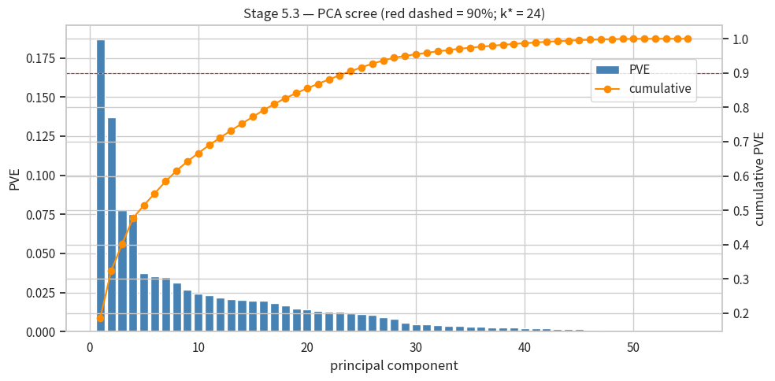

```python
pca_full = PCA(n_components=None, random_state=RANDOM_STATE)
pca_full.fit(X_scaled)
pve = pca_full.explained_variance_ratio_
cum = np.cumsum(pve)
K_PCA = int(np.searchsorted(cum, 0.90) + 1)
print(f"達到 90% 累積解釋變異需要的 PC 數： {K_PCA}  (cumulative PVE: {cum[K_PCA-1]:.3f})")

fig, ax = plt.subplots(figsize=(10, 5))
xs = np.arange(1, len(pve) + 1)
ax.bar(xs, pve, color="steelblue", label="PVE")
ax2 = ax.twinx()
ax2.plot(xs, cum, color="darkorange", marker="o", label="cumulative")
ax2.axhline(0.9, color="red", linestyle="--", linewidth=0.8)
ax.set_xlabel("principal component"); ax.set_ylabel("PVE"); ax2.set_ylabel("cumulative PVE")
ax.set_title(f"Stage 5.3 — PCA scree (red dashed = 90%; k* = {K_PCA})")
fig.legend(loc="upper right", bbox_to_anchor=(0.9, 0.85))
plt.tight_layout()
show_and_track(fig, "stage5_pca_scree.png")
plt.show()

X_pca = PCA(n_components=K_PCA, random_state=RANDOM_STATE).fit_transform(X_scaled)
X_pca = pd.DataFrame(X_pca, columns=[f"PC{i+1}" for i in range(K_PCA)], index=team_game.index)
```

**結果解讀**

- **看到了什麼**
  - PCA scree（PVE bar + 累積線），紅虛線標 90% 門檻，K_PCA = 24。
- **解讀**
  - 需要 24 個 PC 才能解釋 90% 變異——比 post-game 模式（約 13）多很多，代表 pre-game lag features 之間的線性相關較低、結構更鬆散。
  - PVE 的 bar 若前 2-3 個明顯高、之後快速衰減，就有「dominant axes」——通常會對應到 offense / defense 兩大方向；若衰減平緩則代表特徵集合裡沒有清楚主軸。
  - 本步驟的 K_PCA 直接決定 5.5 loadings 表的欄數與 5.20 derived register 的 pc 欄位數。

### 5.4 — PCA biplot

- **程式碼目標**：同時查看樣本在 PC1/PC2 的位置與特徵 loading 方向。
- **執行方式**：畫 PC1-PC2 scatter，並用箭頭標示重要特徵在兩個主成分上的 loading。
- **產出與解讀**：箭頭越長代表該特徵越能解釋 PC1/PC2；點群分離可提示潛在情境群。
- **與後續步驟的關聯**：支援後面 cluster 命名與 focus features 交叉檢查。

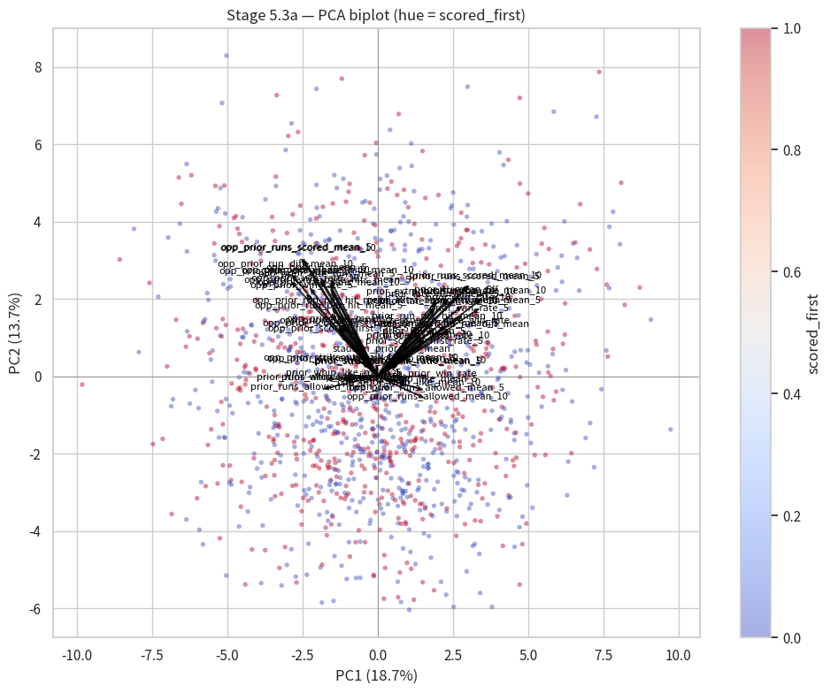

```python
pca2 = PCA(n_components=2, random_state=RANDOM_STATE).fit(X_scaled)
scores2 = pca2.transform(X_scaled)
loadings2 = pca2.components_.T * np.sqrt(pca2.explained_variance_)

fig, ax = plt.subplots(figsize=(10, 8))
hue = team_game.loc[X_scaled.index, "scored_first"].astype(int)
sc = ax.scatter(scores2[:, 0], scores2[:, 1], c=hue, cmap="coolwarm",
                alpha=0.45, s=15, edgecolor="none")
arrow_scale = 0.35 * max(abs(scores2[:, 0]).max(), abs(scores2[:, 1]).max()) / np.abs(loadings2).max()
for i, feat in enumerate(X_scaled.columns):
    dx, dy = loadings2[i] * arrow_scale
    ax.arrow(0, 0, dx, dy, color="black", alpha=0.8, head_width=0.1, length_includes_head=True)
    ax.text(dx * 1.08, dy * 1.08, feat, fontsize=8, ha="center",
            color="black", weight="bold")
ax.axhline(0, color="grey", lw=.5); ax.axvline(0, color="grey", lw=.5)
ax.set_xlabel(f"PC1 ({pca2.explained_variance_ratio_[0]:.1%})")
ax.set_ylabel(f"PC2 ({pca2.explained_variance_ratio_[1]:.1%})")
ax.set_title("Stage 5.3a — PCA biplot (hue = scored_first)")
plt.colorbar(sc, ax=ax, label="scored_first")
plt.tight_layout()
show_and_track(fig, "stage5_pca_biplot.png")
plt.show()
```

**結果解讀**

- **看到了什麼**
  - PC1-PC2 biplot：每個點是一場 team-game（按 `scored_first` 上色），黑色箭頭標 features 的 loadings 方向與長度。
- **解讀**
  - 箭頭同向的 features 在這個 2D 平面上是 synergistic（一起變高或一起變低）；反向的代表互斥（攻防對立）。
  - 點雲若按 `scored_first` 上色出現清楚的左右分群，代表「先得分」這個事件在 PC1-PC2 平面就能線性分割——很有可能與後續 cluster_id 對齊。
  - 箭頭長度反映該 feature 在前兩個 PC 上的解釋力；很短的箭頭代表它的信號落在更高的 PC 上，要看 5.5 的完整 loadings 表才能看到。

### 5.5 — PCA loading 表與熱圖

- **程式碼目標**：列出每個保留特徵對各主成分的貢獻大小。
- **執行方式**：以 PCA components 建立 absolute loading matrix，並畫 heatmap。
- **產出與解讀**：loading 高的 feature 是該 PC 的主要解釋來源；也會檢查 focus features 有多少出現在高 loading 中。
- **與後續步驟的關聯**：後續 overlap table 會整合 PCA loading 與 cluster SHAP。

|  | PC1 | PC2 | PC3 | PC4 | PC5 | PC6 | PC7 | PC8 | PC9 | PC10 | ... | PC15 | PC16 | PC17 | PC18 | PC19 | PC20 | PC21 | PC22 | PC23 | PC24 |
| --- | --- | --- | --- | --- | --- | --- | --- | --- | --- | --- | --- | --- | --- | --- | --- | --- | --- | --- | --- | --- | --- |
| prior_whip_like_mean_5 | 0.229 | 0.002 | 0.558 | 0.002 | 0.034 | 0.017 | 0.008 | 0.155 | 0.038 | 0.077 | ... | 0.050 | 0.009 | 0.144 | 0.024 | 0.021 | 0.018 | 0.038 | 0.028 | 0.150 | 0.052 |
| prior_whip_like_mean_10 | 0.241 | 0.021 | 0.574 | 0.024 | 0.101 | 0.013 | 0.017 | 0.013 | 0.053 | 0.119 | ... | 0.008 | 0.063 | 0.125 | 0.064 | 0.115 | 0.101 | 0.084 | 0.086 | 0.114 | 0.011 |
| prior_strikeout_walk_ratio_mean_5 | 0.137 | 0.064 | 0.308 | 0.045 | 0.058 | 0.102 | 0.073 | 0.053 | 0.076 | 0.062 | ... | 0.007 | 0.041 | 0.281 | 0.160 | 0.112 | 0.217 | 0.002 | 0.204 | 0.172 | 0.177 |
| prior_strikeout_walk_ratio_mean_10 | 0.147 | 0.069 | 0.290 | 0.029 | 0.141 | 0.071 | 0.036 | 0.114 | 0.092 | 0.069 | ... | 0.008 | 0.004 | 0.258 | 0.170 | 0.167 | 0.248 | 0.057 | 0.185 | 0.040 | 0.172 |
| prior_run_per_hit_mean_5 | 0.391 | 0.261 | 0.077 | 0.054 | 0.036 | 0.055 | 0.158 | 0.201 | 0.010 | 0.021 | ... | 0.019 | 0.063 | 0.106 | 0.106 | 0.104 | 0.111 | 0.046 | 0.021 | 0.011 | 0.120 |
| prior_run_per_hit_mean_10 | 0.400 | 0.297 | 0.107 | 0.080 | 0.065 | 0.009 | 0.155 | 0.009 | 0.002 | 0.133 | ... | 0.082 | 0.049 | 0.161 | 0.076 | 0.073 | 0.071 | 0.002 | 0.028 | 0.078 | 0.076 |
| stadium_prior_run_mean | 0.092 | 0.129 | 0.001 | 0.030 | 0.002 | 0.104 | 0.099 | 0.094 | 0.104 | 0.175 | ... | 0.036 | 0.033 | 0.045 | 0.067 | 0.247 | 0.023 | 0.300 | 0.285 | 0.244 | 0.223 |
| opp_prior_whip_like_mean_5 | 0.205 | 0.030 | 0.054 | 0.577 | 0.077 | 0.020 | 0.004 | 0.061 | 0.012 | 0.049 | ... | 0.012 | 0.069 | 0.120 | 0.085 | 0.034 | 0.018 | 0.021 | 0.044 | 0.120 | 0.083 |
| opp_prior_whip_like_mean_10 | 0.206 | 0.049 | 0.074 | 0.584 | 0.118 | 0.009 | 0.039 | 0.028 | 0.154 | 0.033 | ... | 0.020 | 0.001 | 0.128 | 0.017 | 0.028 | 0.149 | 0.051 | 0.065 | 0.130 | 0.010 |
| opp_prior_strikeout_walk_ratio_mean_5 | 0.106 | 0.077 | 0.018 | 0.316 | 0.062 | 0.037 | 0.126 | 0.035 | 0.131 | 0.007 | ... | 0.009 | 0.117 | 0.313 | 0.095 | 0.165 | 0.163 | 0.085 | 0.051 | 0.260 | 0.155 |
| opp_prior_strikeout_walk_ratio_mean_10 | 0.113 | 0.082 | 0.005 | 0.292 | 0.126 | 0.051 | 0.073 | 0.037 | 0.215 | 0.049 | ... | 0.029 | 0.109 | 0.300 | 0.132 | 0.160 | 0.207 | 0.065 | 0.110 | 0.142 | 0.177 |
| opp_prior_run_per_hit_mean_5 | 0.332 | 0.352 | 0.059 | 0.038 | 0.002 | 0.113 | 0.099 | 0.024 | 0.192 | 0.128 | ... | 0.072 | 0.027 | 0.137 | 0.031 | 0.012 | 0.157 | 0.120 | 0.001 | 0.013 | 0.139 |
| opp_prior_run_per_hit_mean_10 | 0.328 | 0.383 | 0.076 | 0.082 | 0.064 | 0.106 | 0.119 | 0.022 | 0.083 | 0.012 | ... | 0.063 | 0.170 | 0.177 | 0.007 | 0.004 | 0.103 | 0.088 | 0.026 | 0.054 | 0.083 |
| is_home | 0.003 | 0.004 | 0.037 | 0.040 | 0.001 | 0.025 | 0.021 | 0.022 | 0.190 | 0.414 | ... | 0.094 | 0.114 | 0.006 | 0.107 | 0.151 | 0.025 | 0.175 | 0.047 | 0.082 | 0.149 |
| prior_runs_scored_mean_5 | 0.661 | 0.507 | 0.314 | 0.070 | 0.096 | 0.047 | 0.061 | 0.189 | 0.016 | 0.105 | ... | 0.013 | 0.098 | 0.025 | 0.005 | 0.045 | 0.074 | 0.016 | 0.001 | 0.066 | 0.011 |
| prior_runs_scored_mean_10 | 0.653 | 0.512 | 0.357 | 0.127 | 0.057 | 0.037 | 0.028 | 0.126 | 0.000 | 0.098 | ... | 0.071 | 0.073 | 0.027 | 0.034 | 0.052 | 0.021 | 0.047 | 0.068 | 0.142 | 0.062 |
| prior_runs_allowed_mean_5 | 0.366 | 0.018 | 0.762 | 0.005 | 0.031 | 0.018 | 0.077 | 0.282 | 0.038 | 0.073 | ... | 0.053 | 0.047 | 0.005 | 0.015 | 0.133 | 0.199 | 0.078 | 0.066 | 0.155 | 0.115 |
| prior_runs_allowed_mean_10 | 0.388 | 0.070 | 0.775 | 0.021 | 0.065 | 0.085 | 0.077 | 0.047 | 0.046 | 0.152 | ... | 0.037 | 0.057 | 0.052 | 0.051 | 0.053 | 0.056 | 0.143 | 0.162 | 0.188 | 0.037 |
| prior_run_diff_mean_5 | 0.733 | 0.381 | 0.295 | 0.054 | 0.091 | 0.021 | 0.009 | 0.331 | 0.038 | 0.026 | ... | 0.046 | 0.103 | 0.022 | 0.014 | 0.058 | 0.083 | 0.042 | 0.045 | 0.058 | 0.087 |
| prior_run_diff_mean_10 | 0.750 | 0.432 | 0.247 | 0.110 | 0.086 | 0.084 | 0.030 | 0.063 | 0.030 | 0.175 | ... | 0.078 | 0.093 | 0.055 | 0.059 | 0.004 | 0.021 | 0.131 | 0.056 | 0.018 | 0.071 |
| prior_win_rate_5 | 0.610 | 0.339 | 0.293 | 0.036 | 0.133 | 0.013 | 0.070 | 0.308 | 0.024 | 0.081 | ... | 0.053 | 0.102 | 0.138 | 0.111 | 0.092 | 0.039 | 0.058 | 0.282 | 0.017 | 0.015 |
| prior_win_rate_10 | 0.605 | 0.394 | 0.284 | 0.060 | 0.024 | 0.122 | 0.126 | 0.094 | 0.004 | 0.119 | ... | 0.090 | 0.078 | 0.237 | 0.019 | 0.047 | 0.006 | 0.136 | 0.292 | 0.109 | 0.025 |
| prior_scored_first_rate_5 | 0.312 | 0.169 | 0.265 | 0.021 | 0.499 | 0.379 | 0.161 | 0.003 | 0.325 | 0.255 | ... | 0.156 | 0.093 | 0.050 | 0.098 | 0.004 | 0.055 | 0.125 | 0.020 | 0.050 | 0.037 |
| prior_scored_first_rate_10 | 0.336 | 0.199 | 0.251 | 0.013 | 0.401 | 0.281 | 0.182 | 0.171 | 0.374 | 0.173 | ... | 0.062 | 0.192 | 0.043 | 0.067 | 0.036 | 0.099 | 0.033 | 0.085 | 0.000 | 0.072 |
| prior_H_mean_5 | 0.506 | 0.436 | 0.390 | 0.051 | 0.131 | 0.006 | 0.120 | 0.011 | 0.000 | 0.201 | ... | 0.062 | 0.018 | 0.151 | 0.151 | 0.115 | 0.032 | 0.104 | 0.046 | 0.116 | 0.191 |
| prior_H_mean_10 | 0.508 | 0.427 | 0.439 | 0.082 | 0.027 | 0.057 | 0.153 | 0.215 | 0.042 | 0.066 | ... | 0.011 | 0.089 | 0.121 | 0.160 | 0.205 | 0.051 | 0.096 | 0.122 | 0.101 | 0.188 |
| prior_BB_mean_5 | 0.308 | 0.219 | 0.105 | 0.048 | 0.346 | 0.261 | 0.682 | 0.112 | 0.009 | 0.089 | ... | 0.067 | 0.147 | 0.023 | 0.066 | 0.051 | 0.020 | 0.042 | 0.000 | 0.031 | 0.018 |
| prior_BB_mean_10 | 0.333 | 0.204 | 0.124 | 0.073 | 0.388 | 0.236 | 0.677 | 0.014 | 0.026 | 0.051 | ... | 0.096 | 0.054 | 0.014 | 0.065 | 0.007 | 0.064 | 0.044 | 0.016 | 0.070 | 0.077 |
| prior_extra_base_hits_mean_5 | 0.414 | 0.382 | 0.317 | 0.028 | 0.315 | 0.037 | 0.212 | 0.225 | 0.102 | 0.043 | ... | 0.162 | 0.175 | 0.162 | 0.150 | 0.154 | 0.000 | 0.014 | 0.219 | 0.088 | 0.171 |
| prior_extra_base_hits_mean_10 | 0.424 | 0.430 | 0.390 | 0.064 | 0.229 | 0.051 | 0.237 | 0.058 | 0.105 | 0.175 | ... | 0.236 | 0.041 | 0.119 | 0.098 | 0.079 | 0.011 | 0.010 | 0.100 | 0.096 | 0.089 |
| prior_late_runs_mean_5 | 0.428 | 0.416 | 0.324 | 0.082 | 0.143 | 0.068 | 0.037 | 0.133 | 0.213 | 0.131 | ... | 0.368 | 0.086 | 0.009 | 0.249 | 0.103 | 0.005 | 0.086 | 0.114 | 0.117 | 0.164 |
| prior_late_runs_mean_10 | 0.409 | 0.379 | 0.355 | 0.123 | 0.192 | 0.091 | 0.097 | 0.090 | 0.178 | 0.256 | ... | 0.308 | 0.190 | 0.002 | 0.211 | 0.030 | 0.077 | 0.112 | 0.066 | 0.045 | 0.084 |
| days_rest | 0.009 | 0.063 | 0.033 | 0.039 | 0.008 | 0.025 | 0.097 | 0.021 | 0.015 | 0.029 | ... | 0.331 | 0.513 | 0.089 | 0.134 | 0.043 | 0.011 | 0.057 | 0.040 | 0.014 | 0.015 |
| day_of_week | 0.000 | 0.024 | 0.007 | 0.002 | 0.015 | 0.035 | 0.069 | 0.077 | 0.140 | 0.073 | ... | 0.420 | 0.358 | 0.016 | 0.037 | 0.048 | 0.038 | 0.068 | 0.078 | 0.014 | 0.033 |
| season_to_date_win_rate | 0.486 | 0.280 | 0.279 | 0.027 | 0.180 | 0.169 | 0.094 | 0.499 | 0.014 | 0.232 | ... | 0.071 | 0.082 | 0.070 | 0.052 | 0.122 | 0.014 | 0.216 | 0.002 | 0.063 | 0.153 |
| season_to_date_run_diff_mean | 0.521 | 0.256 | 0.263 | 0.051 | 0.246 | 0.143 | 0.009 | 0.470 | 0.008 | 0.210 | ... | 0.057 | 0.063 | 0.015 | 0.073 | 0.125 | 0.023 | 0.263 | 0.243 | 0.002 | 0.083 |
| h2h_prior_win_rate | 0.353 | 0.003 | 0.136 | 0.110 | 0.013 | 0.175 | 0.068 | 0.371 | 0.084 | 0.268 | ... | 0.044 | 0.083 | 0.143 | 0.350 | 0.427 | 0.130 | 0.339 | 0.058 | 0.099 | 0.159 |
| opp_prior_runs_scored_mean_5 | 0.550 | 0.660 | 0.059 | 0.255 | 0.063 | 0.047 | 0.022 | 0.040 | 0.209 | 0.129 | ... | 0.038 | 0.085 | 0.025 | 0.046 | 0.053 | 0.057 | 0.067 | 0.011 | 0.094 | 0.047 |
| opp_prior_runs_scored_mean_10 | 0.534 | 0.653 | 0.103 | 0.324 | 0.042 | 0.002 | 0.040 | 0.040 | 0.182 | 0.088 | ... | 0.033 | 0.112 | 0.017 | 0.039 | 0.085 | 0.061 | 0.049 | 0.055 | 0.100 | 0.025 |
| opp_prior_runs_allowed_mean_5 | 0.326 | 0.076 | 0.082 | 0.794 | 0.037 | 0.106 | 0.021 | 0.123 | 0.104 | 0.057 | ... | 0.022 | 0.084 | 0.026 | 0.123 | 0.075 | 0.178 | 0.094 | 0.130 | 0.100 | 0.138 |
| opp_prior_runs_allowed_mean_10 | 0.332 | 0.121 | 0.088 | 0.793 | 0.101 | 0.131 | 0.018 | 0.044 | 0.158 | 0.042 | ... | 0.005 | 0.051 | 0.034 | 0.040 | 0.058 | 0.020 | 0.120 | 0.028 | 0.250 | 0.002 |
| opp_prior_run_diff_mean_5 | 0.625 | 0.533 | 0.099 | 0.360 | 0.020 | 0.039 | 0.001 | 0.114 | 0.223 | 0.133 | ... | 0.043 | 0.119 | 0.000 | 0.051 | 0.013 | 0.081 | 0.016 | 0.098 | 0.000 | 0.060 |
| opp_prior_run_diff_mean_10 | 0.623 | 0.572 | 0.136 | 0.283 | 0.098 | 0.086 | 0.042 | 0.001 | 0.242 | 0.094 | ... | 0.022 | 0.118 | 0.036 | 0.056 | 0.026 | 0.033 | 0.043 | 0.023 | 0.091 | 0.020 |
| opp_prior_win_rate_5 | 0.515 | 0.460 | 0.074 | 0.348 | 0.056 | 0.099 | 0.021 | 0.090 | 0.269 | 0.186 | ... | 0.015 | 0.056 | 0.146 | 0.008 | 0.016 | 0.167 | 0.110 | 0.045 | 0.116 | 0.064 |
| opp_prior_win_rate_10 | 0.490 | 0.496 | 0.083 | 0.309 | 0.043 | 0.170 | 0.008 | 0.023 | 0.192 | 0.058 | ... | 0.015 | 0.183 | 0.197 | 0.138 | 0.062 | 0.150 | 0.077 | 0.114 | 0.008 | 0.110 |
| opp_prior_scored_first_rate_5 | 0.265 | 0.234 | 0.017 | 0.313 | 0.426 | 0.315 | 0.161 | 0.309 | 0.306 | 0.243 | ... | 0.132 | 0.054 | 0.083 | 0.153 | 0.016 | 0.085 | 0.008 | 0.010 | 0.074 | 0.026 |
| opp_prior_scored_first_rate_10 | 0.280 | 0.262 | 0.017 | 0.289 | 0.356 | 0.273 | 0.083 | 0.376 | 0.101 | 0.401 | ... | 0.120 | 0.072 | 0.059 | 0.106 | 0.007 | 0.136 | 0.011 | 0.047 | 0.031 | 0.004 |
| opp_prior_H_mean_5 | 0.414 | 0.553 | 0.028 | 0.351 | 0.122 | 0.078 | 0.110 | 0.007 | 0.105 | 0.010 | ... | 0.098 | 0.158 | 0.211 | 0.139 | 0.111 | 0.186 | 0.043 | 0.009 | 0.127 | 0.101 |
| opp_prior_H_mean_10 | 0.413 | 0.537 | 0.048 | 0.420 | 0.050 | 0.121 | 0.104 | 0.066 | 0.154 | 0.184 | ... | 0.080 | 0.026 | 0.172 | 0.101 | 0.155 | 0.267 | 0.020 | 0.031 | 0.084 | 0.130 |
| opp_prior_BB_mean_5 | 0.257 | 0.286 | 0.045 | 0.083 | 0.308 | 0.650 | 0.377 | 0.016 | 0.124 | 0.048 | ... | 0.094 | 0.034 | 0.038 | 0.101 | 0.009 | 0.004 | 0.020 | 0.025 | 0.045 | 0.004 |
| opp_prior_BB_mean_10 | 0.282 | 0.275 | 0.069 | 0.107 | 0.329 | 0.642 | 0.384 | 0.012 | 0.071 | 0.023 | ... | 0.070 | 0.051 | 0.003 | 0.081 | 0.021 | 0.048 | 0.063 | 0.037 | 0.047 | 0.091 |
| opp_prior_extra_base_hits_mean_5 | 0.339 | 0.490 | 0.020 | 0.261 | 0.248 | 0.151 | 0.186 | 0.004 | 0.286 | 0.104 | ... | 0.198 | 0.016 | 0.171 | 0.058 | 0.108 | 0.207 | 0.167 | 0.073 | 0.070 | 0.081 |
| opp_prior_extra_base_hits_mean_10 | 0.338 | 0.539 | 0.045 | 0.343 | 0.187 | 0.213 | 0.152 | 0.024 | 0.032 | 0.066 | ... | 0.217 | 0.192 | 0.124 | 0.017 | 0.076 | 0.109 | 0.128 | 0.040 | 0.113 | 0.002 |
| opp_prior_late_runs_mean_5 | 0.345 | 0.519 | 0.057 | 0.286 | 0.158 | 0.082 | 0.041 | 0.141 | 0.144 | 0.140 | ... | 0.239 | 0.266 | 0.084 | 0.308 | 0.189 | 0.179 | 0.029 | 0.081 | 0.076 | 0.070 |
| opp_prior_late_runs_mean_10 | 0.328 | 0.474 | 0.092 | 0.334 | 0.178 | 0.117 | 0.001 | 0.067 | 0.393 | 0.034 | ... | 0.226 | 0.148 | 0.092 | 0.319 | 0.195 | 0.070 | 0.060 | 0.013 | 0.079 | 0.013 |

55 rows × 24 columns

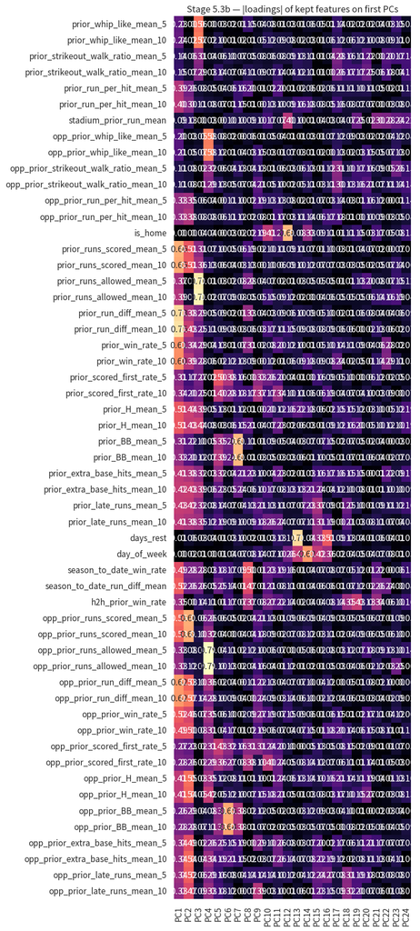

```
focus features in top |loadings| of PC1+PC2 only : 0/10 → []
focus features in top |loadings| across all 24 PCs: 0/10 → []
```

```python
pca_k = PCA(n_components=K_PCA, random_state=RANDOM_STATE).fit(X_scaled)
loadings_k = pd.DataFrame(
    (pca_k.components_.T * np.sqrt(pca_k.explained_variance_)),
    index=X_scaled.columns,
    columns=[f"PC{i+1}" for i in range(K_PCA)],
)
loadings_abs = loadings_k.abs().round(3)
show_and_track(loadings_abs, "stage5_pca_loadings_abs.csv", "table")
display(loadings_abs)

# Heatmap
fig, ax = plt.subplots(figsize=(8, max(6, 0.32 * len(loadings_abs))))
sns.heatmap(loadings_abs, cmap="magma", annot=True, fmt=".2f", ax=ax, cbar=False)
ax.set_title("Stage 5.3b — |loadings| of kept features on first PCs")
plt.tight_layout()
show_and_track(fig, "stage5_loadings_heatmap.png")
plt.show()

# Corroboration check: PC1+PC2 (strict) and across all kept PCs (relaxed)
top_loadings_12 = set(
    loadings_abs["PC1"].nlargest(8).index.tolist() +
    loadings_abs["PC2"].nlargest(8).index.tolist()
)
top_loadings_all = set()
for pc in loadings_abs.columns:
    top_loadings_all.update(loadings_abs[pc].nlargest(6).index.tolist())
rec12 = [f for f in FOCUS_FEATURES if f in top_loadings_12]
rec_all = [f for f in FOCUS_FEATURES if f in top_loadings_all]
print(f"\nfocus features in top |loadings| of PC1+PC2 only : "
      f"{len(rec12)}/10 → {rec12}")
print(f"focus features in top |loadings| across all {K_PCA} PCs: "
      f"{len(rec_all)}/10 → {rec_all}")
```

**結果解讀**

- **看到了什麼**
  - `loadings_abs` 表（rows = features, cols = PC1..PCk）的數值與熱圖。
- **解讀**
  - 每個 PC 取 |loading| 前 3-5 個 features 串起來就是該軸的「故事」——例如 PC1 若被 `prior_runs_scored_mean_5 / prior_H_mean_5 / prior_run_per_hit_mean_5` 主導，PC1 ≈「近期攻擊強度」。
  - 若某個 Wang top-10 feature 在所有 PC 上的 |loading| 都很小，代表它在 unsupervised 結構中沒有發揮作用——後續 6.1 overlap 表會把它排在後段。
  - 熱圖比表格更容易掃描——亮黃的格子立刻告訴你「這個 feature 在這個 PC 上很重要」。

### 5.6 — 3D PCA 互動圖

- **程式碼目標**：用 PC1/PC2/PC3 建立可旋轉的樣本分布圖。
- **執行方式**：若 `K_PCA >= 3`，用 plotly 畫 3D scatter，顏色代表球季。
- **產出與解讀**：如果不同球季分離明顯，代表 cluster 可能帶有年份效應；若混合，代表結構較可能來自比賽型態。
- **與後續步驟的關聯**：這是視覺輔助，不直接決定模型。

```python
if K_PCA >= 3:
    df_pca3 = X_pca.iloc[:, :3].copy()
    df_pca3.columns = ["PC1", "PC2", "PC3"]
    df_pca3["season_tag"] = team_game.loc[df_pca3.index, "season_tag"].values
    df_pca3["team"] = team_game.loc[df_pca3.index, "team"].values
    df_pca3["date"] = team_game.loc[df_pca3.index, "date"].astype(str).values
    fig = px.scatter_3d(df_pca3, x="PC1", y="PC2", z="PC3",
                        color="season_tag", hover_data=["team", "date"],
                        opacity=0.6, title="Stage 5.3c — 3-D PCA scatter")
    fig.update_traces(marker=dict(size=3))
    show_and_track(fig, "stage5_pca_3d.html")
    fig.show()
else:
    print(f"Skipped: K_PCA = {K_PCA} < 3")
```

[interactive chart not shown]

**結果解讀**

- **看到了什麼**
  - 互動式 plotly 3D scatter，軸為 PC1 / PC2 / PC3，顏色 season_tag，hover 顯示 team + date。
- **解讀**
  - 3D 旋轉時若 2023 / 2024 兩團色塊明顯分離，代表 meta shift 大、cross-season generalisation 可能困難。
  - 若交織混色則代表 pre-game lag features 在跨季上穩定——這是「2024 模型可以用 2023 訓練」的證據。
  - Hover 找到的離群點（例如 hover 後發現是某隊連敗低潮）能用來人工驗證 cluster_id 的指派是否合理。

### 5.7 — K 值選擇：六方法共識（取代單一 silhouette）

```
各方法投票：
```

|  | method | best_k |
| --- | --- | --- |
| 0 | elbow (kneed) | 3 |
| 1 | silhouette | 2 |
| 2 | Calinski-Harabasz | 2 |
| 3 | Davies-Bouldin (min) | 7 |
| 4 | gap statistic | 3 |
| 5 | GMM BIC (min) | 4 |

```
得票分布：{2: np.int64(2), 3: np.int64(2), 4: np.int64(1), 7: np.int64(1)}
K_CONSENSUS（最多票）= 2
```

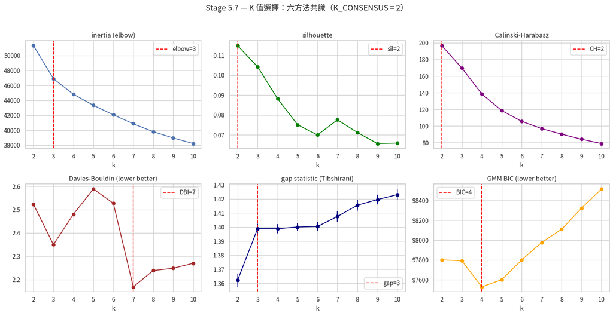

```
下游使用：K_KM (= K_CONSENSUS) = 2; K_GMM (BIC) = 4
```

```python
ks = list(range(2, 11))

km_records = []
for k in ks:
    km = KMeans(n_clusters=k, n_init=10, random_state=RANDOM_STATE).fit(X_pca)
    lab = km.labels_
    km_records.append({
        "k": k,
        "inertia": km.inertia_,
        "silhouette": silhouette_score(X_pca, lab),
        "calinski_harabasz": calinski_harabasz_score(X_pca, lab),
        "davies_bouldin": davies_bouldin_score(X_pca, lab),
    })
gmm_records = []
for k in ks:
    gm = GaussianMixture(n_components=k, covariance_type="diag",
                         n_init=3, random_state=RANDOM_STATE).fit(X_pca)
    gmm_records.append({"k": k, "bic": gm.bic(X_pca), "aic": gm.aic(X_pca)})

def gap_statistic(X, k_values, B=10, seed=RANDOM_STATE):
    X = np.asarray(X)
    n, d = X.shape
    mins, maxs = X.min(axis=0), X.max(axis=0)
    rng = np.random.default_rng(seed)
    log_W_real = []
    for k in k_values:
        km = KMeans(n_clusters=k, n_init=10, random_state=seed).fit(X)
        log_W_real.append(np.log(km.inertia_ + 1e-12))
    ref_logs = np.zeros((B, len(k_values)))
    for b in range(B):
        Xb = rng.uniform(mins, maxs, size=(n, d))
        for j, k in enumerate(k_values):
            km = KMeans(n_clusters=k, n_init=5,
                        random_state=int(rng.integers(1e9))).fit(Xb)
            ref_logs[b, j] = np.log(km.inertia_ + 1e-12)
    mean_ref = ref_logs.mean(axis=0)
    sd_ref = ref_logs.std(axis=0)
    return mean_ref - np.array(log_W_real), sd_ref * np.sqrt(1 + 1.0/B)

gaps, sks = gap_statistic(X_pca.values, ks, B=10)
gap_df = pd.DataFrame({"k": ks, "gap": gaps.round(4), "sk": sks.round(4)})

km_df = pd.DataFrame(km_records)
gmm_df = pd.DataFrame(gmm_records)

def pick_elbow(inertia_series):
    try:
        from kneed import KneeLocator
        kl = KneeLocator(list(inertia_series.index), list(inertia_series.values),
                         curve="convex", direction="decreasing")
        return int(kl.knee) if kl.knee else int(inertia_series.index[0])
    except ImportError:
        diffs = np.diff(inertia_series.values, 2)
        return int(inertia_series.index[np.argmax(diffs) + 1])

elbow_k = pick_elbow(km_df.set_index("k")["inertia"])
sil_k   = int(km_df.loc[km_df["silhouette"].idxmax(), "k"])
ch_k    = int(km_df.loc[km_df["calinski_harabasz"].idxmax(), "k"])
dbi_k   = int(km_df.loc[km_df["davies_bouldin"].idxmin(), "k"])
bic_k   = int(gmm_df.loc[gmm_df["bic"].idxmin(), "k"])
gap_k = ks[-1]
for j in range(len(ks) - 1):
    if gaps[j] >= gaps[j+1] - sks[j+1]:
        gap_k = ks[j]
        break

votes = pd.DataFrame({
    "method": ["elbow (kneed)", "silhouette", "Calinski-Harabasz",
               "Davies-Bouldin (min)", "gap statistic", "GMM BIC (min)"],
    "best_k": [elbow_k, sil_k, ch_k, dbi_k, gap_k, bic_k],
})
show_and_track(votes, "stage5_k_consensus_votes.csv", "table")
show_and_track(km_df.round(3), "stage5_kmeans_metrics.csv", "table")
show_and_track(gap_df, "stage5_gap_statistic.csv", "table")

vote_counts = votes["best_k"].value_counts().sort_index()
K_CONSENSUS = int(vote_counts.idxmax())

print("各方法投票：")
display(votes)
print(f"\n得票分布：{dict(vote_counts)}")
print(f"K_CONSENSUS（最多票）= {K_CONSENSUS}")

# Visualise the six metric curves
fig, axes = plt.subplots(2, 3, figsize=(16, 8))
axes[0, 0].plot(km_df["k"], km_df["inertia"], "o-")
axes[0, 0].axvline(elbow_k, color="red", linestyle="--", label=f"elbow={elbow_k}")
axes[0, 0].set_title("inertia (elbow)"); axes[0, 0].legend()

axes[0, 1].plot(km_df["k"], km_df["silhouette"], "o-", color="green")
axes[0, 1].axvline(sil_k, color="red", linestyle="--", label=f"sil={sil_k}")
axes[0, 1].set_title("silhouette"); axes[0, 1].legend()

axes[0, 2].plot(km_df["k"], km_df["calinski_harabasz"], "o-", color="purple")
axes[0, 2].axvline(ch_k, color="red", linestyle="--", label=f"CH={ch_k}")
axes[0, 2].set_title("Calinski-Harabasz"); axes[0, 2].legend()

axes[1, 0].plot(km_df["k"], km_df["davies_bouldin"], "o-", color="brown")
axes[1, 0].axvline(dbi_k, color="red", linestyle="--", label=f"DBI={dbi_k}")
axes[1, 0].set_title("Davies-Bouldin (lower better)"); axes[1, 0].legend()

axes[1, 1].errorbar(gap_df["k"], gap_df["gap"], yerr=gap_df["sk"], marker="o", color="navy")
axes[1, 1].axvline(gap_k, color="red", linestyle="--", label=f"gap={gap_k}")
axes[1, 1].set_title("gap statistic (Tibshirani)"); axes[1, 1].legend()

axes[1, 2].plot(gmm_df["k"], gmm_df["bic"], "o-", color="orange")
axes[1, 2].axvline(bic_k, color="red", linestyle="--", label=f"BIC={bic_k}")
axes[1, 2].set_title("GMM BIC (lower better)"); axes[1, 2].legend()

for ax in axes.flat:
    ax.set_xlabel("k")
fig.suptitle(f"Stage 5.7 — K 值選擇：六方法共識（K_CONSENSUS = {K_CONSENSUS}）", y=1.02)
plt.tight_layout()
show_and_track(fig, "stage5_k_consensus_panel.png")
plt.show()

K_KM = K_CONSENSUS
K_GMM = bic_k
print(f"\n下游使用：K_KM (= K_CONSENSUS) = {K_KM}; K_GMM (BIC) = {K_GMM}")
```

### 5.8 — Ward hierarchical clustering

- **程式碼目標**：檢查階層式分群是否能穩定描述資料結構。
- **執行方式**：用 Ward linkage 建 dendrogram，並計算 cophenetic correlation。
- **產出與解讀**：dendrogram 顯示群合併過程；cophenetic 越高代表樹狀結構越能保存原距離關係。
- **與後續步驟的關聯**：Ward 結果會和 K-Means、GMM 在 validity panel 中比較。

```
Cophenetic correlation: 0.327
```

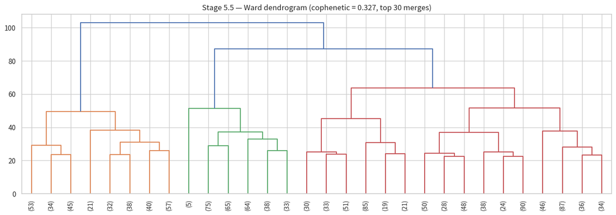

```python
Z = linkage(X_pca, method="ward")
coph, _ = cophenet(Z, pdist(X_pca))
print(f"Cophenetic correlation: {coph:.3f}")

fig, ax = plt.subplots(figsize=(14, 5))
dendrogram(Z, truncate_mode="lastp", p=30, leaf_rotation=90, ax=ax,
           color_threshold=0.7 * max(Z[:, 2]))
ax.set_title(f"Stage 5.5 — Ward dendrogram (cophenetic = {coph:.3f}, top 30 merges)")
plt.tight_layout()
show_and_track(fig, "stage5_dendrogram.png")
plt.show()
```

**結果解讀**

- **看到了什麼**
  - Ward dendrogram（截斷顯示最後 30 次 merge）與印出的 cophenetic correlation 數值。
- **解讀**
  - Cophenetic ≥ 0.7 代表「樹結構忠實反映了原始距離關係」——若低於 0.5 則 dendrogram 的視覺結論不可信。
  - 在 dendrogram 上找一條水平線切過去，能切到 K_CONSENSUS 個分支表示 Ward 與多方法投票一致；切法明顯不同則代表 K-Means 與 Ward 對結構的理解不一樣。
  - 最後幾次大 merge 的高度（圖右側）若有明顯「大跳」，那個跳變的高度通常就是自然的 cluster 切割線。

### 5.9 — GMM BIC/AIC

- **程式碼目標**：用機率模型檢查資料是否適合 soft clustering。
- **執行方式**：對 k=2..10 fit diagonal covariance GMM，記錄 BIC/AIC。
- **產出與解讀**：BIC 越低代表在複雜度懲罰後越適合；GMM 也能產生 `gmm_p*` soft probabilities。
- **與後續步驟的關聯**：後續 final CSV 會保留 GMM membership probabilities 作為 derived features。

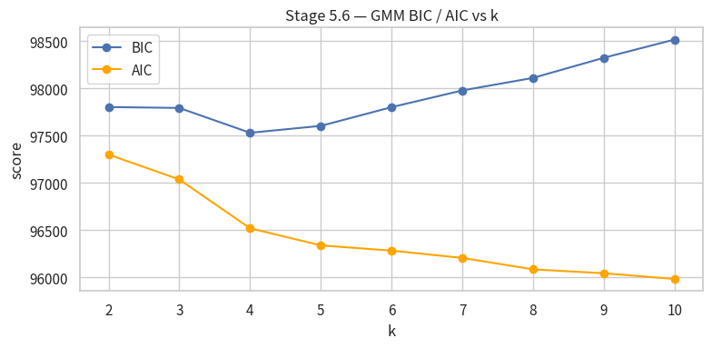

```
Best k by BIC: 4
```

```python
gm_metrics = []
for k in ks:
    gm = GaussianMixture(n_components=k, covariance_type="diag",
                         n_init=3, random_state=RANDOM_STATE).fit(X_pca)
    gm_metrics.append({"k": k, "bic": gm.bic(X_pca), "aic": gm.aic(X_pca)})
gm_df = pd.DataFrame(gm_metrics)
show_and_track(gm_df.round(2), "stage5_gmm_metrics.csv", "table")

fig, ax = plt.subplots(figsize=(8, 4))
ax.plot(gm_df["k"], gm_df["bic"], "o-", label="BIC")
ax.plot(gm_df["k"], gm_df["aic"], "o-", color="orange", label="AIC")
ax.set_xlabel("k"); ax.set_ylabel("score"); ax.legend()
ax.set_title("Stage 5.6 — GMM BIC / AIC vs k")
plt.tight_layout()
show_and_track(fig, "stage5_gmm_bic.png")
plt.show()

K_GMM = int(gm_df.loc[gm_df["bic"].idxmin(), "k"])
print(f"Best k by BIC: {K_GMM}")
```

**結果解讀**

- **看到了什麼**
  - GMM 在 k=2..10 的 BIC / AIC 曲線；最低 BIC 對應的 k_GMM = 4。
- **解讀**
  - BIC 比 AIC 對複雜度懲罰更重，所以通常 BIC 選的 k 比 AIC 小；如果兩條線在同一個 k 同時觸底，那個 k 特別可信。
  - 曲線一路下降不見底代表 GMM 一直能藉由加更多 component 來 fit 資料——可能是資料本身不夠 Gaussian，或者 covariance_type 限制太緊（這裡用 `diag`）。
  - GMM 的優勢在於 soft probabilities：每個 row 可以是「60% cluster A、40% cluster B」，這個訊號比硬切的 cluster_id 對下游監督模型更有用。

### 5.10 — HDBSCAN 密度分群

- **程式碼目標**：檢查是否存在密度明顯不同的自然群與離群點。
- **執行方式**：在 `X_pca` 上 fit HDBSCAN，並畫 condensed tree。
- **產出與解讀**：若 noise 過多或群數不穩，代表資料不適合密度式 hard clustering；若群清楚，可作為 K-Means/GMM 的佐證。
- **與後續步驟的關聯**：本版主要用它做結構檢查，不直接作為最後算法候選。

```
HDBSCAN clusters: 0  | noise points: 1320 / 1320
```

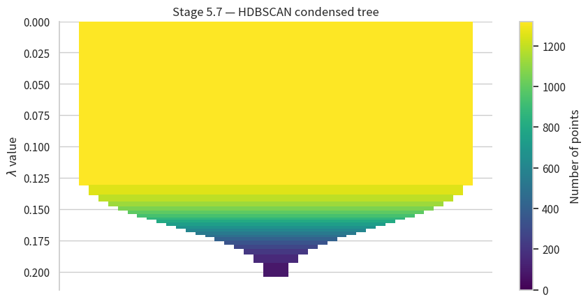

```python
hdb = hdbscan.HDBSCAN(min_cluster_size=max(30, len(X_pca)//40),
                      prediction_data=True).fit(X_pca.values)
labels_hdb = hdb.labels_
n_clusters_hdb = labels_hdb.max() + 1
n_noise = (labels_hdb == -1).sum()
print(f"HDBSCAN clusters: {n_clusters_hdb}  | noise points: {n_noise} / {len(labels_hdb)}")

fig, ax = plt.subplots(figsize=(10, 5))
hdb.condensed_tree_.plot(select_clusters=True,
                          selection_palette=sns.color_palette("deep", max(n_clusters_hdb, 1)),
                          axis=ax)
ax.set_title("Stage 5.7 — HDBSCAN condensed tree")
show_and_track(fig, "stage5_hdbscan_tree.png")
plt.show()
```

**結果解讀**

- **看到了什麼**
  - HDBSCAN 印出找到的 cluster 數、noise 點數，以及 condensed tree 視覺化圖。
- **解讀**
  - Noise 比例（label=-1 的點）若超過 30%，代表資料密度不均、HDBSCAN 視大量點為「不屬於任何 cluster」——這時換 K-Means 或 GMM 更合適。
  - Cluster 數若遠多於 K_CONSENSUS，代表 HDBSCAN 抓到了很多「小密集區」——這些可能對應 niche 比賽型態（如延長賽、雨中比賽），但通常不是 supervised 階段想要的粗粒度 archetype。
  - Condensed tree 視覺化能看出每個 cluster 的「穩定度」（樹幹粗細）——細的代表勉強撐住，是要懷疑的對象。

### 5.11 — 分群有效性與 bootstrap 穩定度

- **程式碼目標**：比較 K-Means、Ward、GMM 的分群品質與穩定性，選出最後算法。
- **執行方式**：計算 silhouette、CH、DBI、bootstrap Jaccard；若達標則按 silhouette/stability 選擇，否則選 silhouette 最高者。
- **產出與解讀**：輸出 `validity` 與 `final_labels`。`final_labels` 是最後 `cluster_id` 的來源。
- **與後續步驟的關聯**：後續所有 cluster 解讀、SHAP、frequency shift 與 final CSV 都依這個結果。

```python
def fit_predict(name, k):
    if name == "kmeans":
        return KMeans(n_clusters=k, n_init=10, random_state=RANDOM_STATE).fit(X_pca).labels_
    if name == "ward":
        return AgglomerativeClustering(n_clusters=k, linkage="ward").fit(X_pca).labels_
    if name == "gmm":
        return GaussianMixture(n_components=k, covariance_type="diag",
                               n_init=3, random_state=RANDOM_STATE).fit(X_pca).predict(X_pca)
    raise ValueError(name)

def jaccard_stability(name, k, B=50, frac=0.8):
    base = fit_predict(name, k)
    rng = np.random.default_rng(RANDOM_STATE)
    stabilities = []
    n = len(X_pca)
    for _ in range(B):
        idx = rng.choice(n, size=int(frac*n), replace=False)
        Xb = X_pca.iloc[idx]
        if name == "kmeans":
            lab = KMeans(n_clusters=k, n_init=5, random_state=int(rng.integers(1e9))).fit(Xb).labels_
        elif name == "ward":
            lab = AgglomerativeClustering(n_clusters=k, linkage="ward").fit(Xb).labels_
        else:
            lab = GaussianMixture(n_components=k, covariance_type="diag",
                                  n_init=1, random_state=int(rng.integers(1e9))).fit(Xb).predict(Xb)
        # match base[idx] to lab via greedy max-Jaccard
        base_idx = base[idx]
        max_jaccards = []
        for c in np.unique(base_idx):
            mask_b = base_idx == c
            best = 0
            for c2 in np.unique(lab):
                mask_l = lab == c2
                inter = (mask_b & mask_l).sum()
                union = (mask_b | mask_l).sum()
                if union > 0:
                    best = max(best, inter / union)
            max_jaccards.append(best)
        stabilities.append(np.mean(max_jaccards))
    return float(np.mean(stabilities))

rows = []
candidates = [("kmeans", K_KM), ("ward", K_KM), ("gmm", K_GMM)]
for name, k in candidates:
    lab = fit_predict(name, k)
    sil = silhouette_score(X_pca, lab)
    ch = calinski_harabasz_score(X_pca, lab)
    dbi = davies_bouldin_score(X_pca, lab)
    jac = jaccard_stability(name, k, B=50)
    rows.append({"algo": name, "k": k, "silhouette": sil,
                 "CH": ch, "DBI": dbi, "bootstrap_jaccard": jac})
validity = pd.DataFrame(rows).round(3)
show_and_track(validity, "stage5_validity_panel.csv", "table")

styled = validity.style.background_gradient(subset=["silhouette","CH","bootstrap_jaccard"], cmap="Greens")\
                       .background_gradient(subset=["DBI"], cmap="Greens_r")
display(styled)

passes = validity[(validity["silhouette"] >= 0.25) & (validity["bootstrap_jaccard"] >= 0.75)]
if len(passes):
    chosen = passes.sort_values(["silhouette","bootstrap_jaccard"], ascending=False).iloc[0]
else:
    chosen = validity.sort_values("silhouette", ascending=False).iloc[0]
ALGO, K_CHOSEN = chosen["algo"], int(chosen["k"])
print(f"\nChosen final algorithm: {ALGO} (k={K_CHOSEN})  "
      f"sil={chosen['silhouette']:.3f} jaccard={chosen['bootstrap_jaccard']:.3f}")
final_labels = fit_predict(ALGO, K_CHOSEN)
```

|  | algo | k | silhouette | CH | DBI | bootstrap_jaccard |
| --- | --- | --- | --- | --- | --- | --- |
| 0 | kmeans | 2 | 0.115000 | 196.640000 | 2.523000 | 0.918000 |
| 1 | ward | 2 | 0.100000 | 130.494000 | 2.635000 | 0.574000 |
| 2 | gmm | 4 | -0.010000 | 25.404000 | 4.902000 | 0.658000 |

```
Chosen final algorithm: kmeans (k=2)  sil=0.115 jaccard=0.918
```

**結果解讀**

- **看到了什麼**
  - K-Means / Ward / GMM 三個算法的 silhouette、Calinski-Harabasz、Davies-Bouldin、bootstrap_jaccard 表，最終 chosen algo = kmeans (k=2)，sil=0.115、jaccard=0.918。
- **解讀**
  - Silhouette 0.115 偏低代表 cluster 之間的幾何分離度普通；Jaccard 0.918 卻很高代表「即使 cluster 邊界鬆，這個切法在子抽樣下仍然穩定」——這通常是「continuous spectrum 切成兩半」的特徵。
  - 與其期待 silhouette 趨近 1（這在 baseball 連續形變資料上不現實），更該關注 Jaccard：穩定的 cluster 即便分離度普通，仍能作為可重現的下游特徵。
  - 若三個算法在不同指標上互有勝負，代表沒有「單一最佳算法」；建議在最終 supervised 比較時把三個 cluster_id 都當 candidate feature 試一輪。

### 5.12 — 每點 silhouette 診斷

- **程式碼目標**：看最後分群中每個樣本對自己 cluster 的適配程度。
- **執行方式**：計算 silhouette_samples，依 cluster 排序畫水平長條。
- **產出與解讀**：負值或接近 0 代表該樣本落在模糊邊界；平均 silhouette 越高，cluster 越清楚。
- **與後續步驟的關聯**：用來檢查 final cluster 是否可靠。

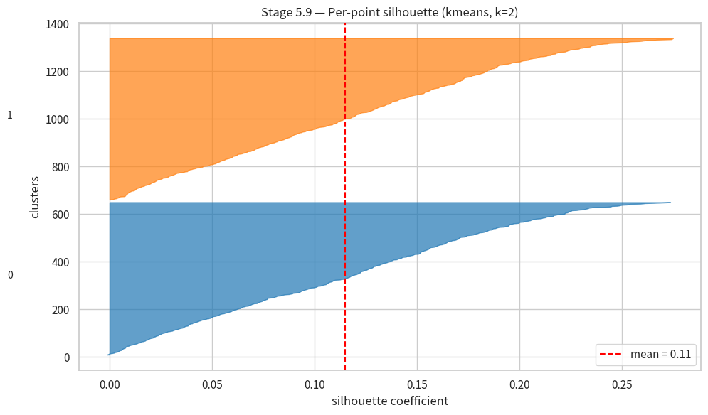

```python
sil_vals = silhouette_samples(X_pca, final_labels)
mean_sil = sil_vals.mean()

fig, ax = plt.subplots(figsize=(10, 6))
y_lower = 10
palette = sns.color_palette("tab10", n_colors=K_CHOSEN)
for c in range(K_CHOSEN):
    vals = np.sort(sil_vals[final_labels == c])
    y_upper = y_lower + len(vals)
    ax.fill_betweenx(np.arange(y_lower, y_upper), 0, vals, color=palette[c], alpha=0.7)
    ax.text(-0.05, y_lower + 0.5 * len(vals), str(c), fontsize=10)
    y_lower = y_upper + 10
ax.axvline(mean_sil, color="red", linestyle="--", label=f"mean = {mean_sil:.2f}")
ax.set_xlabel("silhouette coefficient"); ax.set_ylabel("clusters")
ax.set_title(f"Stage 5.9 — Per-point silhouette ({ALGO}, k={K_CHOSEN})")
ax.legend()
plt.tight_layout()
show_and_track(fig, "stage5_silhouette_per_point.png")
plt.show()
```

**結果解讀**

- **看到了什麼**
  - 每一個 row 的 silhouette 值，按 cluster 分組做成水平 bar（紅虛線標 mean）。
- **解讀**
  - Bar 越長（向右） 代表該 row 與自己 cluster 越貼近；負值代表它離鄰居 cluster 更近（被分錯）。
  - 若某 cluster 的多數 bar 都在紅線下方，代表這個 cluster 內部結構鬆——可能是「雜燴桶」，把不容易歸類的 row 都丟進來。
  - Cluster 大小若極不均（一群有幾百個、另一群只有十幾個），小 cluster 通常是 outlier 集合，需要單獨檢驗其代表性。

### 5.13 — UMAP 二維投影

- **程式碼目標**：用非線性降維視覺化 final cluster 與球季分布。
- **執行方式**：在 `X_scaled` 上 fit UMAP，畫 cluster 與 season 兩個 panel。
- **產出與解讀**：若 cluster 在 UMAP 上成團，代表分群有視覺支持；若只按 season 分開，需小心年份效應。
- **與後續步驟的關聯**：輔助解釋 final cluster 是否像真實情境結構。

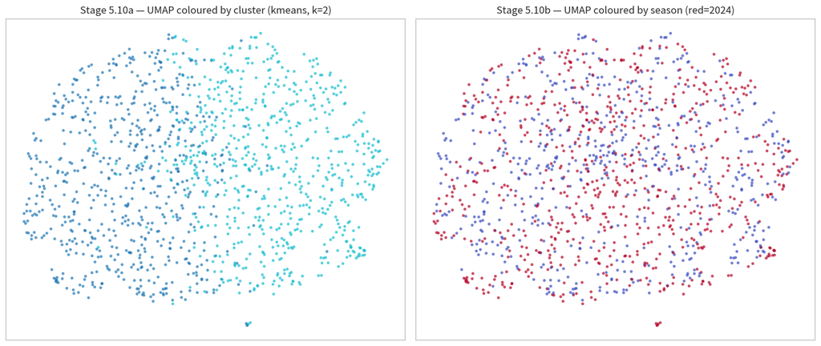

```python
embed_um = umap.UMAP(n_neighbors=30, min_dist=0.1, random_state=RANDOM_STATE).fit_transform(X_scaled)

fig, axes = plt.subplots(1, 2, figsize=(14, 6))
axes[0].scatter(embed_um[:, 0], embed_um[:, 1], c=final_labels, cmap="tab10",
                s=12, alpha=0.7, edgecolor="none")
axes[0].set_title(f"Stage 5.10a — UMAP coloured by cluster ({ALGO}, k={K_CHOSEN})")
season_int = team_game["season_tag"].astype("category").cat.codes.values
axes[1].scatter(embed_um[:, 0], embed_um[:, 1], c=season_int, cmap="coolwarm",
                s=12, alpha=0.7, edgecolor="none")
axes[1].set_title("Stage 5.10b — UMAP coloured by season (red=2024)")
for ax in axes: ax.set_xticks([]); ax.set_yticks([])
plt.tight_layout()
show_and_track(fig, "stage5_umap_pair.png")
plt.show()
```

**結果解讀**

- **看到了什麼**
  - UMAP 二維投影兩面板：左圖按 cluster_id 上色、右圖按 season_tag 上色。
- **解讀**
  - UMAP 比 PCA 更善於展現非線性 manifold——若 cluster 在 UMAP 上各自圍成清楚 blob，代表結構真實存在；若在 UMAP 上幾乎無法分辨，那 K-Means 的切割只是 PC 平面上的人工切法。
  - 按 season 上色的右圖能直接看「2023 與 2024 是否共用同一個 manifold」——交織代表跨季穩定、分團代表 meta shift 大。
  - UMAP 的 n_neighbors 與 min_dist 會影響結構觀感；本 notebook 用 30 / 0.1 是中等粒度設定，micro-cluster 不會被過度暴露。

### 5.14 — t-SNE perplexity sanity check

- **程式碼目標**：用另一種非線性投影檢查 UMAP 結論是否穩定。
- **執行方式**：使用 perplexity 15 與 50 各畫一張 t-SNE。
- **產出與解讀**：若 UMAP 和 t-SNE 都呈現相近分群，視覺結構較可信；若差異很大，代表投影結果不能過度解讀。
- **與後續步驟的關聯**：這是視覺 sanity check，不直接產出欄位。

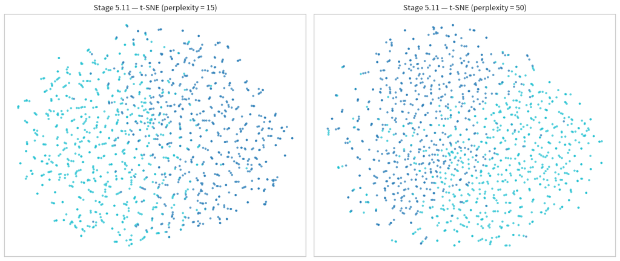

```python
from sklearn.manifold import TSNE
fig, axes = plt.subplots(1, 2, figsize=(14, 6))
for ax, perp in zip(axes, [15, 50]):
    emb = TSNE(n_components=2, perplexity=perp, random_state=RANDOM_STATE,
               init="pca", learning_rate="auto").fit_transform(X_pca)
    ax.scatter(emb[:, 0], emb[:, 1], c=final_labels, cmap="tab10",
               s=12, alpha=0.7, edgecolor="none")
    ax.set_title(f"Stage 5.11 — t-SNE (perplexity = {perp})")
    ax.set_xticks([]); ax.set_yticks([])
plt.tight_layout()
show_and_track(fig, "stage5_tsne_perplexity.png")
plt.show()
```

**結果解讀**

- **看到了什麼**
  - t-SNE 在 perplexity=15 與 50 兩個設定下的並列散點圖。
- **解讀**
  - 兩個 perplexity 看到差不多的整體結構代表 topology 穩定、可以信賴；若小 perplexity 出現許多 micro-cluster、大 perplexity 全部融合，代表只有 fine-grained 結構而無 macro 結構。
  - t-SNE 與 UMAP 比較是「sanity check」——若兩者結論一致，cluster 在投影空間上的呈現就有冗餘的支持。
  - t-SNE 不保留全局距離，所以「不同 cluster 之間的距離大小」不能直接解讀，只看「同 cluster 是否聚」即可。

### 5.15 — cluster mean/SD 表

- **程式碼目標**：把每個 cluster 的原始特徵平均與標準差列出來。
- **執行方式**：在 `team_game` 加上 `cluster` 後 groupby 計算 mean 與 std。
- **產出與解讀**：`cmean` 是 cluster 命名的核心表：平均值高低可以指出該 cluster 是高攻擊、低失分、後段得分或其他型態。
- **與後續步驟的關聯**：後面 radar、boxplot 與 SHAP 都會用它解釋 cluster。

```python
tg_clustered = team_game.copy()
tg_clustered["cluster"] = final_labels
ALL_FEATS_FOR_DESC = sorted(set(NUMERIC_FEATURES) | set(FEATURES_FOR_UNSUP))
cmean = tg_clustered.groupby("cluster")[ALL_FEATS_FOR_DESC].mean().round(3)
cstd = tg_clustered.groupby("cluster")[ALL_FEATS_FOR_DESC].std().round(3)
show_and_track(cmean, "stage5_cluster_means.csv", "table")
show_and_track(cstd, "stage5_cluster_stds.csv", "table")
display(Markdown("**Cluster means**")); display(cmean)
display(Markdown("**Cluster std-dev**")); display(cstd)
```

**Cluster means**

| cluster | AB | BB | H | HR | SO | bb_allowed | day_of_week | days_rest | double | early_runs | ... | runs_allowed | runs_scored | scored_first | season_to_date_run_diff_mean | season_to_date_win_rate | so_pitched | stadium_prior_run_mean | strikeout_walk_ratio | triple | whip_like |
| --- | --- | --- | --- | --- | --- | --- | --- | --- | --- | --- | --- | --- | --- | --- | --- | --- | --- | --- | --- | --- | --- |
| 0 | 33.871 | 3.117 | 8.930 | 0.485 | 6.521 | 2.998 | 3.569 | 1.761 | 1.449 | 1.332 | ... | 4.133 | 4.211 | 0.424 | 0.357 | 0.523 | 6.502 | 4.239 | 3.131 | 0.198 | 1.337 |
| 1 | 33.675 | 3.013 | 8.778 | 0.542 | 6.490 | 3.125 | 3.552 | 2.007 | 1.405 | 1.348 | ... | 4.239 | 4.165 | 0.459 | -0.355 | 0.458 | 6.510 | 4.173 | 2.980 | 0.177 | 1.369 |

2 rows × 84 columns

**Cluster std-dev**

| cluster | AB | BB | H | HR | SO | bb_allowed | day_of_week | days_rest | double | early_runs | ... | runs_allowed | runs_scored | scored_first | season_to_date_run_diff_mean | season_to_date_win_rate | so_pitched | stadium_prior_run_mean | strikeout_walk_ratio | triple | whip_like |
| --- | --- | --- | --- | --- | --- | --- | --- | --- | --- | --- | --- | --- | --- | --- | --- | --- | --- | --- | --- | --- | --- |
| 0 | 3.791 | 1.920 | 3.436 | 0.740 | 2.738 | 1.972 | 1.838 | 8.801 | 1.295 | 1.699 | ... | 3.102 | 3.150 | 0.495 | 0.990 | 0.095 | 2.712 | 0.510 | 2.488 | 0.433 | 0.492 |
| 1 | 3.794 | 1.962 | 3.456 | 0.753 | 2.736 | 1.912 | 1.854 | 10.591 | 1.312 | 1.734 | ... | 3.179 | 3.135 | 0.499 | 0.902 | 0.092 | 2.760 | 0.477 | 2.467 | 0.419 | 0.502 |

2 rows × 84 columns

**結果解讀**

- **看到了什麼**
  - 每個 cluster 的 mean 與 std 表，涵蓋 NUMERIC_FEATURES ∪ FEATURES_FOR_UNSUP 的聯集。
- **解讀**
  - Mean 是 cluster 的「中心位置」、std 是「內部變異」——兩個 cluster 的 mean 差距大且各自 std 小，是強分離；mean 差距大但 std 也大，是「重疊偏移」而非真分離。
  - Pre-game lag features 在這張表通常會展現出最大的 cluster 差異，因為它們本來就是被 cluster 演算法直接使用的輸入。
  - Post-game features（如 `runs_scored / win`）出現在這張表上是 derived comparison：cluster 是用 pre-game features 切的，但仍可以看「不同 pre-game 狀態的 cluster 在 post-game 結果上是否真的不同」——後者是 leakage-free 預測力的代理指標。

### 5.16 — cluster radar chart

- **程式碼目標**：用雷達圖比較不同 cluster 在 focus features 上的 profile。
- **執行方式**：把 cluster mean 在 focus features 上 z-score 後畫 polar chart。
- **產出與解讀**：某 cluster 在某軸突出代表該特徵是它的相對特色；多個軸一起突出可組成情境名稱。
- **與後續步驟的關聯**：幫助把 cluster 從數字變成可溝通的棒球語意。

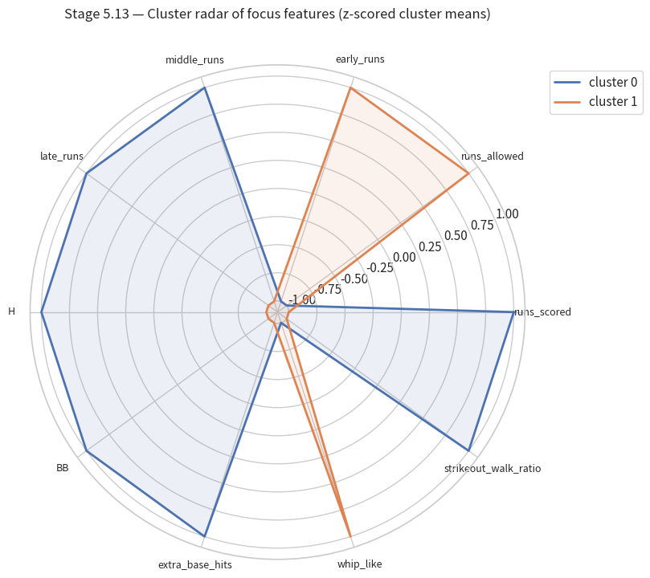

```python
cm_z = (cmean[FOCUS_FEATURES] - cmean[FOCUS_FEATURES].mean()) / cmean[FOCUS_FEATURES].std(ddof=0).replace(0, 1)
angles = np.linspace(0, 2 * np.pi, len(FOCUS_FEATURES), endpoint=False).tolist()
angles += angles[:1]

fig, ax = plt.subplots(figsize=(8, 8), subplot_kw=dict(polar=True))
for c in cm_z.index:
    vals = cm_z.loc[c].tolist() + [cm_z.loc[c].tolist()[0]]
    ax.plot(angles, vals, label=f"cluster {c}", lw=2)
    ax.fill(angles, vals, alpha=0.10)
ax.set_xticks(angles[:-1])
ax.set_xticklabels(FOCUS_FEATURES, fontsize=9)
ax.set_title(f"Stage 5.13 — Cluster radar of focus features (z-scored cluster means)", y=1.08)
ax.legend(bbox_to_anchor=(1.25, 1.0))
show_and_track(fig, "stage5_cluster_radar.png")
plt.show()
```

**結果解讀**

### 5.17 — cluster feature boxplots（notched + bootstrap CI）

- **程式碼目標**：檢查 focus features 在各 cluster 的分布形狀並比較中位數，加上 notch 顯示中位數的 ≈95% bootstrap CI。
- **執行方式**：`sns.boxplot(..., notch=True, bootstrap=2000)`；若任一 cluster 的樣本數 < 10 自動退回普通 boxplot 以避免 flipped-notch（CI 比 IQR 還寬，造成「螞蟻腰」異常形狀）。
- **產出與解讀**：兩個 cluster 的 notch 不重疊 ⇒ 中位數有差距的視覺證據（非正式檢定）。重疊很大或 notch 反摺則代表 cluster 大小差距過大、heavy-tailed 分布讓 1.58·IQR/√n 失準，或該 feature 區分力不足。
- **與後續步驟的關聯**：和 5.18 surrogate-SHAP、5.18a ANOVA F/MI 並排對讀；正式顯著性結論以 5.18a 為準，本格用於形狀直覺。

```
min cluster size = 641 → notch=on
```

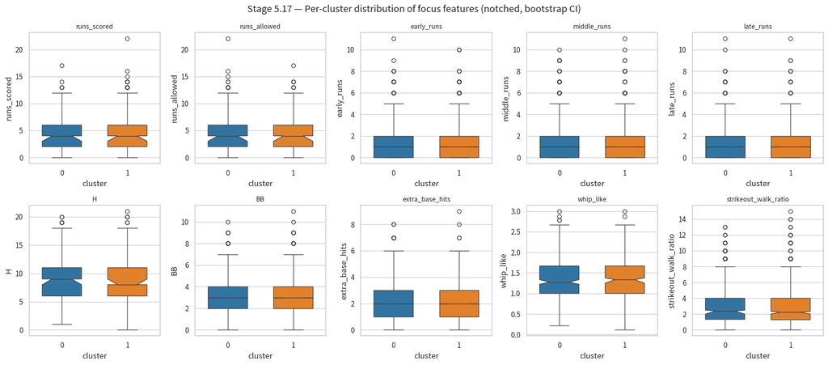

```python
min_cluster_n = tg_clustered["cluster"].value_counts().min()
use_notch = bool(min_cluster_n >= 10)
print(f"min cluster size = {min_cluster_n} → notch={'on' if use_notch else 'off'}")

fig, axes = plt.subplots(2, 5, figsize=(18, 8))
for ax, feat in zip(axes.flat, FOCUS_FEATURES):
    sns.boxplot(
        data=tg_clustered, x="cluster", y=feat,
        ax=ax, palette="tab10", hue="cluster", legend=False,
        notch=use_notch, bootstrap=2000 if use_notch else None,
        width=0.6, showfliers=True,
    )
    ax.set_title(feat, fontsize=10)
fig.suptitle("Stage 5.17 — Per-cluster distribution of focus features (notched, bootstrap CI)")
plt.tight_layout()
show_and_track(fig, "stage5_cluster_boxplots.png")
plt.show()
```

**結果解讀**

- **看到了什麼**
  - 10 個 FOCUS_FEATURES 的 notched boxplot grid（min cluster size = 641，notch 啟用）。
- **解讀**
  - Notch 是中位數的 ≈95% bootstrap CI——兩個 cluster 的 notch 不重疊，是「中位數差異」的視覺證據（非正式檢定）。
  - Notch 寬度與該 cluster 的樣本數有關：樣本越大、notch 越窄；所以兩個大小不同的 cluster 即使中位數差距相同，notch 看起來不一樣寬，是 by design。
  - 若某個 feature 的兩個 cluster boxes 中位數線重疊、notch 大幅重疊，代表這個 feature 對此 cluster 區分力低；反之則是 cluster 解讀時應該重點提的特徵。
  - Stage 5.18a 的 ANOVA F 提供這個視覺直覺的數值化版本——形狀差異 + ANOVA F 大才是「真的可信」。

### 5.18 — surrogate RandomForest + SHAP 解釋 cluster

- **程式碼目標**：用可解釋模型找出每個 cluster 最能被哪些特徵辨識。
- **執行方式**：對每個 cluster 做 one-vs-rest RandomForest，再用 TreeSHAP 取平均絕對 SHAP。
- **產出與解讀**：輸出每個 cluster 的 top SHAP features 與自動命名。這不是用來預測勝負，而是解釋 cluster 的特徵來源。
- **與後續步驟的關聯**：Stage 6 會用這些 SHAP ranks 和 PCA loading 整合成本研究的 feature strategy。

```python
from sklearn.ensemble import RandomForestClassifier

shap_ranks = {}
for c in sorted(set(final_labels)):
    if c < 0: continue
    y = (final_labels == c).astype(int)
    rf = RandomForestClassifier(n_estimators=200, random_state=RANDOM_STATE,
                                n_jobs=-1).fit(X_scaled, y)
    sample = X_scaled.sample(min(200, len(X_scaled)), random_state=RANDOM_STATE)
    explainer = shap.TreeExplainer(rf)
    sv = explainer.shap_values(sample)
    if isinstance(sv, list):
        sv = sv[-1]  # positive class
    if hasattr(sv, "values"):
        sv = sv.values
    if sv.ndim == 3:
        sv = sv[..., 1]  # newer shap returns (n_samples, n_features, n_classes)
    mean_abs = pd.Series(np.abs(sv).mean(axis=0),
                         index=X_scaled.columns).sort_values(ascending=False)
    shap_ranks[c] = mean_abs.head(5)

shap_table = pd.concat({f"cluster {c}": s for c, s in shap_ranks.items()}, axis=1).round(3)
show_and_track(shap_table, "stage5_shap_per_cluster.csv", "table")
display(shap_table)

def auto_label(row, top_feats):
    bits = []
    means = cmean.loc[row][top_feats.index]
    grand = cmean.mean()[top_feats.index]
    for f in top_feats.index[:2]:
        sign = "↑" if means[f] > grand[f] else "↓"
        bits.append(f"{f}{sign}")
    return " · ".join(bits)

cluster_names = {c: auto_label(c, s) for c, s in shap_ranks.items()}
print("\nAuto-generated cluster labels (top-2 |SHAP| direction):")
for c, name in cluster_names.items():
    print(f"  cluster {c}: {name}")
```

|  | cluster 0 | cluster 1 |
| --- | --- | --- |
| prior_run_diff_mean_10 | 0.057 | 0.057 |
| prior_run_diff_mean_5 | 0.057 | 0.057 |
| opp_prior_run_diff_mean_10 | 0.055 | 0.055 |
| opp_prior_run_diff_mean_5 | 0.051 | 0.051 |
| prior_runs_scored_mean_5 | 0.032 | 0.032 |

```
Auto-generated cluster labels (top-2 |SHAP| direction):
  cluster 0: prior_run_diff_mean_10↑ · prior_run_diff_mean_5↑
  cluster 1: prior_run_diff_mean_10↓ · prior_run_diff_mean_5↓
```

**結果解讀**

- **看到了什麼**
  - 每個 cluster 的 top-5 |SHAP| features 表，與自動產生的 cluster 標籤（格式為 `feat↑ · feat↓`）。
- **解讀**
  - 每個 cluster 用一個 one-vs-rest RandomForest classifier + Tree SHAP 解釋——「最能把這個 cluster 與其他 cluster 區分的特徵」就是 cluster 的命名核心。
  - 標籤上的箭頭：↑ 表示該 cluster 在此 feature 高於整體平均、↓ 表示低於。串起來就是 baseball-sense 的描述（如「近期攻擊強 + 對手投手 WHIP 高」）。
  - Surrogate SHAP 的結論若與 5.18a ANOVA F、5.16 radar 三者一致，cluster 命名就有高信心；若三者各自指出不同主軸，代表這個 cluster 結構本身複雜，不容易用 1-2 個 feature 命名。

### 5.18a — 每個 cluster 的有意義特徵：ANOVA F-stat + mutual information

- **程式碼目標**：用 ANOVA F-statistic 與 mutual information 評估「哪些特徵在 cluster 之間差異最大」，再加上 per-cluster z-score 方向，補足 SHAP 給出的 cluster 命名。
- **執行方式**：ANOVA：`scipy.stats.f_oneway` 把每個特徵依 cluster 分組；MI：`sklearn.feature_selection.mutual_info_classif`。Z-score：每個 cluster 的平均減去整體平均再除以整體標準差。
- **產出與解讀**：F 值大的特徵代表 cluster 中心差距大，是 cluster 解讀的「主軸」；MI 補強非線性關係；Z-score 的符號決定 cluster 名稱中的↑/↓。
- **與後續步驟的關聯**：輸出的 ranking 進入 Stage 6.1 的 focus features 對照。

**有意義特徵排名（ANOVA F + MI 共識，前 15）**

|  | feature | anova_F | anova_p | mi | z_cluster_0 | z_cluster_1 | combined_rank |
| --- | --- | --- | --- | --- | --- | --- | --- |
| 0 | prior_run_diff_mean_10 | 575.794 | 0.0 | 0.205 | 0.57 | -0.54 | 1 |
| 1 | prior_run_diff_mean_5 | 592.425 | 0.0 | 0.193 | 0.57 | -0.55 | 2 |
| 2 | opp_prior_run_diff_mean_10 | 532.659 | 0.0 | 0.199 | -0.55 | 0.53 | 3 |
| 3 | opp_prior_run_diff_mean_5 | 546.201 | 0.0 | 0.176 | -0.55 | 0.53 | 4 |
| 4 | prior_runs_scored_mean_5 | 401.457 | 0.0 | 0.152 | 0.50 | -0.47 | 5 |
| 5 | prior_win_rate_5 | 397.220 | 0.0 | 0.136 | 0.49 | -0.47 | 6 |
| 6 | opp_prior_runs_scored_mean_10 | 363.104 | 0.0 | 0.141 | -0.48 | 0.46 | 7 |
| 7 | prior_runs_scored_mean_10 | 374.026 | 0.0 | 0.125 | 0.48 | -0.46 | 8 |
| 8 | opp_prior_win_rate_10 | 341.038 | 0.0 | 0.139 | -0.46 | 0.45 | 9 |
| 9 | opp_prior_win_rate_5 | 376.327 | 0.0 | 0.111 | -0.48 | 0.46 | 9 |
| 10 | opp_prior_runs_scored_mean_5 | 372.888 | 0.0 | 0.120 | -0.48 | 0.46 | 10 |
| 11 | prior_win_rate_10 | 357.800 | 0.0 | 0.120 | 0.48 | -0.45 | 11 |
| 12 | prior_run_per_hit_mean_10 | 252.292 | 0.0 | 0.100 | 0.41 | -0.39 | 12 |
| 13 | opp_prior_run_per_hit_mean_10 | 233.177 | 0.0 | 0.093 | -0.40 | 0.38 | 13 |
| 14 | prior_run_per_hit_mean_5 | 284.881 | 0.0 | 0.079 | 0.43 | -0.41 | 14 |

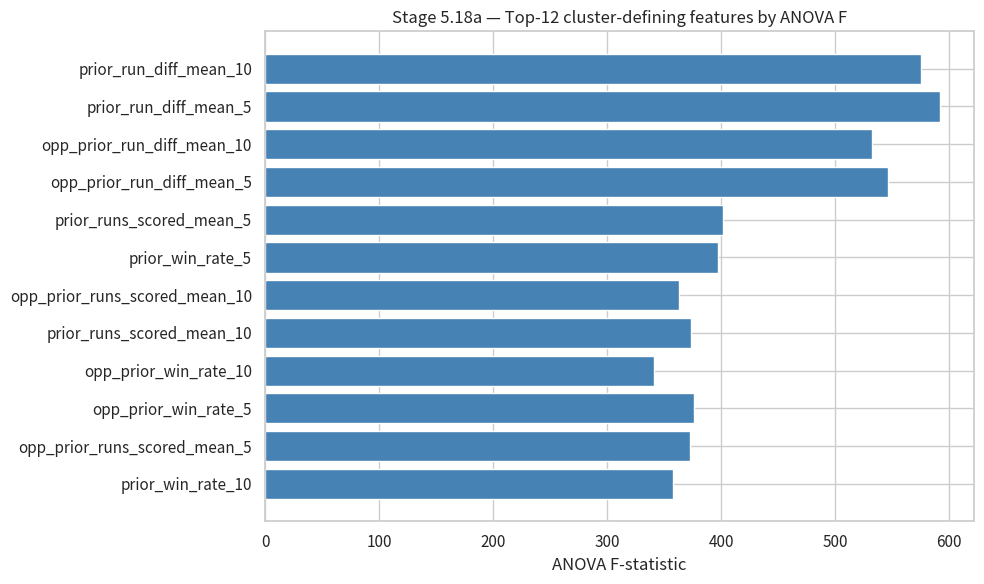

```python
from sklearn.feature_selection import mutual_info_classif

rows = []
for c in FEATURES_FOR_UNSUP:
    groups = [tg_clustered.loc[tg_clustered["cluster"] == cl, c].dropna().values
              for cl in sorted(tg_clustered["cluster"].unique())]
    if all(len(g) > 1 for g in groups):
        try:
            f_stat, p_val = stats.f_oneway(*groups)
        except Exception:
            f_stat, p_val = np.nan, np.nan
    else:
        f_stat, p_val = np.nan, np.nan
    rows.append({"feature": c, "anova_F": f_stat, "anova_p": p_val})
anova_df = pd.DataFrame(rows)

mi_scores = mutual_info_classif(X_scaled.values, final_labels,
                                discrete_features=False, random_state=RANDOM_STATE)
mi_df = pd.DataFrame({"feature": list(X_scaled.columns), "mi": mi_scores})

meaningful = anova_df.merge(mi_df, on="feature", how="outer")

# Per-cluster z-score
grand_mean = tg_clustered[FEATURES_FOR_UNSUP].mean()
grand_std = tg_clustered[FEATURES_FOR_UNSUP].std(ddof=0).replace(0, 1)
z_table = ((tg_clustered.groupby("cluster")[FEATURES_FOR_UNSUP].mean() - grand_mean)
           / grand_std).T.round(2)
z_table.columns = [f"z_cluster_{c}" for c in z_table.columns]
meaningful = meaningful.merge(z_table, left_on="feature", right_index=True, how="left")

meaningful["combined_rank"] = (
    meaningful["anova_F"].rank(ascending=False, method="min")
    + meaningful["mi"].rank(ascending=False, method="min")
).rank(method="dense")
meaningful["combined_rank"] = meaningful["combined_rank"].round().astype(int)
meaningful = meaningful.sort_values("combined_rank").reset_index(drop=True)
show_and_track(meaningful.round(3), "stage5_meaningful_features.csv", "table")

display(Markdown("**有意義特徵排名（ANOVA F + MI 共識，前 15）**"))
display(meaningful.head(15).round(3))

top12 = meaningful.head(12)
fig, ax = plt.subplots(figsize=(10, 6))
ax.barh(top12["feature"][::-1], top12["anova_F"][::-1], color="steelblue")
ax.set_xlabel("ANOVA F-statistic")
ax.set_title("Stage 5.18a — Top-12 cluster-defining features by ANOVA F")
plt.tight_layout()
show_and_track(fig, "stage5_anova_top12.png")
plt.show()
```

**結果解讀**

- **看到了什麼**
  - ANOVA F + MI 共識排名表（feature × cluster），加上 per-cluster z-score 方向欄位。
  - Top-12 feature 的 ANOVA F-statistic horizontal bar chart。
- **解讀**
  - ANOVA F 越大代表「該 feature 在 cluster 間平均差距越大、cluster 內方差越小」——即該 feature 是 cluster 的定義性指標。
  - MI 是 ANOVA 的非線性版本，能抓到「平均不變但分布形狀變」的情況；兩者排名一致時是強信號。
  - z_cluster_* 欄位提供方向（正 = 高於整體、負 = 低於），直接告訴 SHAP 標籤中該寫 ↑ 還是 ↓——是 5.18 自動標籤的數值佐證。
  - 這張表也是 Stage 6.1 overlap 排名的主要輸入——unsupervised 找到的「有意義特徵」就是這份排名靠前的集合。

### 5.19 — 2023 vs 2024 cluster frequency shift

- **程式碼目標**：檢查不同球季落入各 cluster 的比例是否改變。
- **執行方式**：用 crosstab 計算 season × cluster，畫百分比長條與 Sankey flow。
- **產出與解讀**：如果某 cluster 在 2024 明顯增加，代表該情境在 2024 更常見；若比例穩定，代表 cluster 跨年較穩。
- **與後續步驟的關聯**：幫助判斷 derived cluster feature 是否可跨球季使用。

| cluster season_tag | 0 | 1 |
| --- | --- | --- |
| 2023 | 289 | 311 |
| 2024 | 352 | 368 |

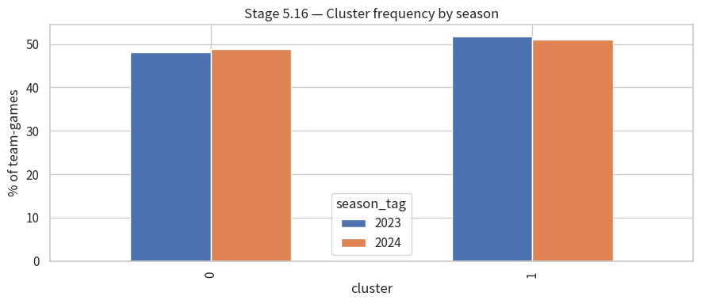

[interactive chart not shown]

```python
ctab = pd.crosstab(tg_clustered["season_tag"], tg_clustered["cluster"])
show_and_track(ctab, "stage5_season_cluster_xtab.csv", "table")
display(ctab)

fig, ax = plt.subplots(figsize=(9, 4))
ctab_pct = ctab.div(ctab.sum(axis=1), axis=0) * 100
ctab_pct.T.plot(kind="bar", ax=ax)
ax.set_ylabel("% of team-games"); ax.set_title("Stage 5.16 — Cluster frequency by season")
plt.tight_layout()
show_and_track(fig, "stage5_cluster_freq_shift.png")
plt.show()

import plotly.graph_objects as go
labels_sk = [f"{s}" for s in ctab.index] + [f"cluster {c}" for c in ctab.columns]
src, tgt, val = [], [], []
for i, s in enumerate(ctab.index):
    for j, c in enumerate(ctab.columns):
        src.append(i); tgt.append(len(ctab.index) + j); val.append(int(ctab.loc[s, c]))
sk = go.Figure(go.Sankey(node=dict(label=labels_sk, pad=15, thickness=15),
                          link=dict(source=src, target=tgt, value=val)))
sk.update_layout(title_text="Stage 5.16 — Sankey: season → cluster", font_size=10)
show_and_track(sk, "stage5_season_cluster_sankey.html")
sk.show()
```

**結果解讀**

### 5.20 — 建立 derived feature register

- **程式碼目標**：把非監督學習結果合併回 team-game 主表。
- **執行方式**：新增 `cluster_id`、`pc1..pcK` 與 `gmm_p0..gmm_pK`。
- **產出與解讀**：產出 `tg_with_new`。這是最終 CSV 的主要來源之一。
- **與後續步驟的關聯**：Stage 6/7 會把它和 original features、語意標籤一起輸出。

```python
tg_with_new = team_game.copy()
tg_with_new["cluster_id"] = final_labels
for i in range(K_PCA):
    tg_with_new[f"pc{i+1}"] = X_pca.iloc[:, i].values

gmm = GaussianMixture(n_components=K_GMM, covariance_type="diag",
                      n_init=3, random_state=RANDOM_STATE).fit(X_pca)
probs = gmm.predict_proba(X_pca)
for i in range(K_GMM):
    tg_with_new[f"gmm_p{i}"] = probs[:, i]

print("新增 derived feature 欄位：", ["cluster_id"] + [f"pc{i+1}" for i in range(K_PCA)] +
      [f"gmm_p{i}" for i in range(K_GMM)])
display(tg_with_new[["team","season_tag","cluster_id"] +
                    [f"pc{i+1}" for i in range(min(3, K_PCA))]].head())
```

```
新增 derived feature 欄位： ['cluster_id', 'pc1', 'pc2', 'pc3', 'pc4', 'pc5', 'pc6', 'pc7', 'pc8', 'pc9', 'pc10', 'pc11', 'pc12', 'pc13', 'pc14', 'pc15', 'pc16', 'pc17', 'pc18', 'pc19', 'pc20', 'pc21', 'pc22', 'pc23', 'pc24', 'gmm_p0', 'gmm_p1', 'gmm_p2', 'gmm_p3']
```

|  | team | season_tag | cluster_id | pc1 | pc2 | pc3 |
| --- | --- | --- | --- | --- | --- | --- |
| 0 | 中信兄弟 | 2023 | 1 | -0.060838 | -0.543656 | -0.039165 |
| 1 | 中信兄弟 | 2023 | 1 | -0.060565 | -0.551250 | -0.042953 |
| 2 | 中信兄弟 | 2023 | 1 | -5.247249 | -4.187868 | 2.446139 |
| 3 | 中信兄弟 | 2023 | 0 | 0.282506 | -0.275935 | -0.415952 |
| 4 | 中信兄弟 | 2023 | 1 | -1.381014 | -2.775002 | -1.756073 |

**結果解讀**

- **看到了什麼**
  - `tg_with_new` 新增的欄位列表（cluster_id + pc1..pc24 + gmm_p0..gmm_p3），與前幾列預覽。
- **解讀**
  - 這是 unsupervised 階段對 team-game 表的「特徵賦值」——每場比賽現在多了 cluster_id（硬性歸屬）、pc 分數（連續嵌入）、gmm 機率（soft membership）。
  - Soft 機率（gmm_p*）比硬 cluster_id 對下游監督模型更有用，因為它保留了「兩個 cluster 之間的程度」訊息，避免「正好在 cluster 邊界」的點被武斷分類。
  - Stage 7 會把這些欄位輸出到 final_features.csv，鍵為 (game_id, team)，方便下游 supervised 模型直接 join。

## Stage 6 — 綜合整理與建模建議

這一階段把前面的統計、PCA、cluster 與 SHAP 整合起來，回答三個問題：

- 本研究的 focus features 在非監督結構中扮演什麼角色？
- 本 notebook 額外產生了哪些 derived features？
- 最後哪些 original/derived features 適合輸出給後續模型使用？

### 6.1 — focus features 與非監督結構的交集

- **程式碼目標**：把本研究 focus features 和 PCA loading、cluster SHAP 結果對照。
- **執行方式**：對每個 focus feature 取 PC1/PC2 loading 與各 cluster SHAP 的最大值，合成 overlap table。
- **產出與解讀**：排名高代表該特徵在本 notebook 的非監督結構中有解釋力。
- **與後續步驟的關聯**：這張表用來決定 final CSV 中哪些欄位應優先保留。

```python
overlap_rows = []
shap_max = pd.DataFrame(shap_ranks).fillna(0).max(axis=1)
for f in FEATURES_FOR_UNSUP:
    overlap_rows.append({
        "feature": f,
        "pc1_loading": float(loadings_abs.loc[f, "PC1"]) if f in loadings_abs.index else np.nan,
        "pc2_loading": float(loadings_abs.loc[f, "PC2"]) if f in loadings_abs.index else np.nan,
        "max_shap_per_cluster": float(shap_max.get(f, np.nan)),
        "in_kept_set": f in KEPT,
    })
overlap = pd.DataFrame(overlap_rows).round(3)
overlap["combined_score"] = overlap[["pc1_loading","pc2_loading","max_shap_per_cluster"]].sum(axis=1).round(3)
overlap = overlap.sort_values("combined_score", ascending=False)
show_and_track(overlap, "stage6_focus_overlap.csv", "table")
display(overlap)
```

|  | feature | pc1_loading | pc2_loading | max_shap_per_cluster | in_kept_set | combined_score |
| --- | --- | --- | --- | --- | --- | --- |
| 36 | opp_prior_run_diff_mean_10 | 0.623 | 0.572 | 0.055 | True | 1.250 |
| 6 | prior_run_diff_mean_10 | 0.750 | 0.432 | 0.057 | True | 1.239 |
| 31 | opp_prior_runs_scored_mean_5 | 0.550 | 0.660 | NaN | True | 1.210 |
| 35 | opp_prior_run_diff_mean_5 | 0.625 | 0.533 | 0.051 | True | 1.209 |
| 1 | prior_runs_scored_mean_5 | 0.661 | 0.507 | 0.032 | True | 1.200 |
| 32 | opp_prior_runs_scored_mean_10 | 0.534 | 0.653 | NaN | True | 1.187 |
| 5 | prior_run_diff_mean_5 | 0.733 | 0.381 | 0.057 | True | 1.171 |
| 2 | prior_runs_scored_mean_10 | 0.653 | 0.512 | NaN | True | 1.165 |
| 8 | prior_win_rate_10 | 0.605 | 0.394 | NaN | True | 0.999 |
| 38 | opp_prior_win_rate_10 | 0.490 | 0.496 | NaN | True | 0.986 |
| 37 | opp_prior_win_rate_5 | 0.515 | 0.460 | NaN | True | 0.975 |
| 41 | opp_prior_H_mean_5 | 0.414 | 0.553 | NaN | True | 0.967 |
| 42 | opp_prior_H_mean_10 | 0.413 | 0.537 | NaN | True | 0.950 |
| 7 | prior_win_rate_5 | 0.610 | 0.339 | NaN | True | 0.949 |
| 11 | prior_H_mean_5 | 0.506 | 0.436 | NaN | True | 0.942 |
| 12 | prior_H_mean_10 | 0.508 | 0.427 | NaN | True | 0.935 |
| 46 | opp_prior_extra_base_hits_mean_10 | 0.338 | 0.539 | NaN | True | 0.877 |
| 51 | opp_prior_late_runs_mean_5 | 0.345 | 0.519 | NaN | True | 0.864 |
| 16 | prior_extra_base_hits_mean_10 | 0.424 | 0.430 | NaN | True | 0.854 |
| 21 | prior_late_runs_mean_5 | 0.428 | 0.416 | NaN | True | 0.844 |
| 45 | opp_prior_extra_base_hits_mean_5 | 0.339 | 0.490 | NaN | True | 0.829 |
| 52 | opp_prior_late_runs_mean_10 | 0.328 | 0.474 | NaN | True | 0.802 |
| 15 | prior_extra_base_hits_mean_5 | 0.414 | 0.382 | NaN | True | 0.796 |
| 22 | prior_late_runs_mean_10 | 0.409 | 0.379 | NaN | True | 0.788 |
| 28 | season_to_date_run_diff_mean | 0.521 | 0.256 | NaN | True | 0.777 |
| 27 | season_to_date_win_rate | 0.486 | 0.280 | NaN | True | 0.766 |
| 54 | opp_prior_run_per_hit_mean_10 | 0.328 | 0.383 | NaN | True | 0.711 |
| 24 | prior_run_per_hit_mean_10 | 0.400 | 0.297 | NaN | True | 0.697 |
| 53 | opp_prior_run_per_hit_mean_5 | 0.332 | 0.352 | NaN | True | 0.684 |
| 23 | prior_run_per_hit_mean_5 | 0.391 | 0.261 | NaN | True | 0.652 |
| 44 | opp_prior_BB_mean_10 | 0.282 | 0.275 | NaN | True | 0.557 |
| 43 | opp_prior_BB_mean_5 | 0.257 | 0.286 | NaN | True | 0.543 |
| 40 | opp_prior_scored_first_rate_10 | 0.280 | 0.262 | NaN | True | 0.542 |
| 14 | prior_BB_mean_10 | 0.333 | 0.204 | NaN | True | 0.537 |
| 10 | prior_scored_first_rate_10 | 0.336 | 0.199 | NaN | True | 0.535 |
| 13 | prior_BB_mean_5 | 0.308 | 0.219 | NaN | True | 0.527 |
| 39 | opp_prior_scored_first_rate_5 | 0.265 | 0.234 | NaN | True | 0.499 |
| 9 | prior_scored_first_rate_5 | 0.312 | 0.169 | NaN | True | 0.481 |
| 4 | prior_runs_allowed_mean_10 | 0.388 | 0.070 | NaN | True | 0.458 |
| 34 | opp_prior_runs_allowed_mean_10 | 0.332 | 0.121 | NaN | True | 0.453 |
| 33 | opp_prior_runs_allowed_mean_5 | 0.326 | 0.076 | NaN | True | 0.402 |
| 3 | prior_runs_allowed_mean_5 | 0.366 | 0.018 | NaN | True | 0.384 |
| 29 | h2h_prior_win_rate | 0.353 | 0.003 | NaN | True | 0.356 |
| 18 | prior_whip_like_mean_10 | 0.241 | 0.021 | NaN | True | 0.262 |
| 48 | opp_prior_whip_like_mean_10 | 0.206 | 0.049 | NaN | True | 0.255 |
| 47 | opp_prior_whip_like_mean_5 | 0.205 | 0.030 | NaN | True | 0.235 |
| 17 | prior_whip_like_mean_5 | 0.229 | 0.002 | NaN | True | 0.231 |
| 30 | stadium_prior_run_mean | 0.092 | 0.129 | NaN | True | 0.221 |
| 20 | prior_strikeout_walk_ratio_mean_10 | 0.147 | 0.069 | NaN | True | 0.216 |
| 19 | prior_strikeout_walk_ratio_mean_5 | 0.137 | 0.064 | NaN | True | 0.201 |
| 50 | opp_prior_strikeout_walk_ratio_mean_10 | 0.113 | 0.082 | NaN | True | 0.195 |
| 49 | opp_prior_strikeout_walk_ratio_mean_5 | 0.106 | 0.077 | NaN | True | 0.183 |
| 25 | days_rest | 0.009 | 0.063 | NaN | True | 0.072 |
| 26 | day_of_week | 0.000 | 0.024 | NaN | True | 0.024 |
| 0 | is_home | 0.003 | 0.004 | NaN | True | 0.007 |

**結果解讀**

- **看到了什麼**
  - active 特徵集合（pre-game gate ON 時為 lag features）對應的 pc1_loading、pc2_loading、max_shap_per_cluster、combined_score 排名表。
- **解讀**
  - combined_score 高代表「PCA 與 SHAP 都認為這個 feature 重要」——這是 unsupervised 階段對下游監督的「自信特徵」。
  - 排名低的 feature 不必丟棄，但要意識到它在 cluster 結構中沒有主導作用，於 supervised 階段需要更多 sample 才能展現價值。
  - 若某個 Wang 學長 top-10 (post-game) feature 在本表上消失，是因為 gate ON 時我們不用 post-game 特徵——這是設計上的選擇，不是 bug。

### 6.2 — 非監督階段新增的候選特徵

- **程式碼目標**：整理可以交給後續模型使用的 derived features。
- **執行方式**：列出 `cluster_id`、GMM soft probabilities、前幾個 PC scores 的型態與解讀。
- **產出與解讀**：輸出的 `new_feat` 是 derived feature 說明表；可看每個新欄位代表硬分群、軟分群或連續主成分。
- **與後續步驟的關聯**：Stage 7 會把這些欄位寫進 final CSV。

```python
candidates = [
    {"new_feature": "cluster_id", "kind": "categorical",
     "description": "Final hard cluster assignment ({} clusters via {})".format(K_CHOSEN, ALGO),
     "interpretation": "; ".join(f"{c}: {n}" for c, n in cluster_names.items())},
]
for i in range(K_GMM):
    candidates.append({
        "new_feature": f"gmm_p{i}",
        "kind": "soft probability",
        "description": f"Posterior probability of GMM component {i}",
        "interpretation": "smooth membership; useful as regression covariate",
    })
for i in range(min(3, K_PCA)):
    top_feats = loadings_abs.iloc[:, i].abs().nlargest(3).index.tolist()
    candidates.append({
        "new_feature": f"pc{i+1}",
        "kind": "continuous PC score",
        "description": f"Projection onto PC{i+1} ({pca_k.explained_variance_ratio_[i]:.1%} variance)",
        "interpretation": f"loaded by {top_feats}",
    })

new_feat = pd.DataFrame(candidates)
show_and_track(new_feat, "stage6_new_candidate_features.csv", "table")
display(new_feat)
```

|  | new_feature | kind | description | interpretation |
| --- | --- | --- | --- | --- |
| 0 | cluster_id | categorical | Final hard cluster assignment (2 clusters via ... | 0: prior_run_diff_mean_10↑ · prior_run_diff_me... |
| 1 | gmm_p0 | soft probability | Posterior probability of GMM component 0 | smooth membership; useful as regression covariate |
| 2 | gmm_p1 | soft probability | Posterior probability of GMM component 1 | smooth membership; useful as regression covariate |
| 3 | gmm_p2 | soft probability | Posterior probability of GMM component 2 | smooth membership; useful as regression covariate |
| 4 | gmm_p3 | soft probability | Posterior probability of GMM component 3 | smooth membership; useful as regression covariate |
| 5 | pc1 | continuous PC score | Projection onto PC1 (18.7% variance) | loaded by ['prior_run_diff_mean_10', 'prior_ru... |
| 6 | pc2 | continuous PC score | Projection onto PC2 (13.7% variance) | loaded by ['opp_prior_runs_scored_mean_5', 'op... |
| 7 | pc3 | continuous PC score | Projection onto PC3 (7.8% variance) | loaded by ['prior_runs_allowed_mean_10', 'prio... |

**結果解讀**

- **看到了什麼**
  - Unsupervised 階段新增的 candidate feature 清單：cluster_id（categorical）+ gmm_p0..N（soft probability）+ pc1..pcK（continuous PC scores），各帶 description 與 interpretation。
- **解讀**
  - 這份清單就是「本研究實際的交付」——這幾個欄位是 Wang 學長原始 feature set 沒有的，將交給下游 supervised 模型驗證是否真的提升 AUC。
  - 若加上這些 feature 後 supervised 模型沒有顯著改善，代表 unsupervised cluster 結構與 win 的關係已經被 Wang 原始 feature 隱含表達——這也是有意義的負結論。
  - 若顯著改善，代表 cluster 抓到了 Wang feature 表達不出的 latent 因子，可進一步往「cluster 命名 → 拍照式特徵工程」延伸。

### 6.3 — 本研究設計摘要與 feature 策略

- **程式碼目標**：整理本 notebook 的獨立研究設計，並列出可保留的 original features 與可行 derived features。
- **執行方式**：建立 research design summary，並列出 focus features、original features、derived features 的建議用法。
- **產出與解讀**：輸出 `research_design_summary` 與 `feature_strategy`。這兩張表可直接放進報告，說明資料來源、分析單位、方法與輸出策略。
- **與後續步驟的關聯**：下一階段會把這些表與 final features 一起存成 CSV。

```python
research_design_summary = pd.DataFrame([
    {"面向": "資料來源", "本研究設計": "直接從 rebas.tw GitHub Releases 下載 2023 與 2024 regular season OpenData。", "解讀": "資料取得可重現，不依賴任何本機 repo 或外部已清理結果。"},
    {"面向": "分析單位", "本研究設計": "一列代表一隊一場 team-game performance。", "解讀": "適合分析球隊單場攻守節奏、主客場情境與分群結構。"},
    {"面向": "主要方法", "本研究設計": "描述統計、EDA、PCA、多種 clustering、surrogate SHAP 解釋。", "解讀": "這是獨立的 unsupervised feature discovery，不使用既有模型結論。"},
    {"面向": "最後輸出", "本研究設計": "original/direct box-score features + derived semantic/numeric/unsupervised features。", "解讀": "輸出可作為後續模型候選資料，但是否可用需依預測時間點檢查 leakage。"},
])
show_and_track(research_design_summary, "stage6_research_design_summary.csv", "table")
display(research_design_summary)

retained_focus_features = [f for f in FOCUS_FEATURES if f in tg_with_new.columns]
added_original_candidates = [
    "season_tag", "date", "stadium", "team", "opponent", "is_home",
    "AB", "H", "BB", "SO", "double", "triple", "HR",
    "outs_pitched", "hits_allowed", "bb_allowed", "hr_allowed", "so_pitched",
]
added_derived_candidates = [
    "home_away_label", "result_label", "run_diff_label", "scoring_level", "allowing_level",
    "game_flow_label", "offense_label", "defense_label", "run_diff", "early_runs", "middle_runs",
    "late_runs", "scored_first", "led_after_3", "led_after_6", "extra_base_hits", "power_score",
    "run_per_hit", "offense_pressure_score", "innings_pitched", "whip_like", "strikeout_walk_ratio",
    "run_prevention_score", "cluster_id",
] + [f"pc{i+1}" for i in range(K_PCA)] + [f"gmm_p{i}" for i in range(K_GMM)]

feature_strategy = pd.DataFrame([
    {"類型": "本研究 focus features", "欄位": ", ".join(retained_focus_features), "建議": "保留。這組欄位覆蓋得失分、逐局節奏、進攻量、攻擊延伸能力與投手/防守壓制。"},
    {"類型": "可保留/增添的 original features", "欄位": ", ".join([c for c in added_original_candidates if c in tg_with_new.columns]), "建議": "可作為分組、控制變數或模型輸入；若目標是賽前/打席前預測，要確認該欄位在預測時間點已知。"},
    {"類型": "可行的 derived features", "欄位": ", ".join([c for c in added_derived_candidates if c in tg_with_new.columns]), "建議": "可用於 context layer。若是預測同場未來打席，賽後才知道的得分、勝負、完整投打表現不可直接使用。"},
])
show_and_track(feature_strategy, "stage6_feature_strategy.csv", "table")
display(feature_strategy)
```

|  | 面向 | 本研究設計 | 解讀 |
| --- | --- | --- | --- |
| 0 | 資料來源 | 直接從 rebas.tw GitHub Releases 下載 2023 與 2024 re... | 資料取得可重現，不依賴任何本機 repo 或外部已清理結果。 |
| 1 | 分析單位 | 一列代表一隊一場 team-game performance。 | 適合分析球隊單場攻守節奏、主客場情境與分群結構。 |
| 2 | 主要方法 | 描述統計、EDA、PCA、多種 clustering、surrogate SHAP 解釋。 | 這是獨立的 unsupervised feature discovery，不使用既有模型結論。 |
| 3 | 最後輸出 | original/direct box-score features + derived s... | 輸出可作為後續模型候選資料，但是否可用需依預測時間點檢查 leakage。 |

|  | 類型 | 欄位 | 建議 |
| --- | --- | --- | --- |
| 0 | 本研究 focus features | runs_scored, runs_allowed, early_runs, middle_... | 保留。這組欄位覆蓋得失分、逐局節奏、進攻量、攻擊延伸能力與投手/防守壓制。 |
| 1 | 可保留/增添的 original features | season_tag, date, stadium, team, opponent, is_... | 可作為分組、控制變數或模型輸入；若目標是賽前/打席前預測，要確認該欄位在預測時間點已知。 |
| 2 | 可行的 derived features | home_away_label, result_label, run_diff_label,... | 可用於 context layer。若是預測同場未來打席，賽後才知道的得分、勝負、完整投打表... |

**結果解讀**

### Stage 6 小結

- Focus / lag features 與 unsupervised 結構的 overlap 表，combined_score 排序給出「最有信心」的特徵。
- Unsupervised 新增的候選特徵清單（cluster_id、pc1..pcK、gmm_p0..gmm_pK）已準備好供下游 supervised 對照。
- Research design summary 一張表就能放進報告 / 簡報。

## Stage 7 — 最終 CSV 輸出

最後產出不是只有圖，而是一份可供後續 model 使用的 `cpbl_original_and_derived_features.csv`。這份 CSV 同時包含 original/direct box-score features 與 derived features；但是否能放進模型，取決於模型目標與預測時間點。若做賽後 descriptive model 可以較自由；若做賽前或打席前 prediction，必須排除未來才知道的欄位以避免 data leakage。

### 7.1 — Registry preview

- **程式碼目標**：檢查目前有哪些中間 artifacts 被登記，可選擇性打包。
- **執行方式**：把 `ARTIFACTS` 轉成 DataFrame 顯示名稱與種類。
- **產出與解讀**：這不是最終主 CSV，而是中間分析產物清單。若只需要 final features，可忽略打包。
- **與後續步驟的關聯**：下一格會直接輸出主要 CSV；最後一格才是選擇性 artifacts zip。

```python
registry = pd.DataFrame([{"idx": i, "name": a["name"], "kind": a["kind"]}
                         for i, a in enumerate(ARTIFACTS)])
print(f"目前已登記可選擇匯出的 artifacts：{len(registry)} 筆")
display(registry)
```

```
目前已登記可選擇匯出的 artifacts：51 筆
```

|  | idx | name | kind |
| --- | --- | --- | --- |
| 0 | 0 | stage2_wang_merge_comparison.csv | table |
| 1 | 1 | stage2_wang_merge_2024.csv | table |
| 2 | 2 | stage3_describe_overall.csv | table |
| 3 | 3 | stage3_per_season_focus.csv | table |
| 4 | 4 | stage3_base_rates.csv | table |
| 5 | 5 | stage3_corr_vs_win.csv | table |
| 6 | 6 | stage3_corr_vs_run_diff.csv | table |
| 7 | 7 | stage3_skew_kurtosis_missing.csv | table |
| 8 | 8 | stage4_small_multiples_top10.png | figure |
| 9 | 9 | stage4_spearman_heatmap.png | figure |
| 10 | 10 | stage4_pairplot_top5.png | figure |
| 11 | 11 | stage4_home_away_means.png | figure |
| 12 | 12 | stage4_monthly_trajectory.png | figure |
| 13 | 13 | stage4_ecdf_top10.png | figure |
| 14 | 14 | stage4_calendar_heatmap.png | figure |
| 15 | 15 | stage4_win_rate_by_team.png | figure |
| 16 | 16 | stage4_hexbin_H_run_diff.png | figure |
| 17 | 17 | stage4_violin_per_team.png | figure |
| 18 | 18 | stage5_filter_prune_log.csv | table |
| 19 | 19 | stage5_scaled_describe.csv | table |
| 20 | 20 | stage5_pca_scree.png | figure |
| 21 | 21 | stage5_pca_biplot.png | figure |
| 22 | 22 | stage5_pca_loadings_abs.csv | table |
| 23 | 23 | stage5_loadings_heatmap.png | figure |
| 24 | 24 | stage5_pca_3d.html | figure |
| 25 | 25 | stage5_k_consensus_votes.csv | table |
| 26 | 26 | stage5_kmeans_metrics.csv | table |
| 27 | 27 | stage5_gap_statistic.csv | table |
| 28 | 28 | stage5_k_consensus_panel.png | figure |
| 29 | 29 | stage5_dendrogram.png | figure |
| 30 | 30 | stage5_gmm_metrics.csv | table |
| 31 | 31 | stage5_gmm_bic.png | figure |
| 32 | 32 | stage5_hdbscan_tree.png | figure |
| 33 | 33 | stage5_validity_panel.csv | table |
| 34 | 34 | stage5_silhouette_per_point.png | figure |
| 35 | 35 | stage5_umap_pair.png | figure |
| 36 | 36 | stage5_tsne_perplexity.png | figure |
| 37 | 37 | stage5_cluster_means.csv | table |
| 38 | 38 | stage5_cluster_stds.csv | table |
| 39 | 39 | stage5_cluster_radar.png | figure |
| 40 | 40 | stage5_cluster_boxplots.png | figure |
| 41 | 41 | stage5_shap_per_cluster.csv | table |
| 42 | 42 | stage5_meaningful_features.csv | table |
| 43 | 43 | stage5_anova_top12.png | figure |
| 44 | 44 | stage5_season_cluster_xtab.csv | table |
| 45 | 45 | stage5_cluster_freq_shift.png | figure |
| 46 | 46 | stage5_season_cluster_sankey.html | figure |
| 47 | 47 | stage6_focus_overlap.csv | table |
| 48 | 48 | stage6_new_candidate_features.csv | table |
| 49 | 49 | stage6_research_design_summary.csv | table |
| 50 | 50 | stage6_feature_strategy.csv | table |

**結果解讀**

- **看到了什麼**
  - ARTIFACTS registry preview：所有被 `show_and_track` 註冊的 figure / table 的 name + kind。
- **解讀**
  - 命名規律是 `stage{N}_{snake_case}.{png|csv|html}`——掃一眼就知道它屬於哪個 stage、是圖還是表。
  - 若預期應出現的 artifact 不在這份 list，代表那個 cell 的 `show_and_track` 沒被執行（cell error 或 conditional skip）。

### 7.2 — 輸出 original + derived features CSV

- **程式碼目標**：產出最終可交付的 CSV 與欄位說明表。
- **執行方式**：定義 original/direct box-score features、semantic derived features、numeric derived features、unsupervised derived features，合併後寫出 CSV。
- **產出與解讀**：輸出四個檔案：主 feature CSV、feature catalog、research design summary、feature strategy。主 CSV 是後續建模最重要的檔案。
- **與後續步驟的關聯**：完成本 notebook 的主要交付目標。

```python
EXPORT_DIR = Path.cwd() / "outputs" / "cpbl_feature_discovery"
EXPORT_DIR.mkdir(parents=True, exist_ok=True)

ORIGINAL_FEATURES = [
    "game_id", "season", "season_tag", "seq", "date", "stadium", "team", "opponent", "is_home",
    "source_release", "source_range", "source_url", "source_json",
    "runs_scored", "runs_allowed", "win",
    "AB", "H", "BB", "SO", "double", "triple", "HR",
    "outs_pitched", "hits_allowed", "bb_allowed", "hr_allowed", "so_pitched",
]
SEMANTIC_DERIVED_FEATURES = [
    "home_away_label", "result_label", "run_diff_label", "scoring_level", "allowing_level",
    "game_flow_label", "offense_label", "defense_label",
]
NUMERIC_DERIVED_FEATURES = [
    "run_diff", "early_runs", "middle_runs", "late_runs", "scored_first", "led_after_3", "led_after_6",
    "extra_base_hits", "power_score", "run_per_hit", "offense_pressure_score",
    "innings_pitched", "whip_like", "strikeout_walk_ratio", "run_prevention_score",
]
UNSUPERVISED_DERIVED_FEATURES = ["cluster_id"] + [f"pc{i+1}" for i in range(K_PCA)] + [f"gmm_p{i}" for i in range(K_GMM)]
DERIVED_FEATURES = SEMANTIC_DERIVED_FEATURES + NUMERIC_DERIVED_FEATURES + UNSUPERVISED_DERIVED_FEATURES

available_original = [c for c in ORIGINAL_FEATURES if c in tg_with_new.columns]
available_derived = [c for c in DERIVED_FEATURES if c in tg_with_new.columns]
final_feature_df = tg_with_new[available_original + available_derived].copy()

feature_catalog = []
for c in available_original:
    feature_catalog.append({"feature": c, "feature_type": "original_or_direct_box_score", "model_use_note": "可使用，但需確認預測時間點是否已知。"})
for c in SEMANTIC_DERIVED_FEATURES:
    if c in final_feature_df.columns:
        feature_catalog.append({"feature": c, "feature_type": "derived_semantic_label", "model_use_note": "適合解釋 context；若標籤使用賽後資訊，不能用於同場賽前/打席前預測。"})
for c in NUMERIC_DERIVED_FEATURES:
    if c in final_feature_df.columns:
        feature_catalog.append({"feature": c, "feature_type": "derived_numeric_feature", "model_use_note": "可與 original features 同時進 model，但要檢查共線性與 leakage。"})
for c in UNSUPERVISED_DERIVED_FEATURES:
    if c in final_feature_df.columns:
        feature_catalog.append({"feature": c, "feature_type": "derived_unsupervised_feature", "model_use_note": "作為高階情境摘要；建議用 cross-validation 比較 original-only、derived-only、combined。"})
feature_catalog = pd.DataFrame(feature_catalog)

final_csv = EXPORT_DIR / "cpbl_original_and_derived_features.csv"
catalog_csv = EXPORT_DIR / "cpbl_feature_catalog.csv"
summary_csv = EXPORT_DIR / "cpbl_research_design_summary.csv"
strategy_csv = EXPORT_DIR / "cpbl_feature_strategy.csv"

final_feature_df.to_csv(final_csv, index=False, encoding="utf-8-sig")
feature_catalog.to_csv(catalog_csv, index=False, encoding="utf-8-sig")
research_design_summary.to_csv(summary_csv, index=False, encoding="utf-8-sig")
feature_strategy.to_csv(strategy_csv, index=False, encoding="utf-8-sig")

print("已輸出：")
for p in [final_csv, catalog_csv, summary_csv, strategy_csv]:
    print(f"- {p} ({p.stat().st_size / 1024:.1f} KB)")

display(Markdown(f"""
**CSV 解讀重點**

- `cpbl_original_and_derived_features.csv` 是最後可交付的主檔，包含 original/direct box-score features 與 derived features。
- `cpbl_feature_catalog.csv` 說明每個欄位的 feature type 與建模注意事項。
- `cpbl_research_design_summary.csv` 摘要本 notebook 的獨立研究設計。
- `cpbl_feature_strategy.csv` 彙整保留、增添與可用 derived features 的建議。

**original features 與 derived features 可以同時放進 model 嗎？**

可以，但要分情境使用：

- 如果是賽後 descriptive model，original 與 derived features 可以一起放，因為目標是解釋與標記比賽情境。
- 如果是賽前或打席前 prediction model，只能放預測時間點已知的欄位；`win`、最終 `run_diff`、整場得分、整場投打表現、賽後語意標籤都可能造成 data leakage。
- 實務上建議比較三組模型：original-only、derived-only、original+derived，並用 cross-validation 檢查是否真的提升泛化能力。
- 若 original 與 derived 高度重複，線性模型要注意共線性；可用 regularization、feature selection 或只保留解釋性較好的版本。
"""))

display(final_feature_df.head())
```

```
已輸出：
- /tmp/outputs/cpbl_feature_discovery/cpbl_original_and_derived_features.csv (1332.6 KB)
- /tmp/outputs/cpbl_feature_discovery/cpbl_feature_catalog.csv (9.2 KB)
- /tmp/outputs/cpbl_feature_discovery/cpbl_research_design_summary.csv (0.7 KB)
- /tmp/outputs/cpbl_feature_discovery/cpbl_feature_strategy.csv (1.3 KB)
```

**CSV 解讀重點**

- `cpbl_original_and_derived_features.csv` 是最後可交付的主檔，包含 original/direct box-score features 與 derived features。

- `cpbl_feature_catalog.csv` 說明每個欄位的 feature type 與建模注意事項。

- `cpbl_research_design_summary.csv` 摘要本 notebook 的獨立研究設計。

- `cpbl_feature_strategy.csv` 彙整保留、增添與可用 derived features 的建議。

**original features 與 derived features 可以同時放進 model 嗎？**

可以，但要分情境使用：

- 如果是賽後 descriptive model，original 與 derived features 可以一起放，因為目標是解釋與標記比賽情境。

- 如果是賽前或打席前 prediction model，只能放預測時間點已知的欄位；`win`、最終 `run_diff`、整場得分、整場投打表現、賽後語意標籤都可能造成 data leakage。

- 實務上建議比較三組模型：original-only、derived-only、original+derived，並用 cross-validation 檢查是否真的提升泛化能力。

- 若 original 與 derived 高度重複，線性模型要注意共線性；可用 regularization、feature selection 或只保留解釋性較好的版本。

|  | game_id | season | season_tag | seq | date | stadium | team | opponent | is_home | source_release | ... | pc19 | pc20 | pc21 | pc22 | pc23 | pc24 | gmm_p0 | gmm_p1 | gmm_p2 | gmm_p3 |
| --- | --- | --- | --- | --- | --- | --- | --- | --- | --- | --- | --- | --- | --- | --- | --- | --- | --- | --- | --- | --- | --- |
| 0 | CPBL-2023-sk-1 | 中職2023年 | 2023 | 1 | 2023-04-01 17:21:00 | 臺中市洲際棒球場 | 中信兄弟 | 樂天桃猿 | True | v0.1.0-2023.0 | ... | 0.069822 | 0.174933 | 0.051183 | -0.046819 | -0.243813 | 0.195751 | 0.938186 | 0.000783 | 0.061031 | 2.110709e-152 |
| 1 | CPBL-2023-sk-2 | 中職2023年 | 2023 | 2 | 2023-04-02 17:05:00 | 臺中市洲際棒球場 | 中信兄弟 | 味全龍 | True | v0.1.0-2023.0 | ... | 0.034116 | 0.151538 | 0.104077 | -0.094847 | -0.235765 | 0.174571 | 0.825645 | 0.000373 | 0.173982 | 4.558637e-152 |
| 2 | CPBL-2023-sk-4 | 中職2023年 | 2023 | 4 | 2023-04-03 17:05:00 | 臺南市立棒球場 | 中信兄弟 | 統一7-ELEVEn獅 | False | v0.1.0-2023.0 | ... | 0.729851 | 0.201048 | 0.965993 | -0.391487 | 0.411038 | 1.065279 | 0.001854 | 0.997504 | 0.000643 | 5.331358e-179 |
| 3 | CPBL-2023-sk-6 | 中職2023年 | 2023 | 6 | 2023-04-04 17:05:00 | 澄清湖棒球場 | 中信兄弟 | 統一7-ELEVEn獅 | False | v0.1.0-2023.0 | ... | -0.007495 | -0.298176 | 0.176968 | -0.730507 | 0.272099 | -0.243804 | 0.280371 | 0.712824 | 0.006805 | 6.057593e-167 |
| 4 | CPBL-2023-sk-10 | 中職2023年 | 2023 | 10 | 2023-04-07 18:36:00 | 臺北市立天母棒球場 | 中信兄弟 | 味全龍 | False | v0.1.0-2023.0 | ... | 0.759874 | -0.689899 | 0.417442 | -1.278069 | 0.593942 | 0.151001 | 0.038551 | 0.000414 | 0.961035 | 3.397731e-163 |

5 rows × 80 columns

**結果解讀**

### 7.3 — 選擇性打包中間圖表與表格

- **程式碼目標**：如果需要把 notebook 中產生的圖表、表格、HTML 一次匯出，就開啟 `DOWNLOAD_ALL`。
- **執行方式**：預設不打包，避免每次重跑都寫出大量中間檔；把 `DOWNLOAD_ALL=False` 改成 True 後重跑即可。
- **產出與解讀**：若開啟，會產生 `cpbl_artifacts.zip`；若不開啟，會提醒主要 CSV 已在上一格完成。
- **與後續步驟的關聯**：這是附加輸出，不影響 final feature CSV。

```python
DOWNLOAD_ALL = False

if not DOWNLOAD_ALL:
    print("DOWNLOAD_ALL = False：不打包中間 artifacts。主要 CSV 已在上一格輸出。")
    print("若需要圖表、表格與 html 一起打包，將本 cell 第一行改成 DOWNLOAD_ALL = True 後重跑。")
else:
    out_dir = EXPORT_DIR / "artifacts"
    out_dir.mkdir(parents=True, exist_ok=True)
    for art in ARTIFACTS:
        name = art["name"]
        kind = art["kind"]
        payload = art["payload"]
        dest = out_dir / name
        try:
            if kind == "table":
                payload.to_csv(dest, index=True, encoding="utf-8-sig")
            elif kind == "figure":
                if hasattr(payload, "savefig"):
                    payload.savefig(dest, bbox_inches="tight")
                elif name.endswith(".html") and hasattr(payload, "write_html"):
                    payload.write_html(dest)
                else:
                    print(f"略過未知 figure 類型：{name}")
                    continue
            else:
                print(f"略過未知 kind：{kind} / {name}")
                continue
            print(f"寫出：{dest}")
        except Exception as e:
            print(f"失敗：{name}: {e}")

    archive = shutil.make_archive(str(EXPORT_DIR / "cpbl_artifacts"), "zip", out_dir)
    print(f"\n打包完成：{archive} ({Path(archive).stat().st_size / 1024:.1f} KB)")
    display(FileLink(archive))
```

```
DOWNLOAD_ALL = False：不打包中間 artifacts。主要 CSV 已在上一格輸出。
若需要圖表、表格與 html 一起打包，將本 cell 第一行改成 DOWNLOAD_ALL = True 後重跑。
```

**結果解讀**

## Workflow 總結與檔案樹

### 建議檔案組織（最終下載 bundle 的目錄樹）

```
cpbl_feature_discovery/
├── README.md                                       (入口；說明 master 重建指令)
├── master.sh                                       (一鍵：jupyter nbconvert --execute → 重建 Derived + Results)
├── Data/                                           (原始下載資料；.gitignore；包含於 zip 以便重現)
│   ├── README.md                                       來源 URL / 授權 / schema 文件
│   ├── 2023/
│   │   ├── CPBL-2023-G1-G150-OpenData.zip              rebas v0.1.0-2023.0
│   │   └── CPBL-2023-G151-G300-OpenData.zip            rebas v0.1.0-2023.1
│   ├── 2024/
│   │   └── CPBL-2024-OpenData.zip                      rebas v0.1.0-2024
│   └── reference/
│       └── wang_team_game_features.csv                 analyze_wang 對照快照
├── Scripts/                                        (程式碼；版本控制)
│   ├── cpbl_unsupervised_feature_discovery.ipynb       本 notebook（含執行後的 inline 輸出）
│   └── build_notebook.py                               builder（從原始 source 重建 .ipynb）
├── Derived/                                        (中間 artefacts；.gitignore；由 master.sh 重建)
│   ├── team_game.csv                                   清洗後 team-game rows
│   ├── team_game_pregame_lags.csv                      加上 pre-game lag features
│   ├── X_scaled.csv                                    標準化後特徵矩陣
│   ├── X_pca.csv                                       PCA scores
│   ├── wang_merge_2024.csv                             與 Wang 對照
│   └── k_consensus_table.csv                           K 共識投票
├── Results/                                        (最終產出；版本控制)
│   ├── figures/
│   │   ├── stage3_*.png                                描述統計
│   │   ├── stage4_*.png                                EDA
│   │   ├── stage5_*.png                                非監督
│   │   └── stage5_*.html                               plotly 3D / Sankey
│   ├── tables/
│   │   ├── describe_overall.csv
│   │   ├── per_season_focus.csv
│   │   ├── corr_vs_win.csv  /  corr_vs_run_diff.csv
│   │   ├── k_consensus_votes.csv
│   │   ├── validity_panel.csv
│   │   ├── meaningful_features.csv                     ANOVA F + MI 排名
│   │   ├── wang_merge_comparison.csv
│   │   └── feature_catalog.csv
│   ├── final_features.csv                              主交付：original + derived
│   ├── research_design_summary.md                      一頁研究設計摘要
│   └── notebook_executed.html                          HTML export
└── docs/
    ├── plan.md                                         本研究計畫書
    ├── feature_dictionary.md                           feature 名稱 + 定義 + pre/post-game tag
    └── knowledge_base/                                 course_material 整理出的 10 份 KB markdown
        ├── topic03_measurement_1.md
        ├── ...
        └── topic08_unsupervised.md
```

### 版本控制 / `.gitignore` 慣例

- **進 git**：`Scripts/ Results/ docs/ README.md master.sh`
- **不進 git**：`Data/ Derived/`（檔案大、可由 `master.sh` 重新產出）
- **單一交付**：`Results/final_features.csv` —— 下游 supervised 模型直接吃這份。

### 下一步建議

- 把 `DOWNLOAD_ALL = True` 跑一次得到完整 zip。
- 開一個 supervised baseline notebook，比對「Wang 原始 10 個 features」vs「Wang + 本 notebook 新增的 cluster_id / pc / gmm_p」的 AUC，量化本研究實際提升多少。
- 若想看 post-game 視角的 game-archetype，把 `USE_PREGAME_ONLY = False`、從 Stage 5 起重跑。